# A Longitudinal Analysis of the Privacy Paradox

Tobias Dienlin, Philipp K. Masur, Sabine Trepte

# Items

## Privacy Concern

The following deals with things that can happen on the Internet.

1. In general, how concerned are you about your privacy while using the Internet?
2. Are you concerned about online organizations not being who they claim they are?
3. Are you concerned about online identity theft?
4. Are you concerned about people you do not know obtaining personal information about you from your online activities?
5. Are you concerned that if you use your credit card to buy something on the Internet your credit card number will be obtained/intercepted by someone else?
6. Are you concerned that an email you sent may be read by someone else besides the person you sent it to?
7. Are you concerned that institutions or secret services could collect and analyze the data that you are disclosing on the Internet?
8. Are you concerned that website providers are tracking your online activities?
9. Are you concerned that you don’t know what other organizations or website providers are doing with you data?

(NA = “no Internet user / no reply”, 1 = “Not concerned at all” : 5 = “very concerned”)

## Attitude Toward Online Sharing of Personal Information

Now we will deal with information sharing on the Internet. Do you think that it is sensible to disclose the following pieces of information online, i.e., via the Internet?

1. Financial information (bank data, account balances…)
2. Medical information (health, medical records…)
3. Second name
4. First name
5. Residence
6. Street and house number
7. Email address
8. Phone number
9. Photos (of you)
10. Job (past and present)
11. Education

(NA = “no Internet user / no reply”, 1 = “not sensible at all”, 2 = “somewhat not sensible”, 3 = “in part”, 4 = “somewhat sensible”, 5 = “very sensible”)

## Online Sharing of Personal Information

In the following, please indicate how often you disclose the following information on the Internet. How often do you disclose the following pieces of information online, i.e., on the Internet?

1. Financial information (bank data, account balances…)
2. Medical information (health, medical records…)
3. Second name
4. First name
5. Residence
6. Street and house number
7. Email address
8. Phone number
9. Photos (of you)
10. Job (past and present)
11. Education

(NA = “no Internet user / no reply”, 1 = “every day”, 2 = “weekly”, 3 = “monthly”, 4 = “less than that”, 5 = “never”)

# Power Analyses

```r
n_complete <- nrow(d_wide)
alpha <- 0.05
power <- 0.95
sesoi <- 0.1
n <- n_complete
n_apriori <- pwr.r.test(r = sesoi, sig.level = alpha, power = power)$n
power_achieved_h <- pwr.r.test(r = sesoi, sig.level = alpha, n = n, alternative = "greater")$power
alpha_balanced_h <- balance_errors(sesoi, n, one_tailed = TRUE)
power_balanced_h <- 1 - alpha_balanced_h
power_achieved_rq <- pwr.r.test(r = sesoi, sig.level = alpha, n = n)$power
alpha_balanced_rq <- balance_errors(sesoi, n, one_tailed = FALSE)
power_balanced_rq <- 1 - alpha_balanced_rq
```

A-priori power analyses revealed that N = 1292.88 people would be needed to find effects with a size of *r* = 0.1 with a power of 0.95.

Overall, the data of 1403 respondents could be used for our analyses. As a result, alpha and beta errors were balanced when using an alpha of 0.03, resulting in an achieved power of 0.97.

# Sociodemographics

```r
age_m <- mean(d_wide$age)
age_sd <- sd(d_wide$age)
male_per <- mean(d_wide$male)
edu_col_per <- nrow(d_wide[d_wide$edu_num > 5, ])/n_complete * 100
```

# Analysis of Missing Values

```r
d_tmp <- select(d_wide, -contains("_m"), -contains("tim"), -contains("T4"), -contains("T5"), -contains("per"), -contains("use"),
    -c(id, age, edu, edu_num, male))
test_mar <- TestMCARNormality(d_tmp)

# print patterns
as.data.frame(test_mar$patused)
```

| t1_pri_con_01 | t1_pri_con_02 | t1_pri_con_03 | t1_pri_con_04 | t1_pri_con_05 | t1_pri_con_06 | t1_pri_con_07 | t1_pri_con_08 | t1_pri_con_09 | t1_inf_sha_beh_01 | t1_inf_sha_beh_02 | t1_inf_sha_beh_03 | t1_inf_sha_beh_04 | t1_inf_sha_beh_05 | t1_inf_sha_beh_06 | t1_inf_sha_beh_07 | t1_inf_sha_beh_08 | t1_inf_sha_beh_09 | t1_inf_sha_beh_10 | t1_inf_sha_beh_11 | t1_inf_sha_att_01 | t1_inf_sha_att_02 | t1_inf_sha_att_03 | t1_inf_sha_att_04 | t1_inf_sha_att_05 | t1_inf_sha_att_06 | t1_inf_sha_att_07 | t1_inf_sha_att_08 | t1_inf_sha_att_09 | t1_inf_sha_att_10 | … |
| --- | --- | --- | --- | --- | --- | --- | --- | --- | --- | --- | --- | --- | --- | --- | --- | --- | --- | --- | --- | --- | --- | --- | --- | --- | --- | --- | --- | --- | --- | --- |
| 1 | 1 | 1 | 1 | 1 | 1 | 1 | 1 | 1 | 1 | 1 | 1 | 1 | 1 | 1 | 1 | 1 | 1 | 1 | 1 | 1 | 1 | 1 | 1 | 1 | 1 | 1 | 1 | 1 | 1 | … |
| 1 | 1 | 1 | 1 | 1 | 1 | 1 | 1 | 1 | 1 | 1 | 1 | 1 | 1 | 1 | 1 | 1 | 1 | 1 | 1 | 1 | 1 | 1 | 1 | 1 | 1 | 1 | 1 | 1 | 1 | … |
| 1 | 1 | 1 | 1 | NA | 1 | 1 | 1 | 1 | 1 | 1 | 1 | 1 | 1 | 1 | 1 | 1 | 1 | 1 | 1 | 1 | 1 | 1 | 1 | 1 | 1 | 1 | 1 | 1 | 1 | … |
| 1 | 1 | 1 | 1 | 1 | 1 | 1 | 1 | 1 | 1 | 1 | 1 | 1 | 1 | 1 | 1 | 1 | 1 | 1 | 1 | 1 | 1 | 1 | 1 | 1 | 1 | 1 | 1 | 1 | 1 | … |

```r
# non-parametric test
(test_mar_p <- test_mar$pnormality)
```

```
## [1] 0.4
```

```r
# calculate percentage of missing data
na_per <- mean(c(d_wide$t1_na_per, d_wide$t2_na_per, d_wide$t3_na_per)) * 100
```

Visual inspection of the missing value patterns as well as the non-parametric test suggested that all missing values could be considered to be missing at random (*p* = .400).

# Factor Analyses

## Concerns about online privacy

### EFA

```r
# set-up
no <- 0
name <- "pri_con"
d_tmp <- select(d_wide, contains(paste0("t1_", name)), -contains("_m"))
model <- fa.parallel(d_tmp, fa = "fa", fm = "ml")
```

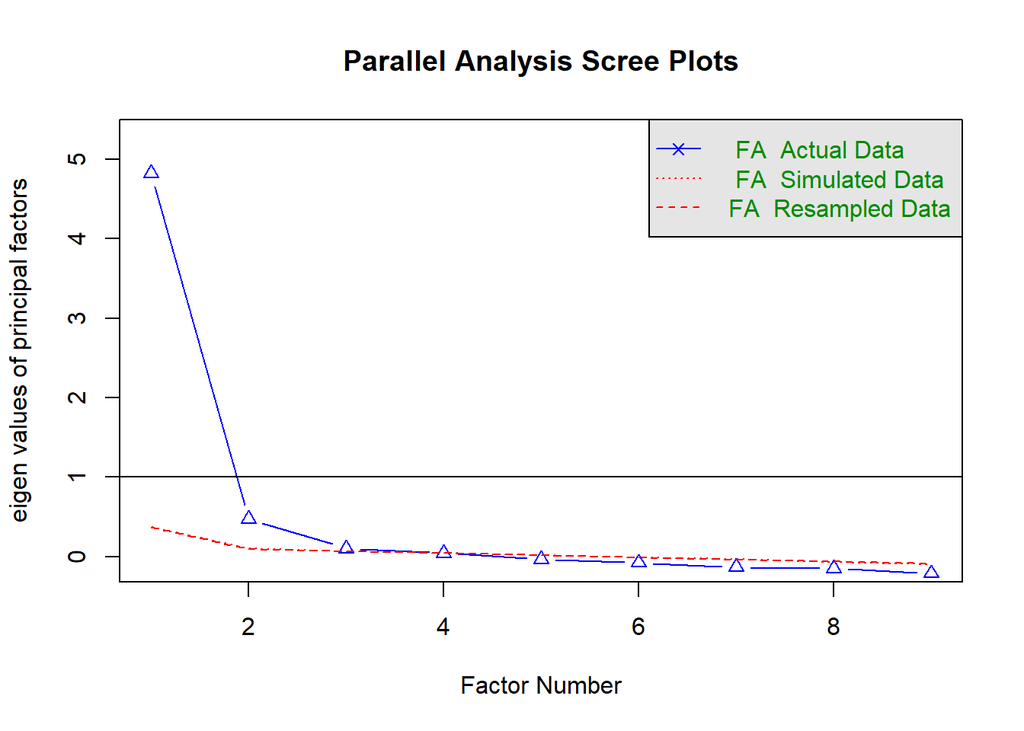

```
## Parallel analysis suggests that the number of factors =  3  and the number of components =  NA
```

```r
factan <- fa(d_tmp, fm = "ml", nfactors = model$nfact, rotate = "promax")
print(factan, sort = TRUE, cut = 0.3)
```

```
## Factor Analysis using method =  ml
## Call: fa(r = d_tmp, nfactors = model$nfact, rotate = "promax", fm = "ml")
## Standardized loadings (pattern matrix) based upon correlation matrix
##               item   ML2   ML1   ML3   h2   u2 com
## t1_pri_con_03    3  0.84             0.65 0.35 1.1
## t1_pri_con_02    2  0.83             0.62 0.38 1.1
## t1_pri_con_05    5  0.57             0.52 0.48 1.3
## t1_pri_con_04    4  0.53             0.65 0.35 1.5
## t1_pri_con_01    1  0.36             0.45 0.55 2.0
## t1_pri_con_09    9        0.89       0.74 0.26 1.1
## t1_pri_con_08    8        0.86       0.73 0.27 1.1
## t1_pri_con_07    7        0.60  0.37 0.70 0.30 1.7
## t1_pri_con_06    6              0.72 0.73 0.27 1.1
##
##                        ML2  ML1  ML3
## SS loadings           2.40 2.31 1.08
## Proportion Var        0.27 0.26 0.12
## Cumulative Var        0.27 0.52 0.64
## Proportion Explained  0.41 0.40 0.19
## Cumulative Proportion 0.41 0.81 1.00
##
##  With factor correlations of
##      ML2  ML1  ML3
## ML2 1.00 0.69 0.71
## ML1 0.69 1.00 0.71
## ML3 0.71 0.71 1.00
##
## Mean item complexity =  1.3
## Test of the hypothesis that 3 factors are sufficient.
##
## The degrees of freedom for the null model are  36  and the objective function was  5.18 with Chi Square of  7246
## The degrees of freedom for the model are 12  and the objective function was  0.06
##
## The root mean square of the residuals (RMSR) is  0.02
## The df corrected root mean square of the residuals is  0.03
##
## The harmonic number of observations is  1392 with the empirical chi square  29.4  with prob <  0.0035
## The total number of observations was  1403  with Likelihood Chi Square =  89.1  with prob <  7.3e-14
##
## Tucker Lewis Index of factoring reliability =  0.968
## RMSEA index =  0.068  and the 90 % confidence intervals are  0.055 0.081
## BIC =  2.16
## Fit based upon off diagonal values = 1
## Measures of factor score adequacy
##                                                    ML2  ML1  ML3
## Correlation of (regression) scores with factors   0.93 0.95 0.90
## Multiple R square of scores with factors          0.87 0.90 0.81
## Minimum correlation of possible factor scores     0.75 0.79 0.61
```

### CFA

#### First-Order Model Unconstrained

```r
model <- '
# create factors
t1_pri_con_f =~ 1*t1_pri_con_01 + t1_pri_con_02 + t1_pri_con_03 + t1_pri_con_04 + t1_pri_con_05 + t1_pri_con_06 + t1_pri_con_07 + t1_pri_con_08 + t1_pri_con_09
t2_pri_con_f =~ 1*t2_pri_con_01 + t2_pri_con_02 + t2_pri_con_03 + t2_pri_con_04 + t2_pri_con_05 + t2_pri_con_06 + t2_pri_con_07 + t2_pri_con_08 + t2_pri_con_09
t3_pri_con_f =~ 1*t3_pri_con_01 + t3_pri_con_02 + t3_pri_con_03 + t3_pri_con_04 + t3_pri_con_05 + t3_pri_con_06 + t3_pri_con_07 + t3_pri_con_08 + t3_pri_con_09

# error covariances
t3_pri_con_01 ~~ t2_pri_con_01 + t1_pri_con_01
t3_pri_con_02 ~~ t2_pri_con_02 + t1_pri_con_02
t3_pri_con_03 ~~ t2_pri_con_03 + t1_pri_con_03
t3_pri_con_04 ~~ t2_pri_con_04 + t1_pri_con_04
t3_pri_con_05 ~~ t2_pri_con_05 + t1_pri_con_05
t3_pri_con_06 ~~ t2_pri_con_06 + t1_pri_con_06
t3_pri_con_07 ~~ t2_pri_con_07 + t1_pri_con_07
t3_pri_con_08 ~~ t2_pri_con_08 + t1_pri_con_08
t3_pri_con_09 ~~ t2_pri_con_09 + t1_pri_con_09
t2_pri_con_01 ~~ t1_pri_con_01
t2_pri_con_02 ~~ t1_pri_con_02
t2_pri_con_03 ~~ t1_pri_con_03
t2_pri_con_04 ~~ t1_pri_con_04
t2_pri_con_05 ~~ t1_pri_con_05
t2_pri_con_06 ~~ t1_pri_con_06
t2_pri_con_07 ~~ t1_pri_con_07
t2_pri_con_08 ~~ t1_pri_con_08
t2_pri_con_09 ~~ t1_pri_con_09

# factor covariances
t1_pri_con_f ~~ t2_pri_con_f + t3_pri_con_f
t2_pri_con_f ~~ t3_pri_con_f
'
no <- no + 1
assign(paste("fit", name, no, sep = "_"), cfa(model, d_wide, missing = "ML"))
summary(get(paste("fit", name, no, sep = "_")), standardized = TRUE, fit.measures = TRUE)
```

```
## lavaan 0.6-5 ended normally after 101 iterations
##
##   Estimator                                         ML
##   Optimization method                           NLMINB
##   Number of free parameters                        111
##
##   Number of observations                          1403
##   Number of missing patterns                        29
##
## Model Test User Model:
##
##   Test statistic                              2726.529
##   Degrees of freedom                               294
##   P-value (Chi-square)                           0.000
##
## Model Test Baseline Model:
##
##   Test statistic                             29137.955
##   Degrees of freedom                               351
##   P-value                                        0.000
##
## User Model versus Baseline Model:
##
##   Comparative Fit Index (CFI)                    0.915
##   Tucker-Lewis Index (TLI)                       0.899
##
## Loglikelihood and Information Criteria:
##
##   Loglikelihood user model (H0)             -45195.456
##   Loglikelihood unrestricted model (H1)     -43832.192
##
##   Akaike (AIC)                               90612.913
##   Bayesian (BIC)                             91195.260
##   Sample-size adjusted Bayesian (BIC)        90842.654
##
## Root Mean Square Error of Approximation:
##
##   RMSEA                                          0.077
##   90 Percent confidence interval - lower         0.074
##   90 Percent confidence interval - upper         0.079
```

[output cut: 157 more lines]

```
##    .t2_pri_con_07     0.546    0.024   22.352    0.000    0.546    0.349
##    .t2_pri_con_08     0.518    0.023   22.481    0.000    0.518    0.371
##    .t2_pri_con_09     0.424    0.019   22.382    0.000    0.424    0.359
##    .t3_pri_con_01     0.576    0.024   24.115    0.000    0.576    0.487
##    .t3_pri_con_02     0.509    0.021   23.879    0.000    0.509    0.482
##    .t3_pri_con_03     0.768    0.032   24.130    0.000    0.768    0.527
##    .t3_pri_con_04     0.359    0.017   21.645    0.000    0.359    0.318
##    .t3_pri_con_05     0.923    0.038   24.596    0.000    0.923    0.553
##    .t3_pri_con_06     0.528    0.023   23.357    0.000    0.528    0.397
##    .t3_pri_con_07     0.565    0.025   22.376    0.000    0.565    0.365
##    .t3_pri_con_08     0.486    0.022   22.211    0.000    0.486    0.359
##    .t3_pri_con_09     0.429    0.019   22.629    0.000    0.429    0.368
##     t1_pri_con_f      0.530    0.038   14.041    0.000    1.000    1.000
##     t2_pri_con_f      0.524    0.036   14.435    0.000    1.000    1.000
##     t3_pri_con_f      0.607    0.040   15.297    0.000    1.000    1.000
```

```r
reliability(get(paste("fit", name, no, sep = "_")))
```

```
##        t1_pri_con_f t2_pri_con_f t3_pri_con_f total
## alpha         0.911        0.918        0.921 0.961
## omega         0.911        0.918        0.921 0.943
## omega2        0.911        0.918        0.921 0.943
## omega3        0.902        0.915        0.920 0.938
## avevar        0.533        0.558        0.567 0.553
```

#### First-Order Model Constrained

```r
model <- '
# create factors
t1_pri_con_f =~ 1*t1_pri_con_01 + b2*t1_pri_con_02 + b3*t1_pri_con_03 + b4*t1_pri_con_04 + b5*t1_pri_con_05 + b6*t1_pri_con_06 + b7*t1_pri_con_07 + b8*t1_pri_con_08 + b9*t1_pri_con_09
t2_pri_con_f =~ 1*t2_pri_con_01 + b2*t2_pri_con_02 + b3*t2_pri_con_03 + b4*t2_pri_con_04 + b5*t2_pri_con_05 + b6*t2_pri_con_06 + b7*t2_pri_con_07 + b8*t2_pri_con_08 + b9*t2_pri_con_09
t3_pri_con_f =~ 1*t3_pri_con_01 + b2*t3_pri_con_02 + b3*t3_pri_con_03 + b4*t3_pri_con_04 + b5*t3_pri_con_05 + b6*t3_pri_con_06 + b7*t3_pri_con_07 + b8*t3_pri_con_08 + b9*t3_pri_con_09

# error covariances
t3_pri_con_01 ~~ t2_pri_con_01 + t1_pri_con_01
t3_pri_con_02 ~~ t2_pri_con_02 + t1_pri_con_02
t3_pri_con_03 ~~ t2_pri_con_03 + t1_pri_con_03
t3_pri_con_04 ~~ t2_pri_con_04 + t1_pri_con_04
t3_pri_con_05 ~~ t2_pri_con_05 + t1_pri_con_05
t3_pri_con_06 ~~ t2_pri_con_06 + t1_pri_con_06
t3_pri_con_07 ~~ t2_pri_con_07 + t1_pri_con_07
t3_pri_con_08 ~~ t2_pri_con_08 + t1_pri_con_08
t3_pri_con_09 ~~ t2_pri_con_09 + t1_pri_con_09
t2_pri_con_01 ~~ t1_pri_con_01
t2_pri_con_02 ~~ t1_pri_con_02
t2_pri_con_03 ~~ t1_pri_con_03
t2_pri_con_04 ~~ t1_pri_con_04
t2_pri_con_05 ~~ t1_pri_con_05
t2_pri_con_06 ~~ t1_pri_con_06
t2_pri_con_07 ~~ t1_pri_con_07
t2_pri_con_08 ~~ t1_pri_con_08
t2_pri_con_09 ~~ t1_pri_con_09

# factor covariances
t1_pri_con_f ~~ t2_pri_con_f + t3_pri_con_f
t2_pri_con_f ~~ t3_pri_con_f
'
no <- no + 1
assign(paste("fit", name, no, sep = "_"), cfa(model, d_wide, missing = "ML"))
summary(get(paste("fit", name, no, sep = "_")), standardized = TRUE, fit.measures = TRUE)
```

```
## lavaan 0.6-5 ended normally after 91 iterations
##
##   Estimator                                         ML
##   Optimization method                           NLMINB
##   Number of free parameters                        111
##   Number of equality constraints                    16
##   Row rank of the constraints matrix                16
##
##   Number of observations                          1403
##   Number of missing patterns                        29
##
## Model Test User Model:
##
##   Test statistic                              2742.286
##   Degrees of freedom                               310
##   P-value (Chi-square)                           0.000
##
## Model Test Baseline Model:
##
##   Test statistic                             29137.955
##   Degrees of freedom                               351
##   P-value                                        0.000
##
## User Model versus Baseline Model:
##
##   Comparative Fit Index (CFI)                    0.916
##   Tucker-Lewis Index (TLI)                       0.904
##
## Loglikelihood and Information Criteria:
##
##   Loglikelihood user model (H0)             -45203.335
##   Loglikelihood unrestricted model (H1)     -43832.192
##
##   Akaike (AIC)                               90596.670
##   Bayesian (BIC)                             91095.075
##   Sample-size adjusted Bayesian (BIC)        90793.295
##
## Root Mean Square Error of Approximation:
##
##   RMSEA                                          0.075
```

[output cut: 159 more lines]

```
##    .t2_pri_con_07     0.550    0.024   22.548    0.000    0.550    0.356
##    .t2_pri_con_08     0.522    0.023   22.707    0.000    0.522    0.378
##    .t2_pri_con_09     0.430    0.019   22.703    0.000    0.430    0.373
##    .t3_pri_con_01     0.583    0.024   24.323    0.000    0.583    0.506
##    .t3_pri_con_02     0.516    0.021   24.116    0.000    0.516    0.506
##    .t3_pri_con_03     0.772    0.032   24.254    0.000    0.772    0.531
##    .t3_pri_con_04     0.361    0.016   21.902    0.000    0.361    0.318
##    .t3_pri_con_05     0.923    0.038   24.588    0.000    0.923    0.545
##    .t3_pri_con_06     0.525    0.022   23.386    0.000    0.525    0.391
##    .t3_pri_con_07     0.559    0.025   22.459    0.000    0.559    0.355
##    .t3_pri_con_08     0.481    0.022   22.322    0.000    0.481    0.354
##    .t3_pri_con_09     0.427    0.019   22.773    0.000    0.427    0.367
##     t1_pri_con_f      0.536    0.030   17.573    0.000    1.000    1.000
##     t2_pri_con_f      0.558    0.031   17.728    0.000    1.000    1.000
##     t3_pri_con_f      0.569    0.032   17.672    0.000    1.000    1.000
```

#### Second-Order Model Unconstrained

In what follows, we analyze a second-order solution of privacy concerns. Here, we distinguish between horizontal privacy concerns (items 4, 5, 6) and vertical privacy concerns (items 7, 8, 9). The resulting model fits the data better than the unidimensional one.

```r
model <- '
# create factors
t1_pri_con_f =~ 1*t1_pri_con_f1 + t1_pri_con_f2
t2_pri_con_f =~ 1*t2_pri_con_f1 + t2_pri_con_f2
t3_pri_con_f =~ 1*t3_pri_con_f1 + t3_pri_con_f2
t1_pri_con_f1 =~ 1*t1_pri_con_04 + t1_pri_con_05 + t1_pri_con_06
t1_pri_con_f2 =~ 1*t1_pri_con_07 + t1_pri_con_08 + t1_pri_con_09
t2_pri_con_f1 =~ 1*t2_pri_con_04 + t2_pri_con_05 + t2_pri_con_06
t2_pri_con_f2 =~ 1*t2_pri_con_07 + t2_pri_con_08 + t2_pri_con_09
t3_pri_con_f1 =~ 1*t3_pri_con_04 + t3_pri_con_05 + t3_pri_con_06
t3_pri_con_f2 =~ 1*t3_pri_con_07 + t3_pri_con_08 + t3_pri_con_09

# error covariances
t3_pri_con_04 ~~ t2_pri_con_04 + t1_pri_con_04
t3_pri_con_05 ~~ t2_pri_con_05 + t1_pri_con_05
t3_pri_con_06 ~~ t2_pri_con_06 + t1_pri_con_06
t3_pri_con_07 ~~ t2_pri_con_07 + t1_pri_con_07
t3_pri_con_08 ~~ t2_pri_con_08 + t1_pri_con_08
t3_pri_con_09 ~~ t2_pri_con_09 + t1_pri_con_09
t2_pri_con_04 ~~ t1_pri_con_04
t2_pri_con_05 ~~ t1_pri_con_05
t2_pri_con_06 ~~ t1_pri_con_06
t2_pri_con_07 ~~ t1_pri_con_07
t2_pri_con_08 ~~ t1_pri_con_08
t2_pri_con_09 ~~ t1_pri_con_09

# factor covariances
t1_pri_con_f ~~ t2_pri_con_f + t3_pri_con_f
t2_pri_con_f ~~ t3_pri_con_f
'
no <- no + 1
assign(paste("fit", name, no, sep = "_"), cfa(model, d_wide, missing = "ML"))
summary(get(paste("fit", name, no, sep = "_")), standardized = TRUE, fit.measures = TRUE)
```

```
## lavaan 0.6-5 ended normally after 83 iterations
##
##   Estimator                                         ML
##   Optimization method                           NLMINB
##   Number of free parameters                         81
##
##   Number of observations                          1403
##   Number of missing patterns                        26
##
## Model Test User Model:
##
##   Test statistic                               657.682
##   Degrees of freedom                               108
##   P-value (Chi-square)                           0.000
##
## Model Test Baseline Model:
##
##   Test statistic                             18770.022
##   Degrees of freedom                               153
##   P-value                                        0.000
##
## User Model versus Baseline Model:
##
##   Comparative Fit Index (CFI)                    0.970
##   Tucker-Lewis Index (TLI)                       0.958
##
## Loglikelihood and Information Criteria:
##
##   Loglikelihood user model (H0)             -30261.591
##   Loglikelihood unrestricted model (H1)     -29932.750
##
##   Akaike (AIC)                               60685.182
##   Bayesian (BIC)                             61110.138
##   Sample-size adjusted Bayesian (BIC)        60852.831
##
## Root Mean Square Error of Approximation:
##
##   RMSEA                                          0.060
##   90 Percent confidence interval - lower         0.056
##   90 Percent confidence interval - upper         0.065
```

[output cut: 136 more lines]

```
##    .t3_pri_con_04     0.418    0.021   20.354    0.000    0.418    0.375
##    .t3_pri_con_05     0.956    0.041   23.557    0.000    0.956    0.568
##    .t3_pri_con_06     0.492    0.024   20.489    0.000    0.492    0.370
##    .t3_pri_con_07     0.444    0.022   19.740    0.000    0.444    0.292
##    .t3_pri_con_08     0.333    0.018   18.288    0.000    0.333    0.247
##    .t3_pri_con_09     0.357    0.018   20.263    0.000    0.357    0.307
##     t1_pri_con_f      0.641    0.043   15.025    0.000    1.000    1.000
##     t2_pri_con_f      0.652    0.041   15.720    0.000    1.000    1.000
##     t3_pri_con_f      0.683    0.042   16.106    0.000    1.000    1.000
##    .t1_pri_con_f1     0.081    0.015    5.266    0.000    0.112    0.112
##    .t1_pri_con_f2     0.099    0.021    4.818    0.000    0.095    0.095
##    .t2_pri_con_f1     0.052    0.014    3.831    0.000    0.074    0.074
##    .t2_pri_con_f2     0.094    0.019    5.012    0.000    0.087    0.087
##    .t3_pri_con_f1     0.015    0.013    1.199    0.230    0.022    0.022
##    .t3_pri_con_f2     0.101    0.018    5.558    0.000    0.094    0.094
```

#### Second-Order Model Constrained

```r
model <- '
# create factors
t1_pri_con_f =~ 1*t1_pri_con_f1 + a2*t1_pri_con_f2
t2_pri_con_f =~ 1*t2_pri_con_f1 + a2*t2_pri_con_f2
t3_pri_con_f =~ 1*t3_pri_con_f1 + a2*t3_pri_con_f2
t1_pri_con_f1 =~ 1*t1_pri_con_04 + b2*t1_pri_con_05 + b3*t1_pri_con_06
t1_pri_con_f2 =~ 1*t1_pri_con_07 + c2*t1_pri_con_08 + c3*t1_pri_con_09
t2_pri_con_f1 =~ 1*t2_pri_con_04 + b2*t2_pri_con_05 + b3*t2_pri_con_06
t2_pri_con_f2 =~ 1*t2_pri_con_07 + c2*t2_pri_con_08 + c3*t2_pri_con_09
t3_pri_con_f1 =~ 1*t3_pri_con_04 + b2*t3_pri_con_05 + b3*t3_pri_con_06
t3_pri_con_f2 =~ 1*t3_pri_con_07 + c2*t3_pri_con_08 + c3*t3_pri_con_09

# error covariances
t3_pri_con_04 ~~ t2_pri_con_04 + t1_pri_con_04
t3_pri_con_05 ~~ t2_pri_con_05 + t1_pri_con_05
t3_pri_con_06 ~~ t2_pri_con_06 + t1_pri_con_06
t3_pri_con_07 ~~ t2_pri_con_07 + t1_pri_con_07
t3_pri_con_08 ~~ t2_pri_con_08 + t1_pri_con_08
t3_pri_con_09 ~~ t2_pri_con_09 + t1_pri_con_09
t2_pri_con_04 ~~ t1_pri_con_04
t2_pri_con_05 ~~ t1_pri_con_05
t2_pri_con_06 ~~ t1_pri_con_06
t2_pri_con_07 ~~ t1_pri_con_07
t2_pri_con_08 ~~ t1_pri_con_08
t2_pri_con_09 ~~ t1_pri_con_09

# factor covariances
t1_pri_con_f ~~ t2_pri_con_f + t3_pri_con_f
t2_pri_con_f ~~ t3_pri_con_f
'
no <- no + 1
assign(paste("fit", name, no, sep = "_"), cfa(model, d_wide, missing = "ML"))
summary(get(paste("fit", name, no, sep = "_")), standardized = TRUE, fit.measures = TRUE)
```

```
## lavaan 0.6-5 ended normally after 86 iterations
##
##   Estimator                                         ML
##   Optimization method                           NLMINB
##   Number of free parameters                         81
##   Number of equality constraints                    10
##   Row rank of the constraints matrix                10
##
##   Number of observations                          1403
##   Number of missing patterns                        26
##
## Model Test User Model:
##
##   Test statistic                               661.175
##   Degrees of freedom                               118
##   P-value (Chi-square)                           0.000
##
## Model Test Baseline Model:
##
##   Test statistic                             18770.022
##   Degrees of freedom                               153
##   P-value                                        0.000
##
## User Model versus Baseline Model:
##
##   Comparative Fit Index (CFI)                    0.971
##   Tucker-Lewis Index (TLI)                       0.962
##
## Loglikelihood and Information Criteria:
##
##   Loglikelihood user model (H0)             -30263.337
##   Loglikelihood unrestricted model (H1)     -29932.750
##
##   Akaike (AIC)                               60668.675
##   Bayesian (BIC)                             61041.167
##   Sample-size adjusted Bayesian (BIC)        60815.626
##
## Root Mean Square Error of Approximation:
##
##   RMSEA                                          0.057
```

[output cut: 138 more lines]

```
##    .t3_pri_con_04     0.419    0.020   20.670    0.000    0.419    0.376
##    .t3_pri_con_05     0.955    0.040   23.579    0.000    0.955    0.567
##    .t3_pri_con_06     0.493    0.024   20.717    0.000    0.493    0.375
##    .t3_pri_con_07     0.443    0.022   20.042    0.000    0.443    0.289
##    .t3_pri_con_08     0.333    0.018   18.506    0.000    0.333    0.245
##    .t3_pri_con_09     0.358    0.017   20.632    0.000    0.358    0.308
##     t1_pri_con_f      0.633    0.035   18.237    0.000    1.000    1.000
##     t2_pri_con_f      0.667    0.036   18.585    0.000    1.000    1.000
##     t3_pri_con_f      0.675    0.036   18.769    0.000    1.000    1.000
##    .t1_pri_con_f1     0.081    0.014    5.626    0.000    0.113    0.113
##    .t1_pri_con_f2     0.097    0.019    5.195    0.000    0.094    0.094
##    .t2_pri_con_f1     0.048    0.013    3.735    0.000    0.067    0.067
##    .t2_pri_con_f2     0.100    0.018    5.713    0.000    0.093    0.093
##    .t3_pri_con_f1     0.019    0.012    1.569    0.117    0.027    0.027
##    .t3_pri_con_f2     0.097    0.017    5.669    0.000    0.089    0.089
```

### Reliability

```r
reliabilityL2(get(paste("fit", name, no, sep = "_")), paste("t1", name, "f", sep = "_"))
```

```
##        omegaL1        omegaL2 partialOmegaL1
##          0.852          0.946          0.896
```

```r
reliabilityL2(get(paste("fit", name, no, sep = "_")), paste("t2", name, "f", sep = "_"))
```

```
##        omegaL1        omegaL2 partialOmegaL1
##          0.870          0.956          0.905
```

```r
reliabilityL2(get(paste("fit", name, no, sep = "_")), paste("t3", name, "f", sep = "_"))
```

```
##        omegaL1        omegaL2 partialOmegaL1
##          0.880          0.966          0.906
```

### Longitudinal Invariance

```r
(anova(get(paste("fit", name, no - 1, sep = "_")), get(paste("fit", name, no, sep = "_"))))
```

|  | Df | AIC | BIC | Chisq | Chisq diff | Df diff | Pr(>Chisq) |
| --- | --- | --- | --- | --- | --- | --- | --- |
| get(paste("fit", name, no - 1, sep = "_")) | 108 | 60685 | 61110 | 658 | NA | NA | NA |
| get(paste("fit", name, no, sep = "_")) | 118 | 60669 | 61041 | 661 | 3.49 | 10 | 0.967 |

## Attitude Toward Online Sharing of Personal Information

### EFA

```r
no <- 0
name <- "inf_sha_att"
d_tmp <- select(d_wide, contains(paste0("t1_", name)), -contains("_m"))
model <- fa.parallel(d_tmp, fa = "fa", fm = "ml")
```

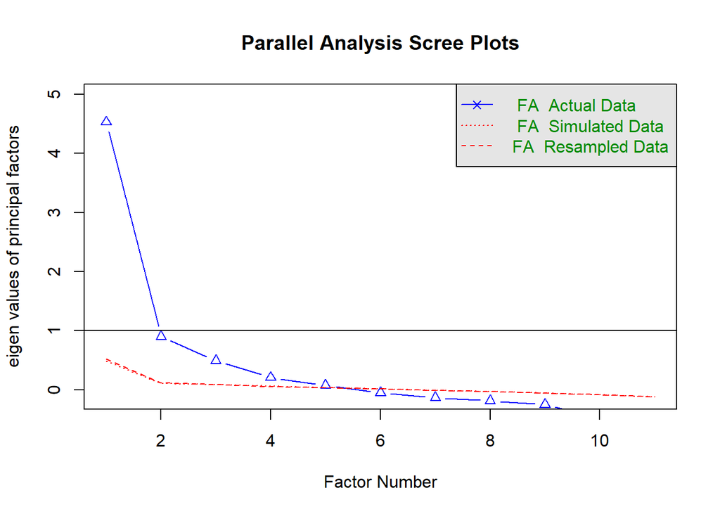

```
## Parallel analysis suggests that the number of factors =  5  and the number of components =  NA
```

```r
factan <- fa(d_tmp, fm = "ml", nfactors = model$nfact, rotate = "promax")
print(factan, sort = TRUE, cut = 0.3)
```

```
## Factor Analysis using method =  ml
## Call: fa(r = d_tmp, nfactors = model$nfact, rotate = "promax", fm = "ml")
##
##  Warning: A Heywood case was detected.
## Standardized loadings (pattern matrix) based upon correlation matrix
##                   item   ML2   ML3   ML4   ML1   ML5   h2     u2 com
## t1_inf_sha_att_06    6  1.11                         0.97 0.0292 1.0
## t1_inf_sha_att_05    5  0.71              0.33       0.81 0.1887 1.4
## t1_inf_sha_att_08    8  0.55                         0.47 0.5302 1.5
## t1_inf_sha_att_10   10        0.98                   0.91 0.0857 1.0
## t1_inf_sha_att_11   11        0.92                   0.82 0.1798 1.0
## t1_inf_sha_att_09    9        0.46                   0.24 0.7576 1.2
## t1_inf_sha_att_02    2              1.00             0.92 0.0834 1.0
## t1_inf_sha_att_01    1              0.55             0.35 0.6464 1.0
## t1_inf_sha_att_04    4                    0.92       0.99 0.0099 1.0
## t1_inf_sha_att_03    3  0.39              0.54       0.77 0.2265 1.8
## t1_inf_sha_att_07    7                          0.99 0.95 0.0486 1.0
##
##                        ML2  ML3  ML4  ML1  ML5
## SS loadings           2.38 2.00 1.27 1.56 1.01
## Proportion Var        0.22 0.18 0.12 0.14 0.09
## Cumulative Var        0.22 0.40 0.51 0.65 0.75
## Proportion Explained  0.29 0.24 0.15 0.19 0.12
## Cumulative Proportion 0.29 0.53 0.69 0.88 1.00
##
##  With factor correlations of
##      ML2  ML3  ML4  ML1  ML5
## ML2 1.00 0.37 0.36 0.66 0.65
## ML3 0.37 1.00 0.21 0.43 0.45
## ML4 0.36 0.21 1.00 0.25 0.36
## ML1 0.66 0.43 0.25 1.00 0.51
## ML5 0.65 0.45 0.36 0.51 1.00
##
## Mean item complexity =  1.2
## Test of the hypothesis that 5 factors are sufficient.
##
## The degrees of freedom for the null model are  55  and the objective function was  7.01 with Chi Square of  9797
## The degrees of freedom for the model are 10  and the objective function was  0.02
##
## The root mean square of the residuals (RMSR) is  0.01
## The df corrected root mean square of the residuals is  0.02
##
## The harmonic number of observations is  1395 with the empirical chi square  10.3  with prob <  0.41
## The total number of observations was  1403  with Likelihood Chi Square =  27.6  with prob <  0.0021
##
## Tucker Lewis Index of factoring reliability =  0.99
## RMSEA index =  0.036  and the 90 % confidence intervals are  0.02 0.052
## BIC =  -44.8
## Fit based upon off diagonal values = 1
## Measures of factor score adequacy
##                                                    ML2  ML3  ML4  ML1  ML5
## Correlation of (regression) scores with factors   0.99 0.97 0.96 0.99 0.98
## Multiple R square of scores with factors          0.98 0.94 0.93 0.99 0.95
## Minimum correlation of possible factor scores     0.96 0.89 0.85 0.98 0.91
```

### CFA

#### First-Order Model Unconstrained

```r
model <- '
# create factors
t1_pri_con_f =~ 1*t1_pri_con_01 + t1_pri_con_02 + t1_pri_con_03 + t1_pri_con_04 + t1_pri_con_05 + t1_pri_con_06 + t1_pri_con_07 + t1_pri_con_08 + t1_pri_con_09
t2_pri_con_f =~ 1*t2_pri_con_01 + t2_pri_con_02 + t2_pri_con_03 + t2_pri_con_04 + t2_pri_con_05 + t2_pri_con_06 + t2_pri_con_07 + t2_pri_con_08 + t2_pri_con_09
t3_pri_con_f =~ 1*t3_pri_con_01 + t3_pri_con_02 + t3_pri_con_03 + t3_pri_con_04 + t3_pri_con_05 + t3_pri_con_06 + t3_pri_con_07 + t3_pri_con_08 + t3_pri_con_09

# error covariances
t3_pri_con_01 ~~ t2_pri_con_01 + t1_pri_con_01
t3_pri_con_02 ~~ t2_pri_con_02 + t1_pri_con_02
t3_pri_con_03 ~~ t2_pri_con_03 + t1_pri_con_03
t3_pri_con_04 ~~ t2_pri_con_04 + t1_pri_con_04
t3_pri_con_05 ~~ t2_pri_con_05 + t1_pri_con_05
t3_pri_con_06 ~~ t2_pri_con_06 + t1_pri_con_06
t3_pri_con_07 ~~ t2_pri_con_07 + t1_pri_con_07
t3_pri_con_08 ~~ t2_pri_con_08 + t1_pri_con_08
t3_pri_con_09 ~~ t2_pri_con_09 + t1_pri_con_09
t2_pri_con_01 ~~ t1_pri_con_01
t2_pri_con_02 ~~ t1_pri_con_02
t2_pri_con_03 ~~ t1_pri_con_03
t2_pri_con_04 ~~ t1_pri_con_04
t2_pri_con_05 ~~ t1_pri_con_05
t2_pri_con_06 ~~ t1_pri_con_06
t2_pri_con_07 ~~ t1_pri_con_07
t2_pri_con_08 ~~ t1_pri_con_08
t2_pri_con_09 ~~ t1_pri_con_09

# factor covariances
t1_pri_con_f ~~ t2_pri_con_f + t3_pri_con_f
t2_pri_con_f ~~ t3_pri_con_f
'
no <- no + 1
assign(paste("fit", name, no, sep = "_"), cfa(model, d_wide, missing = "ML"))
summary(get(paste("fit", name, no, sep = "_")), standardized = TRUE, fit.measures = TRUE)
```

```
## lavaan 0.6-5 ended normally after 101 iterations
##
##   Estimator                                         ML
##   Optimization method                           NLMINB
##   Number of free parameters                        111
##
##   Number of observations                          1403
##   Number of missing patterns                        29
##
## Model Test User Model:
##
##   Test statistic                              2726.529
##   Degrees of freedom                               294
##   P-value (Chi-square)                           0.000
##
## Model Test Baseline Model:
##
##   Test statistic                             29137.955
##   Degrees of freedom                               351
##   P-value                                        0.000
##
## User Model versus Baseline Model:
##
##   Comparative Fit Index (CFI)                    0.915
##   Tucker-Lewis Index (TLI)                       0.899
##
## Loglikelihood and Information Criteria:
##
##   Loglikelihood user model (H0)             -45195.456
##   Loglikelihood unrestricted model (H1)     -43832.192
##
##   Akaike (AIC)                               90612.913
##   Bayesian (BIC)                             91195.260
##   Sample-size adjusted Bayesian (BIC)        90842.654
##
## Root Mean Square Error of Approximation:
##
##   RMSEA                                          0.077
##   90 Percent confidence interval - lower         0.074
##   90 Percent confidence interval - upper         0.079
```

[output cut: 157 more lines]

```
##    .t2_pri_con_07     0.546    0.024   22.352    0.000    0.546    0.349
##    .t2_pri_con_08     0.518    0.023   22.481    0.000    0.518    0.371
##    .t2_pri_con_09     0.424    0.019   22.382    0.000    0.424    0.359
##    .t3_pri_con_01     0.576    0.024   24.115    0.000    0.576    0.487
##    .t3_pri_con_02     0.509    0.021   23.879    0.000    0.509    0.482
##    .t3_pri_con_03     0.768    0.032   24.130    0.000    0.768    0.527
##    .t3_pri_con_04     0.359    0.017   21.645    0.000    0.359    0.318
##    .t3_pri_con_05     0.923    0.038   24.596    0.000    0.923    0.553
##    .t3_pri_con_06     0.528    0.023   23.357    0.000    0.528    0.397
##    .t3_pri_con_07     0.565    0.025   22.376    0.000    0.565    0.365
##    .t3_pri_con_08     0.486    0.022   22.211    0.000    0.486    0.359
##    .t3_pri_con_09     0.429    0.019   22.629    0.000    0.429    0.368
##     t1_pri_con_f      0.530    0.038   14.041    0.000    1.000    1.000
##     t2_pri_con_f      0.524    0.036   14.435    0.000    1.000    1.000
##     t3_pri_con_f      0.607    0.040   15.297    0.000    1.000    1.000
```

#### First-Order Model Constrained

```r
model <- '
# create factors
t1_pri_con_f =~ 1*t1_pri_con_01 + a2*t1_pri_con_02 + a3*t1_pri_con_03 + a4*t1_pri_con_04 + a5*t1_pri_con_05 + a6*t1_pri_con_06 + a7*t1_pri_con_07 + a8*t1_pri_con_08 + a9*t1_pri_con_09
t2_pri_con_f =~ 1*t2_pri_con_01 + a2*t2_pri_con_02 + a3*t2_pri_con_03 + a4*t2_pri_con_04 + a5*t2_pri_con_05 + a6*t2_pri_con_06 + a7*t2_pri_con_07 + a8*t2_pri_con_08 + a9*t2_pri_con_09
t3_pri_con_f =~ 1*t3_pri_con_01 + a2*t3_pri_con_02 + a3*t3_pri_con_03 + a4*t3_pri_con_04 + a5*t3_pri_con_05 + a6*t3_pri_con_06 + a7*t3_pri_con_07 + a8*t3_pri_con_08 + a9*t3_pri_con_09

# error covariances
t3_pri_con_01 ~~ t2_pri_con_01 + t1_pri_con_01
t3_pri_con_02 ~~ t2_pri_con_02 + t1_pri_con_02
t3_pri_con_03 ~~ t2_pri_con_03 + t1_pri_con_03
t3_pri_con_04 ~~ t2_pri_con_04 + t1_pri_con_04
t3_pri_con_05 ~~ t2_pri_con_05 + t1_pri_con_05
t3_pri_con_06 ~~ t2_pri_con_06 + t1_pri_con_06
t3_pri_con_07 ~~ t2_pri_con_07 + t1_pri_con_07
t3_pri_con_08 ~~ t2_pri_con_08 + t1_pri_con_08
t3_pri_con_09 ~~ t2_pri_con_09 + t1_pri_con_09
t2_pri_con_01 ~~ t1_pri_con_01
t2_pri_con_02 ~~ t1_pri_con_02
t2_pri_con_03 ~~ t1_pri_con_03
t2_pri_con_04 ~~ t1_pri_con_04
t2_pri_con_05 ~~ t1_pri_con_05
t2_pri_con_06 ~~ t1_pri_con_06
t2_pri_con_07 ~~ t1_pri_con_07
t2_pri_con_08 ~~ t1_pri_con_08
t2_pri_con_09 ~~ t1_pri_con_09

# factor covariances
t1_pri_con_f ~~ t2_pri_con_f + t3_pri_con_f
t2_pri_con_f ~~ t3_pri_con_f
'
no <- no + 1
assign(paste("fit", name, no, sep = "_"), cfa(model, d_wide, missing = "ML"))
summary(get(paste("fit", name, no, sep = "_")), standardized = TRUE, fit.measures = TRUE)
```

```
## lavaan 0.6-5 ended normally after 91 iterations
##
##   Estimator                                         ML
##   Optimization method                           NLMINB
##   Number of free parameters                        111
##   Number of equality constraints                    16
##   Row rank of the constraints matrix                16
##
##   Number of observations                          1403
##   Number of missing patterns                        29
##
## Model Test User Model:
##
##   Test statistic                              2742.286
##   Degrees of freedom                               310
##   P-value (Chi-square)                           0.000
##
## Model Test Baseline Model:
##
##   Test statistic                             29137.955
##   Degrees of freedom                               351
##   P-value                                        0.000
##
## User Model versus Baseline Model:
##
##   Comparative Fit Index (CFI)                    0.916
##   Tucker-Lewis Index (TLI)                       0.904
##
## Loglikelihood and Information Criteria:
##
##   Loglikelihood user model (H0)             -45203.335
##   Loglikelihood unrestricted model (H1)     -43832.192
##
##   Akaike (AIC)                               90596.670
##   Bayesian (BIC)                             91095.075
##   Sample-size adjusted Bayesian (BIC)        90793.295
##
## Root Mean Square Error of Approximation:
##
##   RMSEA                                          0.075
```

[output cut: 159 more lines]

```
##    .t2_pri_con_07     0.550    0.024   22.548    0.000    0.550    0.356
##    .t2_pri_con_08     0.522    0.023   22.707    0.000    0.522    0.378
##    .t2_pri_con_09     0.430    0.019   22.703    0.000    0.430    0.373
##    .t3_pri_con_01     0.583    0.024   24.323    0.000    0.583    0.506
##    .t3_pri_con_02     0.516    0.021   24.116    0.000    0.516    0.506
##    .t3_pri_con_03     0.772    0.032   24.254    0.000    0.772    0.531
##    .t3_pri_con_04     0.361    0.016   21.902    0.000    0.361    0.318
##    .t3_pri_con_05     0.923    0.038   24.588    0.000    0.923    0.545
##    .t3_pri_con_06     0.525    0.022   23.386    0.000    0.525    0.391
##    .t3_pri_con_07     0.559    0.025   22.459    0.000    0.559    0.355
##    .t3_pri_con_08     0.481    0.022   22.322    0.000    0.481    0.354
##    .t3_pri_con_09     0.427    0.019   22.773    0.000    0.427    0.367
##     t1_pri_con_f      0.536    0.030   17.573    0.000    1.000    1.000
##     t2_pri_con_f      0.558    0.031   17.728    0.000    1.000    1.000
##     t3_pri_con_f      0.569    0.032   17.672    0.000    1.000    1.000
```

#### Second-Order Model Unconstrained

We again run models in which we build sub-dimensions referring to the empirical EFA results and theoretical considerations. Resulting model fits the data better than unidimensional one.

```r
model <- '
# create factors
t1_inf_sha_att_f =~ 1*t1_inf_sha_att_f1 + t1_inf_sha_att_f2 + t1_inf_sha_att_f3 + t1_inf_sha_att_f4 + t1_inf_sha_att_f5
t2_inf_sha_att_f =~ 1*t2_inf_sha_att_f1 + t2_inf_sha_att_f2 + t2_inf_sha_att_f3 + t2_inf_sha_att_f4 + t2_inf_sha_att_f5
t3_inf_sha_att_f =~ 1*t3_inf_sha_att_f1 + t3_inf_sha_att_f2 + t3_inf_sha_att_f3 + t3_inf_sha_att_f4 + t3_inf_sha_att_f5
t1_inf_sha_att_f1 =~ 1*t1_inf_sha_att_01 + t1_inf_sha_att_02
t1_inf_sha_att_f2 =~ 1*t1_inf_sha_att_03 + t1_inf_sha_att_04
t1_inf_sha_att_f3 =~ 1*t1_inf_sha_att_05 + t1_inf_sha_att_06
t1_inf_sha_att_f4 =~ 1*t1_inf_sha_att_07 + t1_inf_sha_att_08
t1_inf_sha_att_f5 =~ 1*t1_inf_sha_att_10 + t1_inf_sha_att_11
t2_inf_sha_att_f1 =~ 1*t2_inf_sha_att_01 + t2_inf_sha_att_02
t2_inf_sha_att_f2 =~ 1*t2_inf_sha_att_03 + t2_inf_sha_att_04
t2_inf_sha_att_f3 =~ 1*t2_inf_sha_att_05 + t2_inf_sha_att_06
t2_inf_sha_att_f4 =~ 1*t2_inf_sha_att_07 + t2_inf_sha_att_08
t2_inf_sha_att_f5 =~ 1*t2_inf_sha_att_10 + t2_inf_sha_att_11
t3_inf_sha_att_f1 =~ 1*t3_inf_sha_att_01 + t3_inf_sha_att_02
t3_inf_sha_att_f2 =~ 1*t3_inf_sha_att_03 + t3_inf_sha_att_04
t3_inf_sha_att_f3 =~ 1*t3_inf_sha_att_05 + t3_inf_sha_att_06
t3_inf_sha_att_f4 =~ 1*t3_inf_sha_att_07 + t3_inf_sha_att_08
t3_inf_sha_att_f5 =~ 1*t3_inf_sha_att_10 + t3_inf_sha_att_11

# factor covariance
t1_inf_sha_att_f ~~ t2_inf_sha_att_f + t3_inf_sha_att_f
t2_inf_sha_att_f ~~ t3_inf_sha_att_f

# item error covariance
t1_inf_sha_att_01 ~~ t2_inf_sha_att_01 + t3_inf_sha_att_01
t2_inf_sha_att_01 ~~ t3_inf_sha_att_01
t1_inf_sha_att_02 ~~ t2_inf_sha_att_02 + t3_inf_sha_att_02
t2_inf_sha_att_02 ~~ t3_inf_sha_att_02
t1_inf_sha_att_03 ~~ t2_inf_sha_att_03 + t3_inf_sha_att_03
t2_inf_sha_att_03 ~~ t3_inf_sha_att_03
t1_inf_sha_att_04 ~~ t2_inf_sha_att_04 + t3_inf_sha_att_04
t2_inf_sha_att_04 ~~ t3_inf_sha_att_04
t1_inf_sha_att_05 ~~ t2_inf_sha_att_05 + t3_inf_sha_att_05
t2_inf_sha_att_05 ~~ t3_inf_sha_att_05
t1_inf_sha_att_06 ~~ t2_inf_sha_att_06 + t3_inf_sha_att_06
t2_inf_sha_att_06 ~~ t3_inf_sha_att_06
t1_inf_sha_att_07 ~~ t2_inf_sha_att_07 + t3_inf_sha_att_07
t2_inf_sha_att_07 ~~ t3_inf_sha_att_07
t1_inf_sha_att_08 ~~ t2_inf_sha_att_08 + t3_inf_sha_att_08
t2_inf_sha_att_08 ~~ t3_inf_sha_att_08
t1_inf_sha_att_10 ~~ t2_inf_sha_att_10 + t3_inf_sha_att_10
t2_inf_sha_att_10 ~~ t3_inf_sha_att_10
t1_inf_sha_att_11 ~~ t2_inf_sha_att_11 + t3_inf_sha_att_11
t2_inf_sha_att_11 ~~ t3_inf_sha_att_11
'
no <- no + 1
assign(paste("fit", name, no, sep = "_"), cfa(model, d_wide, missing = "ML"))
summary(get(paste("fit", name, no, sep = "_")), standardized = TRUE, fit.measures = TRUE)
```

```
## lavaan 0.6-5 ended normally after 183 iterations
##
##   Estimator                                         ML
##   Optimization method                           NLMINB
##   Number of free parameters                        138
##
##   Number of observations                          1403
##   Number of missing patterns                        43
##
## Model Test User Model:
##
##   Test statistic                              2673.738
##   Degrees of freedom                               357
##   P-value (Chi-square)                           0.000
##
## Model Test Baseline Model:
##
##   Test statistic                             34051.217
##   Degrees of freedom                               435
##   P-value                                        0.000
##
## User Model versus Baseline Model:
##
##   Comparative Fit Index (CFI)                    0.931
##   Tucker-Lewis Index (TLI)                       0.916
##
## Loglikelihood and Information Criteria:
##
##   Loglikelihood user model (H0)             -47028.014
##   Loglikelihood unrestricted model (H1)     -45691.145
##
##   Akaike (AIC)                               94332.028
##   Bayesian (BIC)                             95056.027
##   Sample-size adjusted Bayesian (BIC)        94617.652
##
## Root Mean Square Error of Approximation:
##
##   RMSEA                                          0.068
##   90 Percent confidence interval - lower         0.066
##   90 Percent confidence interval - upper         0.070
```

[output cut: 222 more lines]

```
##    .t1_nf_sh_tt_f1    0.511    0.064    7.962    0.000    0.842    0.842
##    .t1_nf_sh_tt_f2    0.100    0.015    6.739    0.000    0.096    0.096
##    .t1_nf_sh_tt_f3    0.130    0.015    8.721    0.000    0.127    0.127
##    .t1_nf_sh_tt_f4    0.158    0.021    7.662    0.000    0.235    0.235
##    .t1_nf_sh_tt_f5    0.769    0.043   17.844    0.000    0.788    0.788
##    .t2_nf_sh_tt_f1    0.441    0.056    7.932    0.000    0.808    0.808
##    .t2_nf_sh_tt_f2    0.080    0.013    6.130    0.000    0.081    0.081
##    .t2_nf_sh_tt_f3    0.103    0.014    7.475    0.000    0.101    0.101
##    .t2_nf_sh_tt_f4    0.110    0.019    5.889    0.000    0.181    0.181
##    .t2_nf_sh_tt_f5    0.737    0.039   18.807    0.000    0.770    0.770
##    .t3_nf_sh_tt_f1    0.444    0.054    8.242    0.000    0.801    0.801
##    .t3_nf_sh_tt_f2    0.134    0.015    8.649    0.000    0.134    0.134
##    .t3_nf_sh_tt_f3    0.147    0.016    9.452    0.000    0.154    0.154
##    .t3_nf_sh_tt_f4    0.125    0.019    6.681    0.000    0.203    0.203
##    .t3_nf_sh_tt_f5    0.727    0.039   18.732    0.000    0.737    0.737
```

#### Second-Order Model at All Waves Constrained

```r
model <- '
# create factors
t1_inf_sha_att_f =~ 1*t1_inf_sha_att_f1 + o2*t1_inf_sha_att_f2 + o3*t1_inf_sha_att_f3 + o4*t1_inf_sha_att_f4 + o5*t1_inf_sha_att_f5
t2_inf_sha_att_f =~ 1*t2_inf_sha_att_f1 + o2*t2_inf_sha_att_f2 + o3*t2_inf_sha_att_f3 + o4*t2_inf_sha_att_f4 + o5*t2_inf_sha_att_f5
t3_inf_sha_att_f =~ 1*t3_inf_sha_att_f1 + o2*t3_inf_sha_att_f2 + o3*t3_inf_sha_att_f3 + o4*t3_inf_sha_att_f4 + o5*t3_inf_sha_att_f5
t1_inf_sha_att_f1 =~ 1*t1_inf_sha_att_01 + j2*t1_inf_sha_att_02
t1_inf_sha_att_f2 =~ 1*t1_inf_sha_att_03 + k2*t1_inf_sha_att_04
t1_inf_sha_att_f3 =~ 1*t1_inf_sha_att_05 + l2*t1_inf_sha_att_06
t1_inf_sha_att_f4 =~ 1*t1_inf_sha_att_07 + m2*t1_inf_sha_att_08
t1_inf_sha_att_f5 =~ 1*t1_inf_sha_att_10 + n2*t1_inf_sha_att_11
t2_inf_sha_att_f1 =~ 1*t2_inf_sha_att_01 + j2*t2_inf_sha_att_02
t2_inf_sha_att_f2 =~ 1*t2_inf_sha_att_03 + k2*t2_inf_sha_att_04
t2_inf_sha_att_f3 =~ 1*t2_inf_sha_att_05 + l2*t2_inf_sha_att_06
t2_inf_sha_att_f4 =~ 1*t2_inf_sha_att_07 + m2*t2_inf_sha_att_08
t2_inf_sha_att_f5 =~ 1*t2_inf_sha_att_10 + n2*t2_inf_sha_att_11
t3_inf_sha_att_f1 =~ 1*t3_inf_sha_att_01 + j2*t3_inf_sha_att_02
t3_inf_sha_att_f2 =~ 1*t3_inf_sha_att_03 + k2*t3_inf_sha_att_04
t3_inf_sha_att_f3 =~ 1*t3_inf_sha_att_05 + l2*t3_inf_sha_att_06
t3_inf_sha_att_f4 =~ 1*t3_inf_sha_att_07 + m2*t3_inf_sha_att_08
t3_inf_sha_att_f5 =~ 1*t3_inf_sha_att_10 + n2*t3_inf_sha_att_11

# factor covariance
t1_inf_sha_att_f ~~ t2_inf_sha_att_f + t3_inf_sha_att_f
t2_inf_sha_att_f ~~ t3_inf_sha_att_f

# item error covariance
t1_inf_sha_att_01 ~~ t2_inf_sha_att_01 + t3_inf_sha_att_01
t2_inf_sha_att_01 ~~ t3_inf_sha_att_01
t1_inf_sha_att_02 ~~ t2_inf_sha_att_02 + t3_inf_sha_att_02
t2_inf_sha_att_02 ~~ t3_inf_sha_att_02
t1_inf_sha_att_03 ~~ t2_inf_sha_att_03 + t3_inf_sha_att_03
t2_inf_sha_att_03 ~~ t3_inf_sha_att_03
t1_inf_sha_att_04 ~~ t2_inf_sha_att_04 + t3_inf_sha_att_04
t2_inf_sha_att_04 ~~ t3_inf_sha_att_04
t1_inf_sha_att_05 ~~ t2_inf_sha_att_05 + t3_inf_sha_att_05
t2_inf_sha_att_05 ~~ t3_inf_sha_att_05
t1_inf_sha_att_06 ~~ t2_inf_sha_att_06 + t3_inf_sha_att_06
t2_inf_sha_att_06 ~~ t3_inf_sha_att_06
t1_inf_sha_att_07 ~~ t2_inf_sha_att_07 + t3_inf_sha_att_07
t2_inf_sha_att_07 ~~ t3_inf_sha_att_07
t1_inf_sha_att_08 ~~ t2_inf_sha_att_08 + t3_inf_sha_att_08
t2_inf_sha_att_08 ~~ t3_inf_sha_att_08
t1_inf_sha_att_10 ~~ t2_inf_sha_att_10 + t3_inf_sha_att_10
t2_inf_sha_att_10 ~~ t3_inf_sha_att_10
t1_inf_sha_att_11 ~~ t2_inf_sha_att_11 + t3_inf_sha_att_11
t2_inf_sha_att_11 ~~ t3_inf_sha_att_11
'
no <- no + 1
assign(paste("fit", name, no, sep = "_"), cfa(model, d_wide, missing = "ML"))
summary(get(paste("fit", name, no, sep = "_")), standardized = TRUE, fit.measures = TRUE)
```

```
## lavaan 0.6-5 ended normally after 146 iterations
##
##   Estimator                                         ML
##   Optimization method                           NLMINB
##   Number of free parameters                        138
##   Number of equality constraints                    18
##   Row rank of the constraints matrix                18
##
##   Number of observations                          1403
##   Number of missing patterns                        43
##
## Model Test User Model:
##
##   Test statistic                              2683.427
##   Degrees of freedom                               375
##   P-value (Chi-square)                           0.000
##
## Model Test Baseline Model:
##
##   Test statistic                             34051.217
##   Degrees of freedom                               435
##   P-value                                        0.000
##
## User Model versus Baseline Model:
##
##   Comparative Fit Index (CFI)                    0.931
##   Tucker-Lewis Index (TLI)                       0.920
##
## Loglikelihood and Information Criteria:
##
##   Loglikelihood user model (H0)             -47032.859
##   Loglikelihood unrestricted model (H1)     -45691.145
##
##   Akaike (AIC)                               94305.718
##   Bayesian (BIC)                             94935.282
##   Sample-size adjusted Bayesian (BIC)        94554.087
##
## Root Mean Square Error of Approximation:
##
##   RMSEA                                          0.066
```

[output cut: 224 more lines]

```
##    .t1_nf_sh_tt_f1    0.502    0.050   10.036    0.000    0.826    0.826
##    .t1_nf_sh_tt_f2    0.100    0.014    7.293    0.000    0.098    0.098
##    .t1_nf_sh_tt_f3    0.131    0.014    9.214    0.000    0.128    0.128
##    .t1_nf_sh_tt_f4    0.158    0.020    7.918    0.000    0.235    0.235
##    .t1_nf_sh_tt_f5    0.761    0.037   20.692    0.000    0.766    0.766
##    .t2_nf_sh_tt_f1    0.445    0.046    9.577    0.000    0.807    0.807
##    .t2_nf_sh_tt_f2    0.080    0.013    6.275    0.000    0.079    0.079
##    .t2_nf_sh_tt_f3    0.106    0.013    8.100    0.000    0.106    0.106
##    .t2_nf_sh_tt_f4    0.111    0.019    5.994    0.000    0.177    0.177
##    .t2_nf_sh_tt_f5    0.753    0.036   20.917    0.000    0.763    0.763
##    .t3_nf_sh_tt_f1    0.447    0.046    9.745    0.000    0.819    0.819
##    .t3_nf_sh_tt_f2    0.133    0.014    9.181    0.000    0.134    0.134
##    .t3_nf_sh_tt_f3    0.143    0.015    9.645    0.000    0.147    0.147
##    .t3_nf_sh_tt_f4    0.124    0.018    6.981    0.000    0.206    0.206
##    .t3_nf_sh_tt_f5    0.720    0.035   20.713    0.000    0.768    0.768
```

### Reliability

```r
reliabilityL2(get(paste("fit", name, no, sep = "_")), paste("t1", name, "f", sep = "_"))
```

```
##        omegaL1        omegaL2 partialOmegaL1
##          0.817          0.877          0.924
```

```r
reliabilityL2(get(paste("fit", name, no, sep = "_")), paste("t2", name, "f", sep = "_"))
```

```
##        omegaL1        omegaL2 partialOmegaL1
##          0.824          0.888          0.920
```

```r
reliabilityL2(get(paste("fit", name, no, sep = "_")), paste("t3", name, "f", sep = "_"))
```

```
##        omegaL1        omegaL2 partialOmegaL1
##          0.812          0.875          0.920
```

### Longitudinal Invariance

```r
(anova(get(paste("fit", name, no - 1, sep = "_")), get(paste("fit", name, no, sep = "_"))))
```

|  | Df | AIC | BIC | Chisq | Chisq diff | Df diff | Pr(>Chisq) |
| --- | --- | --- | --- | --- | --- | --- | --- |
| get(paste("fit", name, no - 1, sep = "_")) | 357 | 94332 | 95056 | 2674 | NA | NA | NA |
| get(paste("fit", name, no, sep = "_")) | 375 | 94306 | 94935 | 2683 | 9.69 | 18 | 0.942 |

## Online Sharing of Personal Information

### EFA

```r
no <- 0
name <- "inf_sha_beh"
d_tmp <- select(d_wide, contains(paste0("t1_", name)), -contains("_m"))
model <- fa.parallel(d_tmp, fa = "fa", fm = "ml")
```

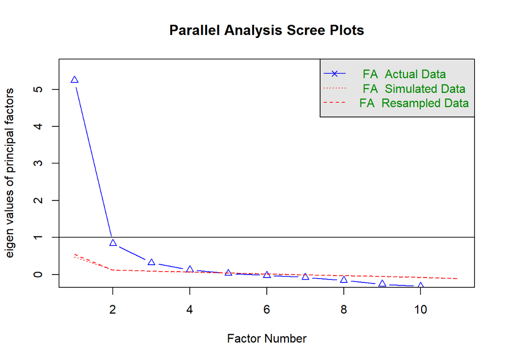

```
## Parallel analysis suggests that the number of factors =  4  and the number of components =  NA
```

```r
factan <- fa(d_tmp, fm = "ml", nfactors = model$nfact, rotate = "promax")
print(factan, sort = TRUE, cut = 0.3)
```

```
## Factor Analysis using method =  ml
## Call: fa(r = d_tmp, nfactors = model$nfact, rotate = "promax", fm = "ml")
##
##  Warning: A Heywood case was detected.
## Standardized loadings (pattern matrix) based upon correlation matrix
##                   item   ML1   ML3   ML4   ML2   h2     u2 com
## t1_inf_sha_beh_04    4  1.02                   0.95 0.0483 1.0
## t1_inf_sha_beh_03    3  1.00                   0.92 0.0833 1.0
## t1_inf_sha_beh_07    7  0.81                   0.67 0.3286 1.0
## t1_inf_sha_beh_05    5  0.77              0.30 0.88 0.1248 1.3
## t1_inf_sha_beh_06    6  0.62              0.60 0.99 0.0069 2.0
## t1_inf_sha_beh_08    8  0.42              0.31 0.49 0.5083 2.0
## t1_inf_sha_beh_11   11        0.96             0.84 0.1566 1.0
## t1_inf_sha_beh_10   10        0.87             0.75 0.2488 1.0
## t1_inf_sha_beh_09    9        0.47             0.31 0.6948 1.3
## t1_inf_sha_beh_02    2              0.79       0.56 0.4439 1.1
## t1_inf_sha_beh_01    1              0.42       0.26 0.7421 1.3
##
##                        ML1  ML3  ML4  ML2
## SS loadings           4.09 1.91 0.77 0.85
## Proportion Var        0.37 0.17 0.07 0.08
## Cumulative Var        0.37 0.55 0.62 0.69
## Proportion Explained  0.54 0.25 0.10 0.11
## Cumulative Proportion 0.54 0.79 0.89 1.00
##
##  With factor correlations of
##      ML1  ML3  ML4  ML2
## ML1 1.00 0.52 0.41 0.43
## ML3 0.52 1.00 0.41 0.16
## ML4 0.41 0.41 1.00 0.33
## ML2 0.43 0.16 0.33 1.00
##
## Mean item complexity =  1.3
## Test of the hypothesis that 4 factors are sufficient.
##
## The degrees of freedom for the null model are  55  and the objective function was  8.67 with Chi Square of  12111
## The degrees of freedom for the model are 17  and the objective function was  0.09
##
## The root mean square of the residuals (RMSR) is  0.01
## The df corrected root mean square of the residuals is  0.03
##
## The harmonic number of observations is  1397 with the empirical chi square  30.3  with prob <  0.024
## The total number of observations was  1403  with Likelihood Chi Square =  123  with prob <  4e-18
##
## Tucker Lewis Index of factoring reliability =  0.971
## RMSEA index =  0.067  and the 90 % confidence intervals are  0.056 0.078
## BIC =  -0.11
## Fit based upon off diagonal values = 1
## Measures of factor score adequacy
##                                                    ML1  ML3  ML4  ML2
## Correlation of (regression) scores with factors   0.99 0.95 0.82 0.98
## Multiple R square of scores with factors          0.98 0.90 0.67 0.96
## Minimum correlation of possible factor scores     0.96 0.81 0.34 0.92
```

### CFA

#### First-Order Model Unconstrained

First-order model shows poor fit. Needs to be adapted (see second order model).

```r
model <- '
# create factors
t1_inf_sha_beh_f =~ 1*t1_inf_sha_beh_01 + t1_inf_sha_beh_02 + t1_inf_sha_beh_03 + t1_inf_sha_beh_04 + t1_inf_sha_beh_05 + t1_inf_sha_beh_06 + t1_inf_sha_beh_07 + t1_inf_sha_beh_08 + t1_inf_sha_beh_09 + t1_inf_sha_beh_10 + t1_inf_sha_beh_11
t2_inf_sha_beh_f =~ 1*t2_inf_sha_beh_01 + t2_inf_sha_beh_02 + t2_inf_sha_beh_03 + t2_inf_sha_beh_04 + t2_inf_sha_beh_05 + t2_inf_sha_beh_06 + t2_inf_sha_beh_07 + t2_inf_sha_beh_08 + t2_inf_sha_beh_09 + t2_inf_sha_beh_10 + t2_inf_sha_beh_11
t3_inf_sha_beh_f =~ 1*t3_inf_sha_beh_01 + t3_inf_sha_beh_02 + t3_inf_sha_beh_03 + t3_inf_sha_beh_04 + t3_inf_sha_beh_05 + t3_inf_sha_beh_06 + t3_inf_sha_beh_07 + t3_inf_sha_beh_08 + t3_inf_sha_beh_09 + t3_inf_sha_beh_10 + t3_inf_sha_beh_11

# factor covariance
t1_inf_sha_beh_f ~~ t2_inf_sha_beh_f + t3_inf_sha_beh_f
t2_inf_sha_beh_f ~~ t3_inf_sha_beh_f

# item error covariance
t1_inf_sha_beh_01 ~~ t2_inf_sha_beh_01 + t3_inf_sha_beh_01
t2_inf_sha_beh_01 ~~ t3_inf_sha_beh_01
t1_inf_sha_beh_02 ~~ t2_inf_sha_beh_02 + t3_inf_sha_beh_02
t2_inf_sha_beh_02 ~~ t3_inf_sha_beh_02
t1_inf_sha_beh_03 ~~ t2_inf_sha_beh_03 + t3_inf_sha_beh_03
t2_inf_sha_beh_03 ~~ t3_inf_sha_beh_03
t1_inf_sha_beh_04 ~~ t2_inf_sha_beh_04 + t3_inf_sha_beh_04
t2_inf_sha_beh_04 ~~ t3_inf_sha_beh_04
t1_inf_sha_beh_05 ~~ t2_inf_sha_beh_05 + t3_inf_sha_beh_05
t2_inf_sha_beh_05 ~~ t3_inf_sha_beh_05
t1_inf_sha_beh_06 ~~ t2_inf_sha_beh_06 + t3_inf_sha_beh_06
t2_inf_sha_beh_06 ~~ t3_inf_sha_beh_06
t1_inf_sha_beh_07 ~~ t2_inf_sha_beh_07 + t3_inf_sha_beh_07
t2_inf_sha_beh_07 ~~ t3_inf_sha_beh_07
t1_inf_sha_beh_08 ~~ t2_inf_sha_beh_08 + t3_inf_sha_beh_08
t2_inf_sha_beh_08 ~~ t3_inf_sha_beh_08
t1_inf_sha_beh_09 ~~ t2_inf_sha_beh_09 + t3_inf_sha_beh_09
t2_inf_sha_beh_09 ~~ t3_inf_sha_beh_09
t1_inf_sha_beh_10 ~~ t2_inf_sha_beh_10 + t3_inf_sha_beh_10
t2_inf_sha_beh_10 ~~ t3_inf_sha_beh_10
t1_inf_sha_beh_11 ~~ t2_inf_sha_beh_11 + t3_inf_sha_beh_11
t2_inf_sha_beh_11 ~~ t3_inf_sha_beh_11
'
no <- no + 1
assign(paste("fit", name, no, sep = "_"), cfa(model, d_wide, missing = "ML"))
summary(get(paste("fit", name, no, sep = "_")), standardized = TRUE, fit.measures = TRUE)
```

```
## lavaan 0.6-5 ended normally after 192 iterations
##
##   Estimator                                         ML
##   Optimization method                           NLMINB
##   Number of free parameters                        135
##
##   Number of observations                          1403
##   Number of missing patterns                        40
##
## Model Test User Model:
##
##   Test statistic                              8471.050
##   Degrees of freedom                               459
##   P-value (Chi-square)                           0.000
##
## Model Test Baseline Model:
##
##   Test statistic                             41941.362
##   Degrees of freedom                               528
##   P-value                                        0.000
##
## User Model versus Baseline Model:
##
##   Comparative Fit Index (CFI)                    0.807
##   Tucker-Lewis Index (TLI)                       0.777
##
## Loglikelihood and Information Criteria:
##
##   Loglikelihood user model (H0)             -43502.943
##   Loglikelihood unrestricted model (H1)     -39267.418
##
##   Akaike (AIC)                               87275.886
##   Bayesian (BIC)                             87984.145
##   Sample-size adjusted Bayesian (BIC)        87555.300
##
## Root Mean Square Error of Approximation:
##
##   RMSEA                                          0.112
##   90 Percent confidence interval - lower         0.109
##   90 Percent confidence interval - upper         0.114
```

[output cut: 176 more lines]

```
##    .t2_nf_sh_bh_11    0.561    0.021   26.183    0.000    0.561    0.836
##    .t3_nf_sh_bh_01    1.048    0.040   26.367    0.000    1.048    0.921
##    .t3_nf_sh_bh_02    0.252    0.010   26.425    0.000    0.252    0.964
##    .t3_nf_sh_bh_03    0.089    0.006   15.523    0.000    0.089    0.091
##    .t3_nf_sh_bh_04    0.123    0.007   17.878    0.000    0.123    0.120
##    .t3_nf_sh_bh_05    0.156    0.008   20.002    0.000    0.156    0.179
##    .t3_nf_sh_bh_06    0.254    0.011   22.708    0.000    0.254    0.301
##    .t3_nf_sh_bh_07    0.425    0.017   24.845    0.000    0.425    0.407
##    .t3_nf_sh_bh_08    0.512    0.020   25.550    0.000    0.512    0.613
##    .t3_nf_sh_bh_09    0.467    0.018   26.339    0.000    0.467    0.946
##    .t3_nf_sh_bh_10    0.594    0.023   26.140    0.000    0.594    0.816
##    .t3_nf_sh_bh_11    0.533    0.020   26.247    0.000    0.533    0.872
##     t1_inf_sh_bh_f    0.100    0.017    5.906    0.000    1.000    1.000
##     t2_inf_sh_bh_f    0.102    0.017    6.137    0.000    1.000    1.000
##     t3_inf_sh_bh_f    0.090    0.016    5.784    0.000    1.000    1.000
```

#### First-Order Model Constrained

```r
model <- '
# create factors
t1_inf_sha_beh_f =~ 1*t1_inf_sha_beh_01 + c2*t1_inf_sha_beh_02 + c3*t1_inf_sha_beh_03 + c4*t1_inf_sha_beh_04 + c5*t1_inf_sha_beh_05 + c6*t1_inf_sha_beh_06 + c7*t1_inf_sha_beh_07 + c8*t1_inf_sha_beh_08 + c9*t1_inf_sha_beh_09 + c10*t1_inf_sha_beh_10 + c11*t1_inf_sha_beh_11
t2_inf_sha_beh_f =~ 1*t2_inf_sha_beh_01 + c2*t2_inf_sha_beh_02 + c3*t2_inf_sha_beh_03 + c4*t2_inf_sha_beh_04 + c5*t2_inf_sha_beh_05 + c6*t2_inf_sha_beh_06 + c7*t2_inf_sha_beh_07 + c8*t2_inf_sha_beh_08 + c9*t2_inf_sha_beh_09 + c10*t2_inf_sha_beh_10 + c11*t2_inf_sha_beh_11
t3_inf_sha_beh_f =~ 1*t3_inf_sha_beh_01 + c2*t3_inf_sha_beh_02 + c3*t3_inf_sha_beh_03 + c4*t3_inf_sha_beh_04 + c5*t3_inf_sha_beh_05 + c6*t3_inf_sha_beh_06 + c7*t3_inf_sha_beh_07 + c8*t3_inf_sha_beh_08 + c9*t3_inf_sha_beh_09 + c10*t3_inf_sha_beh_10 + c11*t3_inf_sha_beh_11

# factor covariance
t1_inf_sha_beh_f ~~ t2_inf_sha_beh_f + t3_inf_sha_beh_f
t2_inf_sha_beh_f ~~ t3_inf_sha_beh_f

# item error covariance
t1_inf_sha_beh_01 ~~ t2_inf_sha_beh_01 + t3_inf_sha_beh_01
t2_inf_sha_beh_01 ~~ t3_inf_sha_beh_01
t1_inf_sha_beh_02 ~~ t2_inf_sha_beh_02 + t3_inf_sha_beh_02
t2_inf_sha_beh_02 ~~ t3_inf_sha_beh_02
t1_inf_sha_beh_03 ~~ t2_inf_sha_beh_03 + t3_inf_sha_beh_03
t2_inf_sha_beh_03 ~~ t3_inf_sha_beh_03
t1_inf_sha_beh_04 ~~ t2_inf_sha_beh_04 + t3_inf_sha_beh_04
t2_inf_sha_beh_04 ~~ t3_inf_sha_beh_04
t1_inf_sha_beh_05 ~~ t2_inf_sha_beh_05 + t3_inf_sha_beh_05
t2_inf_sha_beh_05 ~~ t3_inf_sha_beh_05
t1_inf_sha_beh_06 ~~ t2_inf_sha_beh_06 + t3_inf_sha_beh_06
t2_inf_sha_beh_06 ~~ t3_inf_sha_beh_06
t1_inf_sha_beh_07 ~~ t2_inf_sha_beh_07 + t3_inf_sha_beh_07
t2_inf_sha_beh_07 ~~ t3_inf_sha_beh_07
t1_inf_sha_beh_08 ~~ t2_inf_sha_beh_08 + t3_inf_sha_beh_08
t2_inf_sha_beh_08 ~~ t3_inf_sha_beh_08
t1_inf_sha_beh_09 ~~ t2_inf_sha_beh_09 + t3_inf_sha_beh_09
t2_inf_sha_beh_09 ~~ t3_inf_sha_beh_09
t1_inf_sha_beh_10 ~~ t2_inf_sha_beh_10 + t3_inf_sha_beh_10
t2_inf_sha_beh_10 ~~ t3_inf_sha_beh_10
t1_inf_sha_beh_11 ~~ t2_inf_sha_beh_11 + t3_inf_sha_beh_11
t2_inf_sha_beh_11 ~~ t3_inf_sha_beh_11
'
no <- no + 1
assign(paste("fit", name, no, sep = "_"), cfa(model, d_wide, missing = "ML"))
summary(get(paste("fit", name, no, sep = "_")), standardized = TRUE, fit.measures = TRUE)
```

```
## lavaan 0.6-5 ended normally after 147 iterations
##
##   Estimator                                         ML
##   Optimization method                           NLMINB
##   Number of free parameters                        135
##   Number of equality constraints                    20
##   Row rank of the constraints matrix                20
##
##   Number of observations                          1403
##   Number of missing patterns                        40
##
## Model Test User Model:
##
##   Test statistic                              8485.780
##   Degrees of freedom                               479
##   P-value (Chi-square)                           0.000
##
## Model Test Baseline Model:
##
##   Test statistic                             41941.362
##   Degrees of freedom                               528
##   P-value                                        0.000
##
## User Model versus Baseline Model:
##
##   Comparative Fit Index (CFI)                    0.807
##   Tucker-Lewis Index (TLI)                       0.787
##
## Loglikelihood and Information Criteria:
##
##   Loglikelihood user model (H0)             -43510.308
##   Loglikelihood unrestricted model (H1)     -39267.418
##
##   Akaike (AIC)                               87250.615
##   Bayesian (BIC)                             87853.948
##   Sample-size adjusted Bayesian (BIC)        87488.635
##
## Root Mean Square Error of Approximation:
##
##   RMSEA                                          0.109
```

[output cut: 178 more lines]

```
##    .t2_nf_sh_bh_11    0.563    0.021   26.216    0.000    0.563    0.846
##    .t3_nf_sh_bh_01    1.048    0.040   26.380    0.000    1.048    0.921
##    .t3_nf_sh_bh_02    0.252    0.010   26.426    0.000    0.252    0.967
##    .t3_nf_sh_bh_03    0.089    0.006   15.822    0.000    0.089    0.091
##    .t3_nf_sh_bh_04    0.123    0.007   18.263    0.000    0.123    0.120
##    .t3_nf_sh_bh_05    0.157    0.008   20.520    0.000    0.157    0.183
##    .t3_nf_sh_bh_06    0.255    0.011   22.955    0.000    0.255    0.301
##    .t3_nf_sh_bh_07    0.424    0.017   24.942    0.000    0.424    0.404
##    .t3_nf_sh_bh_08    0.512    0.020   25.612    0.000    0.512    0.611
##    .t3_nf_sh_bh_09    0.467    0.018   26.349    0.000    0.467    0.944
##    .t3_nf_sh_bh_10    0.593    0.023   26.181    0.000    0.593    0.809
##    .t3_nf_sh_bh_11    0.531    0.020   26.267    0.000    0.531    0.849
##     t1_inf_sh_bh_f    0.104    0.012    8.373    0.000    1.000    1.000
##     t2_inf_sh_bh_f    0.098    0.012    8.369    0.000    1.000    1.000
##     t3_inf_sh_bh_f    0.090    0.011    8.371    0.000    1.000    1.000
```

#### Second-Order Model Unconstrained

Second-order model shows much improved fit.

```r
model <- '
# create factors
t1_inf_sha_beh_f =~ 1*t1_inf_sha_beh_f1 + t1_inf_sha_beh_f2 + t1_inf_sha_beh_f3 + t1_inf_sha_beh_f4 + t1_inf_sha_beh_f5
t2_inf_sha_beh_f =~ 1*t2_inf_sha_beh_f1 + t2_inf_sha_beh_f2 + t2_inf_sha_beh_f3 + t2_inf_sha_beh_f4 + t2_inf_sha_beh_f5
t3_inf_sha_beh_f =~ 1*t3_inf_sha_beh_f1 + t3_inf_sha_beh_f2 + t3_inf_sha_beh_f3 + t3_inf_sha_beh_f4 + t3_inf_sha_beh_f5
t1_inf_sha_beh_f1 =~ 1*t1_inf_sha_beh_01 + t1_inf_sha_beh_02
t1_inf_sha_beh_f2 =~ 1*t1_inf_sha_beh_03 + t1_inf_sha_beh_04
t1_inf_sha_beh_f3 =~ 1*t1_inf_sha_beh_05 + t1_inf_sha_beh_06
t1_inf_sha_beh_f4 =~ 1*t1_inf_sha_beh_07 + t1_inf_sha_beh_08
t1_inf_sha_beh_f5 =~ 1*t1_inf_sha_beh_10 + t1_inf_sha_beh_11
t2_inf_sha_beh_f1 =~ 1*t2_inf_sha_beh_01 + t2_inf_sha_beh_02
t2_inf_sha_beh_f2 =~ 1*t2_inf_sha_beh_03 + t2_inf_sha_beh_04
t2_inf_sha_beh_f3 =~ 1*t2_inf_sha_beh_05 + t2_inf_sha_beh_06
t2_inf_sha_beh_f4 =~ 1*t2_inf_sha_beh_07 + t2_inf_sha_beh_08
t2_inf_sha_beh_f5 =~ 1*t2_inf_sha_beh_10 + t2_inf_sha_beh_11
t3_inf_sha_beh_f1 =~ 1*t3_inf_sha_beh_01 + t3_inf_sha_beh_02
t3_inf_sha_beh_f2 =~ 1*t3_inf_sha_beh_03 + t3_inf_sha_beh_04
t3_inf_sha_beh_f3 =~ 1*t3_inf_sha_beh_05 + t3_inf_sha_beh_06
t3_inf_sha_beh_f4 =~ 1*t3_inf_sha_beh_07 + t3_inf_sha_beh_08
t3_inf_sha_beh_f5 =~ 1*t3_inf_sha_beh_10 + t3_inf_sha_beh_11

# factor covariance
t1_inf_sha_beh_f ~~ t2_inf_sha_beh_f + t3_inf_sha_beh_f
t2_inf_sha_beh_f ~~ t3_inf_sha_beh_f

# item error covariance
t1_inf_sha_beh_01 ~~ t2_inf_sha_beh_01 + t3_inf_sha_beh_01
t2_inf_sha_beh_01 ~~ t3_inf_sha_beh_01
t1_inf_sha_beh_02 ~~ t2_inf_sha_beh_02 + t3_inf_sha_beh_02
t2_inf_sha_beh_02 ~~ t3_inf_sha_beh_02
t1_inf_sha_beh_03 ~~ t2_inf_sha_beh_03 + t3_inf_sha_beh_03
t2_inf_sha_beh_03 ~~ t3_inf_sha_beh_03
t1_inf_sha_beh_04 ~~ t2_inf_sha_beh_04 + t3_inf_sha_beh_04
t2_inf_sha_beh_04 ~~ t3_inf_sha_beh_04
t1_inf_sha_beh_05 ~~ t2_inf_sha_beh_05 + t3_inf_sha_beh_05
t2_inf_sha_beh_05 ~~ t3_inf_sha_beh_05
t1_inf_sha_beh_06 ~~ t2_inf_sha_beh_06 + t3_inf_sha_beh_06
t2_inf_sha_beh_06 ~~ t3_inf_sha_beh_06
t1_inf_sha_beh_07 ~~ t2_inf_sha_beh_07 + t3_inf_sha_beh_07
t2_inf_sha_beh_07 ~~ t3_inf_sha_beh_07
t1_inf_sha_beh_08 ~~ t2_inf_sha_beh_08 + t3_inf_sha_beh_08
t2_inf_sha_beh_08 ~~ t3_inf_sha_beh_08
t1_inf_sha_beh_10 ~~ t2_inf_sha_beh_10 + t3_inf_sha_beh_10
t2_inf_sha_beh_10 ~~ t3_inf_sha_beh_10
t1_inf_sha_beh_11 ~~ t2_inf_sha_beh_11 + t3_inf_sha_beh_11
t2_inf_sha_beh_11 ~~ t3_inf_sha_beh_11
'
no <- no + 1
assign(paste("fit", name, no, sep = "_"), cfa(model, d_wide, missing = "ML"))
summary(get(paste("fit", name, no, sep = "_")), standardized = TRUE, fit.measures = TRUE)
```

```
## lavaan 0.6-5 ended normally after 231 iterations
##
##   Estimator                                         ML
##   Optimization method                           NLMINB
##   Number of free parameters                        138
##
##   Number of observations                          1403
##   Number of missing patterns                        38
##
## Model Test User Model:
##
##   Test statistic                              2510.346
##   Degrees of freedom                               357
##   P-value (Chi-square)                           0.000
##
## Model Test Baseline Model:
##
##   Test statistic                             39663.809
##   Degrees of freedom                               435
##   P-value                                        0.000
##
## User Model versus Baseline Model:
##
##   Comparative Fit Index (CFI)                    0.945
##   Tucker-Lewis Index (TLI)                       0.933
##
## Loglikelihood and Information Criteria:
##
##   Loglikelihood user model (H0)             -37156.335
##   Loglikelihood unrestricted model (H1)     -35901.162
##
##   Akaike (AIC)                               74588.669
##   Bayesian (BIC)                             75312.668
##   Sample-size adjusted Bayesian (BIC)        74874.293
##
## Root Mean Square Error of Approximation:
##
##   RMSEA                                          0.066
##   90 Percent confidence interval - lower         0.063
##   90 Percent confidence interval - upper         0.068
```

[output cut: 222 more lines]

```
##    .t1_nf_sh_bh_f1    0.398    0.070    5.707    0.000    0.784    0.784
##    .t1_nf_sh_bh_f2    0.080    0.009    9.037    0.000    0.076    0.076
##    .t1_nf_sh_bh_f3    0.105    0.009   11.092    0.000    0.114    0.114
##    .t1_nf_sh_bh_f4    0.069    0.016    4.421    0.000    0.084    0.084
##    .t1_nf_sh_bh_f5    0.457    0.029   15.986    0.000    0.712    0.712
##    .t2_nf_sh_bh_f1    0.273    0.059    4.673    0.000    0.710    0.710
##    .t2_nf_sh_bh_f2    0.070    0.009    7.583    0.000    0.071    0.071
##    .t2_nf_sh_bh_f3    0.134    0.010   12.782    0.000    0.154    0.154
##    .t2_nf_sh_bh_f4    0.083    0.016    5.251    0.000    0.103    0.103
##    .t2_nf_sh_bh_f5    0.459    0.029   15.984    0.000    0.705    0.705
##    .t3_nf_sh_bh_f1    0.360    0.063    5.697    0.000    0.784    0.784
##    .t3_nf_sh_bh_f2    0.079    0.009    9.168    0.000    0.087    0.087
##    .t3_nf_sh_bh_f3    0.097    0.009   10.421    0.000    0.117    0.117
##    .t3_nf_sh_bh_f4    0.101    0.016    6.127    0.000    0.135    0.135
##    .t3_nf_sh_bh_f5    0.512    0.032   16.139    0.000    0.767    0.767
```

#### Second-Order Model Constrained

```r
model <- '
# create factors
t1_inf_sha_beh_f =~ 1*t1_inf_sha_beh_f1 + o2*t1_inf_sha_beh_f2 + o3*t1_inf_sha_beh_f3 + o4*t1_inf_sha_beh_f4 + o5*t1_inf_sha_beh_f5
t2_inf_sha_beh_f =~ 1*t2_inf_sha_beh_f1 + o2*t2_inf_sha_beh_f2 + o3*t2_inf_sha_beh_f3 + o4*t2_inf_sha_beh_f4 + o5*t2_inf_sha_beh_f5
t3_inf_sha_beh_f =~ 1*t3_inf_sha_beh_f1 + o2*t3_inf_sha_beh_f2 + o3*t3_inf_sha_beh_f3 + o4*t3_inf_sha_beh_f4 + o5*t3_inf_sha_beh_f5
t1_inf_sha_beh_f1 =~ 1*t1_inf_sha_beh_01 + j2*t1_inf_sha_beh_02
t1_inf_sha_beh_f2 =~ 1*t1_inf_sha_beh_03 + k2*t1_inf_sha_beh_04
t1_inf_sha_beh_f3 =~ 1*t1_inf_sha_beh_05 + l2*t1_inf_sha_beh_06
t1_inf_sha_beh_f4 =~ 1*t1_inf_sha_beh_07 + m2*t1_inf_sha_beh_08
t1_inf_sha_beh_f5 =~ 1*t1_inf_sha_beh_10 + n2*t1_inf_sha_beh_11
t2_inf_sha_beh_f1 =~ 1*t2_inf_sha_beh_01 + j2*t2_inf_sha_beh_02
t2_inf_sha_beh_f2 =~ 1*t2_inf_sha_beh_03 + k2*t2_inf_sha_beh_04
t2_inf_sha_beh_f3 =~ 1*t2_inf_sha_beh_05 + l2*t2_inf_sha_beh_06
t2_inf_sha_beh_f4 =~ 1*t2_inf_sha_beh_07 + m2*t2_inf_sha_beh_08
t2_inf_sha_beh_f5 =~ 1*t2_inf_sha_beh_10 + n2*t2_inf_sha_beh_11
t3_inf_sha_beh_f1 =~ 1*t3_inf_sha_beh_01 + j2*t3_inf_sha_beh_02
t3_inf_sha_beh_f2 =~ 1*t3_inf_sha_beh_03 + k2*t3_inf_sha_beh_04
t3_inf_sha_beh_f3 =~ 1*t3_inf_sha_beh_05 + l2*t3_inf_sha_beh_06
t3_inf_sha_beh_f4 =~ 1*t3_inf_sha_beh_07 + m2*t3_inf_sha_beh_08
t3_inf_sha_beh_f5 =~ 1*t3_inf_sha_beh_10 + n2*t3_inf_sha_beh_11

# factor covariance
t1_inf_sha_beh_f ~~ t2_inf_sha_beh_f + t3_inf_sha_beh_f
t2_inf_sha_beh_f ~~ t3_inf_sha_beh_f

# item error covariance
t1_inf_sha_beh_01 ~~ t2_inf_sha_beh_01 + t3_inf_sha_beh_01
t2_inf_sha_beh_01 ~~ t3_inf_sha_beh_01
t1_inf_sha_beh_02 ~~ t2_inf_sha_beh_02 + t3_inf_sha_beh_02
t2_inf_sha_beh_02 ~~ t3_inf_sha_beh_02
t1_inf_sha_beh_03 ~~ t2_inf_sha_beh_03 + t3_inf_sha_beh_03
t2_inf_sha_beh_03 ~~ t3_inf_sha_beh_03
t1_inf_sha_beh_04 ~~ t2_inf_sha_beh_04 + t3_inf_sha_beh_04
t2_inf_sha_beh_04 ~~ t3_inf_sha_beh_04
t1_inf_sha_beh_05 ~~ t2_inf_sha_beh_05 + t3_inf_sha_beh_05
t2_inf_sha_beh_05 ~~ t3_inf_sha_beh_05
t1_inf_sha_beh_06 ~~ t2_inf_sha_beh_06 + t3_inf_sha_beh_06
t2_inf_sha_beh_06 ~~ t3_inf_sha_beh_06
t1_inf_sha_beh_07 ~~ t2_inf_sha_beh_07 + t3_inf_sha_beh_07
t2_inf_sha_beh_07 ~~ t3_inf_sha_beh_07
t1_inf_sha_beh_08 ~~ t2_inf_sha_beh_08 + t3_inf_sha_beh_08
t2_inf_sha_beh_08 ~~ t3_inf_sha_beh_08
t1_inf_sha_beh_10 ~~ t2_inf_sha_beh_10 + t3_inf_sha_beh_10
t2_inf_sha_beh_10 ~~ t3_inf_sha_beh_10
t1_inf_sha_beh_11 ~~ t2_inf_sha_beh_11 + t3_inf_sha_beh_11
t2_inf_sha_beh_11 ~~ t3_inf_sha_beh_11
'
no <- no + 1
assign(paste("fit", name, no, sep = "_"), cfa(model, d_wide, missing = "ML"))
summary(get(paste("fit", name, no, sep = "_")), standardized = TRUE, fit.measures = TRUE)
```

```
## lavaan 0.6-5 ended normally after 182 iterations
##
##   Estimator                                         ML
##   Optimization method                           NLMINB
##   Number of free parameters                        138
##   Number of equality constraints                    18
##   Row rank of the constraints matrix                18
##
##   Number of observations                          1403
##   Number of missing patterns                        38
##
## Model Test User Model:
##
##   Test statistic                              2527.695
##   Degrees of freedom                               375
##   P-value (Chi-square)                           0.000
##
## Model Test Baseline Model:
##
##   Test statistic                             39663.809
##   Degrees of freedom                               435
##   P-value                                        0.000
##
## User Model versus Baseline Model:
##
##   Comparative Fit Index (CFI)                    0.945
##   Tucker-Lewis Index (TLI)                       0.936
##
## Loglikelihood and Information Criteria:
##
##   Loglikelihood user model (H0)             -37165.009
##   Loglikelihood unrestricted model (H1)     -35901.162
##
##   Akaike (AIC)                               74570.018
##   Bayesian (BIC)                             75199.583
##   Sample-size adjusted Bayesian (BIC)        74818.387
##
## Root Mean Square Error of Approximation:
##
##   RMSEA                                          0.064
```

[output cut: 224 more lines]

```
##    .t1_nf_sh_bh_f1    0.449    0.064    6.976    0.000    0.798    0.798
##    .t1_nf_sh_bh_f2    0.080    0.009    9.386    0.000    0.077    0.077
##    .t1_nf_sh_bh_f3    0.106    0.009   11.509    0.000    0.115    0.115
##    .t1_nf_sh_bh_f4    0.067    0.015    4.436    0.000    0.081    0.081
##    .t1_nf_sh_bh_f5    0.491    0.027   18.022    0.000    0.721    0.721
##    .t2_nf_sh_bh_f1    0.238    0.043    5.486    0.000    0.691    0.691
##    .t2_nf_sh_bh_f2    0.071    0.009    8.074    0.000    0.073    0.073
##    .t2_nf_sh_bh_f3    0.133    0.010   12.994    0.000    0.148    0.148
##    .t2_nf_sh_bh_f4    0.087    0.016    5.533    0.000    0.109    0.109
##    .t2_nf_sh_bh_f5    0.455    0.025   18.012    0.000    0.719    0.719
##    .t3_nf_sh_bh_f1    0.370    0.053    6.967    0.000    0.789    0.789
##    .t3_nf_sh_bh_f2    0.078    0.008    9.489    0.000    0.086    0.086
##    .t3_nf_sh_bh_f3    0.097    0.009   11.039    0.000    0.120    0.120
##    .t3_nf_sh_bh_f4    0.100    0.016    6.221    0.000    0.132    0.132
##    .t3_nf_sh_bh_f5    0.485    0.026   18.702    0.000    0.746    0.746
```

### Reliability

```r
reliabilityL2(get(paste("fit", name, no, sep = "_")), paste("t1", name, "f", sep = "_"))
```

```
##        omegaL1        omegaL2 partialOmegaL1
##          0.879          0.913          0.946
```

```r
reliabilityL2(get(paste("fit", name, no, sep = "_")), paste("t2", name, "f", sep = "_"))
```

```
##        omegaL1        omegaL2 partialOmegaL1
##          0.877          0.922          0.940
```

```r
reliabilityL2(get(paste("fit", name, no, sep = "_")), paste("t3", name, "f", sep = "_"))
```

```
##        omegaL1        omegaL2 partialOmegaL1
##          0.868          0.905          0.941
```

### Longitudinal Invariance

```r
(anova(get(paste("fit", name, no - 1, sep = "_")), get(paste("fit", name, no, sep = "_"))))
```

|  | Df | AIC | BIC | Chisq | Chisq diff | Df diff | Pr(>Chisq) |
| --- | --- | --- | --- | --- | --- | --- | --- |
| get(paste("fit", name, no - 1, sep = "_")) | 357 | 74589 | 75313 | 2510 | NA | NA | NA |
| get(paste("fit", name, no, sep = "_")) | 375 | 74570 | 75200 | 2528 | 17.3 | 18 | 0.499 |

## All Measures in one Model

### Second Order

```r
name <- "all_vars"
no <- 0
model <- '
# Privacy Concerns
# create factors
t1_pri_con_f =~ 1*t1_pri_con_f1 + a2*t1_pri_con_f2
t2_pri_con_f =~ 1*t2_pri_con_f1 + a2*t2_pri_con_f2
t3_pri_con_f =~ 1*t3_pri_con_f1 + a2*t3_pri_con_f2
t1_pri_con_f1 =~ 1*t1_pri_con_04 + b2*t1_pri_con_05 + b3*t1_pri_con_06
t1_pri_con_f2 =~ 1*t1_pri_con_07 + c2*t1_pri_con_08 + c3*t1_pri_con_09
t2_pri_con_f1 =~ 1*t2_pri_con_04 + b2*t2_pri_con_05 + b3*t2_pri_con_06
t2_pri_con_f2 =~ 1*t2_pri_con_07 + c2*t2_pri_con_08 + c3*t2_pri_con_09
t3_pri_con_f1 =~ 1*t3_pri_con_04 + b2*t3_pri_con_05 + b3*t3_pri_con_06
t3_pri_con_f2 =~ 1*t3_pri_con_07 + c2*t3_pri_con_08 + c3*t3_pri_con_09

# error covariances
t3_pri_con_04 ~~ t2_pri_con_04 + t1_pri_con_04
t3_pri_con_05 ~~ t2_pri_con_05 + t1_pri_con_05
t3_pri_con_06 ~~ t2_pri_con_06 + t1_pri_con_06
t3_pri_con_07 ~~ t2_pri_con_07 + t1_pri_con_07
t3_pri_con_08 ~~ t2_pri_con_08 + t1_pri_con_08
t3_pri_con_09 ~~ t2_pri_con_09 + t1_pri_con_09
t2_pri_con_04 ~~ t1_pri_con_04
t2_pri_con_05 ~~ t1_pri_con_05
t2_pri_con_06 ~~ t1_pri_con_06
t2_pri_con_07 ~~ t1_pri_con_07
t2_pri_con_08 ~~ t1_pri_con_08
t2_pri_con_09 ~~ t1_pri_con_09

# factor covariances
t1_pri_con_f ~~ t2_pri_con_f + t3_pri_con_f
t2_pri_con_f ~~ t3_pri_con_f

# Information Sharing Attitude
# create factors
t1_inf_sha_att_f =~ 1*t1_inf_sha_att_f1 + d2*t1_inf_sha_att_f2 + d3*t1_inf_sha_att_f3 + d4*t1_inf_sha_att_f4 + d5*t1_inf_sha_att_f5
t2_inf_sha_att_f =~ 1*t2_inf_sha_att_f1 + d2*t2_inf_sha_att_f2 + d3*t2_inf_sha_att_f3 + d4*t2_inf_sha_att_f4 + d5*t2_inf_sha_att_f5
t3_inf_sha_att_f =~ 1*t3_inf_sha_att_f1 + d2*t3_inf_sha_att_f2 + d3*t3_inf_sha_att_f3 + d4*t3_inf_sha_att_f4 + d5*t3_inf_sha_att_f5
t1_inf_sha_att_f1 =~ 1*t1_inf_sha_att_01 + e*t1_inf_sha_att_02
t1_inf_sha_att_f2 =~ 1*t1_inf_sha_att_03 + f*t1_inf_sha_att_04
t1_inf_sha_att_f3 =~ 1*t1_inf_sha_att_05 + g*t1_inf_sha_att_06
t1_inf_sha_att_f4 =~ 1*t1_inf_sha_att_07 + h*t1_inf_sha_att_08
t1_inf_sha_att_f5 =~ 1*t1_inf_sha_att_10 + i*t1_inf_sha_att_11
t2_inf_sha_att_f1 =~ 1*t2_inf_sha_att_01 + e*t2_inf_sha_att_02
t2_inf_sha_att_f2 =~ 1*t2_inf_sha_att_03 + f*t2_inf_sha_att_04
t2_inf_sha_att_f3 =~ 1*t2_inf_sha_att_05 + g*t2_inf_sha_att_06
t2_inf_sha_att_f4 =~ 1*t2_inf_sha_att_07 + h*t2_inf_sha_att_08
t2_inf_sha_att_f5 =~ 1*t2_inf_sha_att_10 + i*t2_inf_sha_att_11
t3_inf_sha_att_f1 =~ 1*t3_inf_sha_att_01 + e*t3_inf_sha_att_02
t3_inf_sha_att_f2 =~ 1*t3_inf_sha_att_03 + f*t3_inf_sha_att_04
t3_inf_sha_att_f3 =~ 1*t3_inf_sha_att_05 + g*t3_inf_sha_att_06
t3_inf_sha_att_f4 =~ 1*t3_inf_sha_att_07 + h*t3_inf_sha_att_08
t3_inf_sha_att_f5 =~ 1*t3_inf_sha_att_10 + i*t3_inf_sha_att_11

# factor covariance
t1_inf_sha_att_f ~~ t2_inf_sha_att_f + t3_inf_sha_att_f
t2_inf_sha_att_f ~~ t3_inf_sha_att_f

# item error covariance
t1_inf_sha_att_01 ~~ t2_inf_sha_att_01 + t3_inf_sha_att_01
t2_inf_sha_att_01 ~~ t3_inf_sha_att_01
t1_inf_sha_att_02 ~~ t2_inf_sha_att_02 + t3_inf_sha_att_02
t2_inf_sha_att_02 ~~ t3_inf_sha_att_02
t1_inf_sha_att_03 ~~ t2_inf_sha_att_03 + t3_inf_sha_att_03
t2_inf_sha_att_03 ~~ t3_inf_sha_att_03
t1_inf_sha_att_04 ~~ t2_inf_sha_att_04 + t3_inf_sha_att_04
t2_inf_sha_att_04 ~~ t3_inf_sha_att_04
t1_inf_sha_att_05 ~~ t2_inf_sha_att_05 + t3_inf_sha_att_05
t2_inf_sha_att_05 ~~ t3_inf_sha_att_05
t1_inf_sha_att_06 ~~ t2_inf_sha_att_06 + t3_inf_sha_att_06
t2_inf_sha_att_06 ~~ t3_inf_sha_att_06
t1_inf_sha_att_07 ~~ t2_inf_sha_att_07 + t3_inf_sha_att_07
t2_inf_sha_att_07 ~~ t3_inf_sha_att_07
t1_inf_sha_att_08 ~~ t2_inf_sha_att_08 + t3_inf_sha_att_08
t2_inf_sha_att_08 ~~ t3_inf_sha_att_08
t1_inf_sha_att_10 ~~ t2_inf_sha_att_10 + t3_inf_sha_att_10
t2_inf_sha_att_10 ~~ t3_inf_sha_att_10
t1_inf_sha_att_11 ~~ t2_inf_sha_att_11 + t3_inf_sha_att_11
t2_inf_sha_att_11 ~~ t3_inf_sha_att_11

# information sharing behavior
# create factors
t1_inf_sha_beh_f =~ 1*t1_inf_sha_beh_f1 + o2*t1_inf_sha_beh_f2 + o3*t1_inf_sha_beh_f3 + o4*t1_inf_sha_beh_f4 + o5*t1_inf_sha_beh_f5
t2_inf_sha_beh_f =~ 1*t2_inf_sha_beh_f1 + o2*t2_inf_sha_beh_f2 + o3*t2_inf_sha_beh_f3 + o4*t2_inf_sha_beh_f4 + o5*t2_inf_sha_beh_f5
t3_inf_sha_beh_f =~ 1*t3_inf_sha_beh_f1 + o2*t3_inf_sha_beh_f2 + o3*t3_inf_sha_beh_f3 + o4*t3_inf_sha_beh_f4 + o5*t3_inf_sha_beh_f5
t1_inf_sha_beh_f1 =~ 1*t1_inf_sha_beh_01 + j2*t1_inf_sha_beh_02
t1_inf_sha_beh_f2 =~ 1*t1_inf_sha_beh_03 + k2*t1_inf_sha_beh_04
t1_inf_sha_beh_f3 =~ 1*t1_inf_sha_beh_05 + l2*t1_inf_sha_beh_06
t1_inf_sha_beh_f4 =~ 1*t1_inf_sha_beh_07 + m2*t1_inf_sha_beh_08
t1_inf_sha_beh_f5 =~ 1*t1_inf_sha_beh_10 + n2*t1_inf_sha_beh_11
t2_inf_sha_beh_f1 =~ 1*t2_inf_sha_beh_01 + j2*t2_inf_sha_beh_02
t2_inf_sha_beh_f2 =~ 1*t2_inf_sha_beh_03 + k2*t2_inf_sha_beh_04
t2_inf_sha_beh_f3 =~ 1*t2_inf_sha_beh_05 + l2*t2_inf_sha_beh_06
t2_inf_sha_beh_f4 =~ 1*t2_inf_sha_beh_07 + m2*t2_inf_sha_beh_08
t2_inf_sha_beh_f5 =~ 1*t2_inf_sha_beh_10 + n2*t2_inf_sha_beh_11
t3_inf_sha_beh_f1 =~ 1*t3_inf_sha_beh_01 + j2*t3_inf_sha_beh_02
t3_inf_sha_beh_f2 =~ 1*t3_inf_sha_beh_03 + k2*t3_inf_sha_beh_04
t3_inf_sha_beh_f3 =~ 1*t3_inf_sha_beh_05 + l2*t3_inf_sha_beh_06
t3_inf_sha_beh_f4 =~ 1*t3_inf_sha_beh_07 + m2*t3_inf_sha_beh_08
t3_inf_sha_beh_f5 =~ 1*t3_inf_sha_beh_10 + n2*t3_inf_sha_beh_11

# factor covariance
t1_inf_sha_beh_f ~~ t2_inf_sha_beh_f + t3_inf_sha_beh_f
t2_inf_sha_beh_f ~~ t3_inf_sha_beh_f

# item error covariance
t1_inf_sha_beh_01 ~~ t2_inf_sha_beh_01 + t3_inf_sha_beh_01
t2_inf_sha_beh_01 ~~ t3_inf_sha_beh_01
t1_inf_sha_beh_02 ~~ t2_inf_sha_beh_02 + t3_inf_sha_beh_02
t2_inf_sha_beh_02 ~~ t3_inf_sha_beh_02
t1_inf_sha_beh_03 ~~ t2_inf_sha_beh_03 + t3_inf_sha_beh_03
t2_inf_sha_beh_03 ~~ t3_inf_sha_beh_03
t1_inf_sha_beh_04 ~~ t2_inf_sha_beh_04 + t3_inf_sha_beh_04
t2_inf_sha_beh_04 ~~ t3_inf_sha_beh_04
t1_inf_sha_beh_05 ~~ t2_inf_sha_beh_05 + t3_inf_sha_beh_05
t2_inf_sha_beh_05 ~~ t3_inf_sha_beh_05
t1_inf_sha_beh_06 ~~ t2_inf_sha_beh_06 + t3_inf_sha_beh_06
t2_inf_sha_beh_06 ~~ t3_inf_sha_beh_06
t1_inf_sha_beh_07 ~~ t2_inf_sha_beh_07 + t3_inf_sha_beh_07
t2_inf_sha_beh_07 ~~ t3_inf_sha_beh_07
t1_inf_sha_beh_08 ~~ t2_inf_sha_beh_08 + t3_inf_sha_beh_08
t2_inf_sha_beh_08 ~~ t3_inf_sha_beh_08
t1_inf_sha_beh_10 ~~ t2_inf_sha_beh_10 + t3_inf_sha_beh_10
t2_inf_sha_beh_10 ~~ t3_inf_sha_beh_10
t1_inf_sha_beh_11 ~~ t2_inf_sha_beh_11 + t3_inf_sha_beh_11
t2_inf_sha_beh_11 ~~ t3_inf_sha_beh_11

## Correlations Attitude and Behavior-Items
t1_inf_sha_beh_01 ~~ t1_inf_sha_att_01
t1_inf_sha_beh_02 ~~ t1_inf_sha_att_02
t1_inf_sha_beh_03 ~~ t1_inf_sha_att_03
t1_inf_sha_beh_04 ~~ t1_inf_sha_att_04
t1_inf_sha_beh_05 ~~ t1_inf_sha_att_05
t1_inf_sha_beh_06 ~~ t1_inf_sha_att_06
t1_inf_sha_beh_07 ~~ t1_inf_sha_att_07
t1_inf_sha_beh_08 ~~ t1_inf_sha_att_08
t1_inf_sha_beh_10 ~~ t1_inf_sha_att_10
t1_inf_sha_beh_11 ~~ t1_inf_sha_att_11
t2_inf_sha_beh_01 ~~ t2_inf_sha_att_01
t2_inf_sha_beh_02 ~~ t2_inf_sha_att_02
t2_inf_sha_beh_03 ~~ t2_inf_sha_att_03
t2_inf_sha_beh_04 ~~ t2_inf_sha_att_04
t2_inf_sha_beh_05 ~~ t2_inf_sha_att_05
t2_inf_sha_beh_06 ~~ t2_inf_sha_att_06
t2_inf_sha_beh_07 ~~ t2_inf_sha_att_07
t2_inf_sha_beh_08 ~~ t2_inf_sha_att_08
t2_inf_sha_beh_10 ~~ t2_inf_sha_att_10
t2_inf_sha_beh_11 ~~ t2_inf_sha_att_11
t3_inf_sha_beh_01 ~~ t3_inf_sha_att_01
t3_inf_sha_beh_02 ~~ t3_inf_sha_att_02
t3_inf_sha_beh_03 ~~ t3_inf_sha_att_03
t3_inf_sha_beh_04 ~~ t3_inf_sha_att_04
t3_inf_sha_beh_05 ~~ t3_inf_sha_att_05
t3_inf_sha_beh_06 ~~ t3_inf_sha_att_06
t3_inf_sha_beh_07 ~~ t3_inf_sha_att_07
t3_inf_sha_beh_08 ~~ t3_inf_sha_att_08
t3_inf_sha_beh_10 ~~ t3_inf_sha_att_10
t3_inf_sha_beh_11 ~~ t3_inf_sha_att_11
'
no <- no + 1
assign(paste("fit", name, no, sep = "_"), cfa(model, d_wide, missing = "ML"))
summary(get(paste("fit", name, no, sep = "_")), standardized = TRUE, fit.measures = TRUE)
```

```
## lavaan 0.6-5 ended normally after 354 iterations
##
##   Estimator                                         ML
##   Optimization method                           NLMINB
##   Number of free parameters                        414
##   Number of equality constraints                    46
##   Row rank of the constraints matrix                46
##
##   Number of observations                          1403
##   Number of missing patterns                       109
##
## Model Test User Model:
##
##   Test statistic                              11028.436
##   Degrees of freedom                               2791
##   P-value (Chi-square)                            0.000
##
## Model Test Baseline Model:
##
##   Test statistic                             99651.877
##   Degrees of freedom                              3003
##   P-value                                        0.000
##
## User Model versus Baseline Model:
##
##   Comparative Fit Index (CFI)                    0.915
##   Tucker-Lewis Index (TLI)                       0.908
##
## Loglikelihood and Information Criteria:
##
##   Loglikelihood user model (H0)            -113455.861
##   Loglikelihood unrestricted model (H1)    -107941.643
##
##   Akaike (AIC)                              227647.721
##   Bayesian (BIC)                            229578.385
##   Sample-size adjusted Bayesian (BIC)       228409.385
##
## Root Mean Square Error of Approximation:
##
##   RMSEA                                          0.046
```

[output cut: 659 more lines]

```
##    .t1_nf_sh_bh_f1    0.398    0.060    6.594    0.000    0.774    0.774
##    .t1_nf_sh_bh_f2    0.080    0.008    9.594    0.000    0.077    0.077
##    .t1_nf_sh_bh_f3    0.103    0.009   11.475    0.000    0.111    0.111
##    .t1_nf_sh_bh_f4    0.050    0.015    3.403    0.001    0.061    0.061
##    .t1_nf_sh_bh_f5    0.484    0.027   18.081    0.000    0.717    0.717
##    .t2_nf_sh_bh_f1    0.209    0.042    5.013    0.000    0.656    0.656
##    .t2_nf_sh_bh_f2    0.074    0.009    8.583    0.000    0.076    0.076
##    .t2_nf_sh_bh_f3    0.129    0.010   12.935    0.000    0.144    0.144
##    .t2_nf_sh_bh_f4    0.068    0.015    4.534    0.000    0.087    0.087
##    .t2_nf_sh_bh_f5    0.451    0.025   18.029    0.000    0.716    0.716
##    .t3_nf_sh_bh_f1    0.306    0.049    6.278    0.000    0.752    0.752
##    .t3_nf_sh_bh_f2    0.082    0.008   10.243    0.000    0.090    0.090
##    .t3_nf_sh_bh_f3    0.091    0.008   10.813    0.000    0.113    0.113
##    .t3_nf_sh_bh_f4    0.080    0.015    5.223    0.000    0.108    0.108
##    .t3_nf_sh_bh_f5    0.480    0.026   18.753    0.000    0.743    0.743
```

### Extract Factor Scores

```r
d_fs <- lavPredict(get(paste("fit", name, no, sep = "_")), type = "ov") %>% as.data.frame() %>% mutate(t1_pri_con_fs = rowMeans(select(.,
    starts_with("t1_pri"))), t2_pri_con_fs = rowMeans(select(., starts_with("t2_pri"))), t3_pri_con_fs = rowMeans(select(.,
    starts_with("t3_pri"))), t1_inf_sha_att_fs = rowMeans(select(., starts_with("t1_inf_sha_att"))), t2_inf_sha_att_fs = rowMeans(select(.,
    starts_with("t2_inf_sha_att"))), t3_inf_sha_att_fs = rowMeans(select(., starts_with("t3_inf_sha_att"))), t1_inf_sha_beh_fs = rowMeans(select(.,
    starts_with("t1_inf_sha_beh"))), t2_inf_sha_beh_fs = rowMeans(select(., starts_with("t2_inf_sha_beh"))), t3_inf_sha_beh_fs = rowMeans(select(.,
    starts_with("t3_inf_sha_beh")))) %>% select(contains("_fs"))
d_wide <- cbind(d_fs, d_wide)
```

# Correlation matrix and distributions

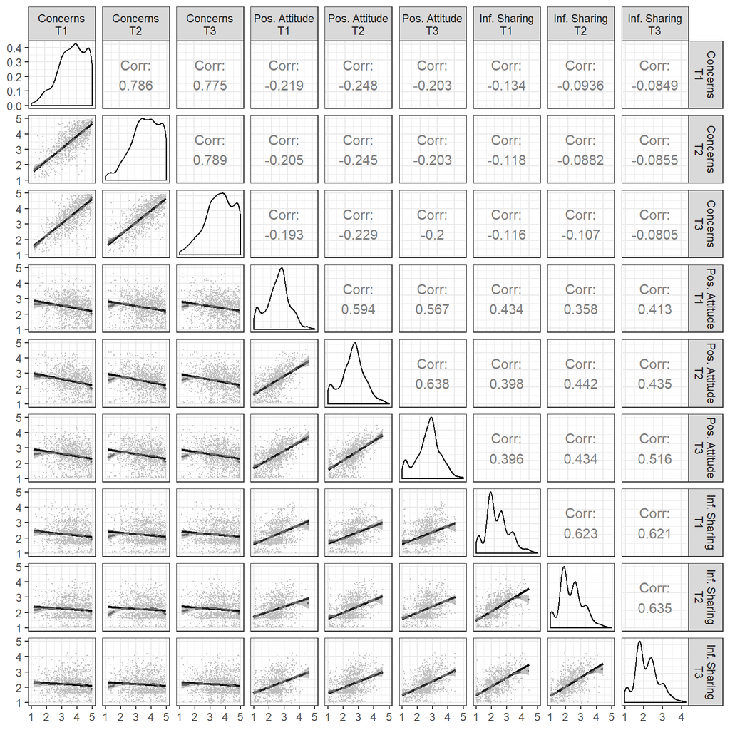

```r
colnames(d_fs) <- c("Concerns\nT1", "Concerns\nT2" , "Concerns\nT3",
                    "Pos. Attitude\nT1", "Pos. Attitude\nT2" , "Pos. Attitude\nT3",
                    "Inf. Sharing\nT1", "Inf. Sharing\nT2" , "Inf. Sharing\nT3")

corr_plot <- ggpairs(d_fs,
                     # upper = list(continuous = wrap(td::cor_matrix, data = d_fs)),
                     lower = list(continuous = wrap(td::scat_plot, coords = c(1, 5, 1, 5)))) +
  theme_bw()
print(corr_plot)
```

# ICCs

Next, we determine the Intraclass Correlation Coefficients (ICC), to determine how much variance in the measures is due to between-person differences versus within-person changes.

```r
fit <- lmer(pri_con_m ~ 1 + (1 | id), filter(d_long, wave < 4))
summary(fit)
```

```
## Linear mixed model fit by REML ['lmerMod']
## Formula: pri_con_m ~ 1 + (1 | id)
##    Data: filter(d_long, wave < 4)
##
## REML criterion at convergence: 13069
##
## Scaled residuals:
##    Min     1Q Median     3Q    Max
## -4.649 -0.448  0.058  0.468  4.840
##
## Random effects:
##  Groups   Name        Variance Std.Dev.
##  id       (Intercept) 0.593    0.770
##  Residual             0.210    0.458
## Number of obs: 6139, groups:  id, 2705
##
## Fixed effects:
##             Estimate Std. Error t value
## (Intercept)   3.6380     0.0161     226
```

```r
(icc_pri_con <- icc(fit))
```

```
## # Intraclass Correlation Coefficient
##
##      Adjusted ICC: 0.739
##   Conditional ICC: 0.739
```

```r
fit <- lmer(inf_sha_att_m ~ 1 + (1 | id), filter(d_long, wave < 4))
summary(fit)
```

```
## Linear mixed model fit by REML ['lmerMod']
## Formula: inf_sha_att_m ~ 1 + (1 | id)
##    Data: filter(d_long, wave < 4)
##
## REML criterion at convergence: 11502
##
## Scaled residuals:
##    Min     1Q Median     3Q    Max
## -3.213 -0.498  0.023  0.488  4.423
##
## Random effects:
##  Groups   Name        Variance Std.Dev.
##  id       (Intercept) 0.295    0.543
##  Residual             0.203    0.451
## Number of obs: 6168, groups:  id, 2716
##
## Fixed effects:
##             Estimate Std. Error t value
## (Intercept)   2.3815     0.0121     196
```

```r
(icc_inf_sha_att <- icc(fit))
```

```
## # Intraclass Correlation Coefficient
##
##      Adjusted ICC: 0.592
##   Conditional ICC: 0.592
```

```r
fit <- lmer(inf_sha_beh_m ~ 1 + (1 | id), filter(d_long, wave < 4))
summary(fit)
```

```
## Linear mixed model fit by REML ['lmerMod']
## Formula: inf_sha_beh_m ~ 1 + (1 | id)
##    Data: filter(d_long, wave < 4)
##
## REML criterion at convergence: 10432
##
## Scaled residuals:
##    Min     1Q Median     3Q    Max
## -4.423 -0.485 -0.043  0.455  6.197
##
## Random effects:
##  Groups   Name        Variance Std.Dev.
##  id       (Intercept) 0.286    0.534
##  Residual             0.159    0.398
## Number of obs: 6181, groups:  id, 2718
##
## Fixed effects:
##             Estimate Std. Error t value
## (Intercept)   2.1286     0.0116     183
```

```r
(icc_inf_sha_beh <- icc(fit))
```

```
## # Intraclass Correlation Coefficient
##
##      Adjusted ICC: 0.643
##   Conditional ICC: 0.643
```

# Results

In what follows, please find all information about our final model we present in the paper.

## Visualization

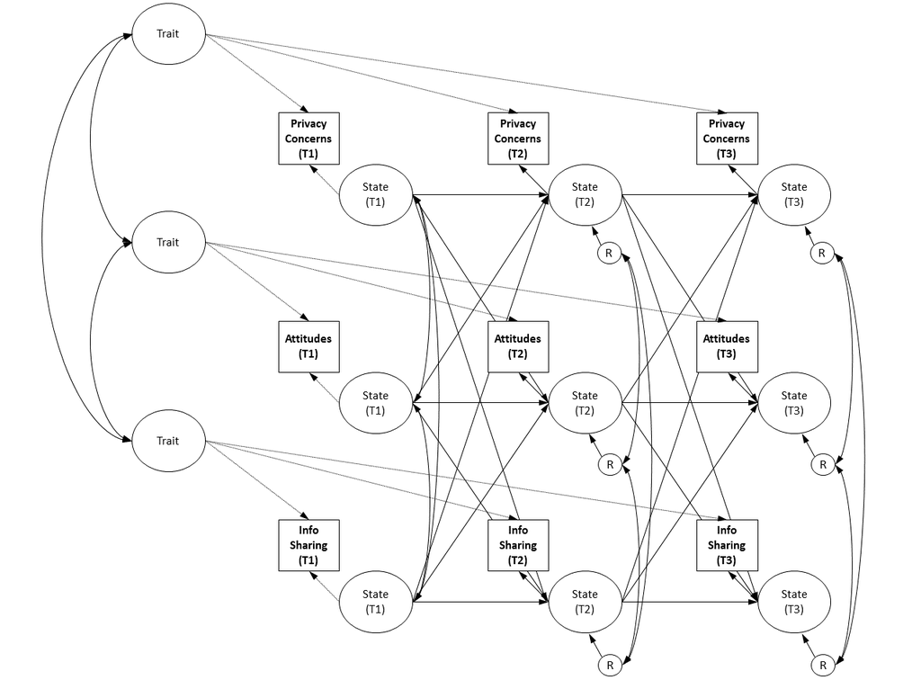

Visual representation of the estimated random-intercept cross-lagged panel model (RI-CLPM).

```r
knitr::include_graphics("../figures/model_7.png")
```

## Results

```r
model <- '
# between relations
pri_con_b =~ 1*t1_pri_con_fs + 1*t2_pri_con_fs + 1*t3_pri_con_fs
inf_sha_beh_b =~ 1*t1_inf_sha_beh_fs + 1*t2_inf_sha_beh_fs + 1*t3_inf_sha_beh_fs
inf_sha_att_b =~ 1*t1_inf_sha_att_fs + 1*t2_inf_sha_att_fs + 1*t3_inf_sha_att_fs

# within person changes
t1_pri_con_w =~ 1*t1_pri_con_fs
t2_pri_con_w =~ 1*t2_pri_con_fs
t3_pri_con_w =~ 1*t3_pri_con_fs
t1_inf_sha_beh_w =~ 1*t1_inf_sha_beh_fs
t2_inf_sha_beh_w =~ 1*t2_inf_sha_beh_fs
t3_inf_sha_beh_w =~ 1*t3_inf_sha_beh_fs
t1_inf_sha_att_w =~ 1*t1_inf_sha_att_fs
t2_inf_sha_att_w =~ 1*t2_inf_sha_att_fs
t3_inf_sha_att_w =~ 1*t3_inf_sha_att_fs

# within person effects
t2_pri_con_w ~ a1*t1_pri_con_w + a2*t1_inf_sha_att_w + a3*t1_inf_sha_beh_w
t2_inf_sha_att_w ~ b1*t1_pri_con_w + b2*t1_inf_sha_att_w + b3*t1_inf_sha_beh_w
t2_inf_sha_beh_w ~ c1*t1_pri_con_w + c2*t1_inf_sha_att_w + c3*t1_inf_sha_beh_w
t3_pri_con_w ~ a1*t2_pri_con_w + a2*t2_inf_sha_att_w + a3*t2_inf_sha_beh_w
t3_inf_sha_att_w ~ b1*t2_pri_con_w + b2*t2_inf_sha_att_w + b3*t2_inf_sha_beh_w
t3_inf_sha_beh_w ~ c1*t2_pri_con_w + c2*t2_inf_sha_att_w + c3*t2_inf_sha_beh_w

# covariances
pri_con_b ~~ cor_b_1*inf_sha_att_b + cor_b_2*inf_sha_beh_b
inf_sha_att_b ~~ cor_b_3*inf_sha_beh_b
t1_pri_con_w ~~ cor_w_1*t1_inf_sha_att_w + cor_w_2*t1_inf_sha_beh_w
t1_inf_sha_att_w ~~ cor_w_3*t1_inf_sha_beh_w
t2_pri_con_w ~~ a*t2_inf_sha_att_w + b*t2_inf_sha_beh_w
t2_inf_sha_att_w ~~ c*t2_inf_sha_beh_w
t3_pri_con_w ~~ a*t3_inf_sha_att_w + b*t3_inf_sha_beh_w
t3_inf_sha_att_w ~~ c*t3_inf_sha_beh_w

# setting variances of observed variables to zero
t1_pri_con_fs ~~ 0*t1_pri_con_fs
t2_pri_con_fs ~~ 0*t2_pri_con_fs
t3_pri_con_fs ~~ 0*t3_pri_con_fs
t1_inf_sha_att_fs ~~ 0*t1_inf_sha_att_fs
t2_inf_sha_att_fs ~~ 0*t2_inf_sha_att_fs
t3_inf_sha_att_fs ~~ 0*t3_inf_sha_att_fs
t1_inf_sha_beh_fs ~~ 0*t1_inf_sha_beh_fs
t2_inf_sha_beh_fs ~~ 0*t2_inf_sha_beh_fs
t3_inf_sha_beh_fs ~~ 0*t3_inf_sha_beh_fs

# control variables
t1_pri_con_fs ~ age + edu_num + male
t2_pri_con_fs ~ age + edu_num + male
t3_pri_con_fs ~ age + edu_num + male
t1_inf_sha_beh_fs ~ age + edu_num + male
t2_inf_sha_beh_fs ~ age + edu_num + male
t3_inf_sha_beh_fs ~ age + edu_num + male
t1_inf_sha_att_fs ~ age + edu_num + male
t2_inf_sha_att_fs ~ age + edu_num + male
t3_inf_sha_att_fs ~ age + edu_num + male
'
fit <- sem(model, data = d_wide, orthogonal = TRUE, missing = "ML")
summary(fit, standardized = TRUE, fit.measures = TRUE, ci = TRUE)
```

```
## lavaan 0.6-5 ended normally after 172 iterations
##
##   Estimator                                         ML
##   Optimization method                           NLMINB
##   Number of free parameters                         78
##   Number of equality constraints                    12
##   Row rank of the constraints matrix                12
##
##   Number of observations                          1403
##   Number of missing patterns                         1
##
## Model Test User Model:
##
##   Test statistic                                25.184
##   Degrees of freedom                                15
##   P-value (Chi-square)                           0.048
##
## Model Test Baseline Model:
##
##   Test statistic                              7133.872
##   Degrees of freedom                                63
##   P-value                                        0.000
##
## User Model versus Baseline Model:
##
##   Comparative Fit Index (CFI)                    0.999
##   Tucker-Lewis Index (TLI)                       0.994
##
## Loglikelihood and Information Criteria:
##
##   Loglikelihood user model (H0)             -10247.006
##   Loglikelihood unrestricted model (H1)     -10234.415
##
##   Akaike (AIC)                               20626.013
##   Bayesian (BIC)                             20972.273
##   Sample-size adjusted Bayesian (BIC)        20762.616
##
## Root Mean Square Error of Approximation:
##
##   RMSEA                                          0.022
```

[output cut: 177 more lines]

```
##    .t1_nf_sh_bh_fs    0.000                               0.000    0.000    0.000    0.000
##    .t2_nf_sh_bh_fs    0.000                               0.000    0.000    0.000    0.000
##    .t3_nf_sh_bh_fs    0.000                               0.000    0.000    0.000    0.000
##     pri_con_b         0.542    0.025   21.853    0.000    0.494    0.591    1.000    1.000
##     inf_sha_beh_b     0.217    0.011   19.186    0.000    0.195    0.239    1.000    1.000
##     inf_sha_att_b     0.236    0.014   16.521    0.000    0.208    0.264    1.000    1.000
##     t1_pri_con_w      0.162    0.010   15.492    0.000    0.141    0.182    1.000    1.000
##    .t2_pri_con_w      0.199    0.021    9.670    0.000    0.158    0.239    0.982    0.982
##    .t3_pri_con_w      0.177    0.011   16.686    0.000    0.156    0.198    0.976    0.976
##     t1_inf_sh_bh_w    0.182    0.010   18.768    0.000    0.163    0.201    1.000    1.000
##    .t2_inf_sh_bh_w    0.162    0.011   14.695    0.000    0.141    0.184    0.998    0.998
##    .t3_inf_sh_bh_w    0.128    0.007   17.307    0.000    0.113    0.142    0.997    0.997
##     t1_inf_sh_tt_w    0.218    0.012   18.456    0.000    0.194    0.241    1.000    1.000
##    .t2_inf_sh_tt_w    0.200    0.015   13.697    0.000    0.172    0.229    0.985    0.985
##    .t3_inf_sh_tt_w    0.179    0.010   18.200    0.000    0.160    0.199    0.985    0.985
```

# Additional Analyses

## RI-CLPM

### Assumptions

#### Multivariate Normal Distribution

```r
mult_norm_test <- mvn(d_fs)
print(mult_norm_test)
```

```
## $multivariateNormality
##              Test        Statistic               p value Result
## 1 Mardia Skewness 990.267353659167 8.80036401559507e-118     NO
## 2 Mardia Kurtosis 33.7173011274092                     0     NO
## 3             MVN             <NA>                  <NA>     NO
##
## $univariateNormality
##           Test          Variable Statistic   p value Normality
## 1 Shapiro-Wilk   Concerns\nT1        0.962  <0.001      NO
## 2 Shapiro-Wilk   Concerns\nT2        0.965  <0.001      NO
## 3 Shapiro-Wilk   Concerns\nT3        0.968  <0.001      NO
## 4 Shapiro-Wilk Pos. Attitude\nT1     0.984  <0.001      NO
## 5 Shapiro-Wilk Pos. Attitude\nT2     0.986  <0.001      NO
## 6 Shapiro-Wilk Pos. Attitude\nT3     0.983  <0.001      NO
## 7 Shapiro-Wilk Inf. Sharing\nT1      0.968  <0.001      NO
## 8 Shapiro-Wilk Inf. Sharing\nT2      0.975  <0.001      NO
## 9 Shapiro-Wilk Inf. Sharing\nT3      0.974  <0.001      NO
##
## $Descriptives
##                      n Mean Std.Dev Median   Min  Max 25th 75th    Skew Kurtosis
## Concerns\nT1      1403 3.71   0.853   3.79 1.172 4.98 3.15 4.41 -0.5089  -0.3576
## Concerns\nT2      1403 3.64   0.874   3.70 1.160 4.95 3.07 4.34 -0.4840  -0.3586
## Concerns\nT3      1403 3.61   0.874   3.65 1.140 4.94 3.05 4.32 -0.4454  -0.3978
## Pos. Attitude\nT1 1403 2.42   0.685   2.47 0.965 4.62 2.00 2.82 -0.0347  -0.1182
## Pos. Attitude\nT2 1403 2.48   0.686   2.52 1.039 4.57 2.06 2.90 -0.0431  -0.1094
## Pos. Attitude\nT3 1403 2.50   0.675   2.57 0.994 4.48 2.12 2.89 -0.1501  -0.0706
## Inf. Sharing\nT1  1403 2.19   0.661   2.11 0.964 4.46 1.74 2.57  0.5425   0.1268
## Inf. Sharing\nT2  1403 2.21   0.638   2.17 1.030 4.46 1.74 2.57  0.4240  -0.1104
## Inf. Sharing\nT3  1403 2.17   0.614   2.11 0.983 4.23 1.73 2.53  0.4674  -0.0260
```

Results show that the assumption of multivariate normal distribution was violated. Hence, it’d be preferrable to conduct robust Maximum Likelihood Estimation. However, using robust estimation it’s not possible to run SEM on all data using Full Information Maximum Likehoood (FIML). Given that we consider it more important to include as much information as possible and that estimators often produce similar results, we decided to estimate the following models using regular maximum likehood.

### Two Variables

Here, we look at the bivariate relations of privacy concerns and information sharing. This is interesting, because in the paper we also address privacy attitudes, thereby potentially attentuating the effect of privacy concerns. However, when analyzing only these two variables we do not find larger effects sizes.

#### Model 1

Here, we use regular observed means.

```r
model <- '
# between relations
pri_con_b =~ 1*t1_pri_con_m + 1*t2_pri_con_m + 1*t3_pri_con_m
inf_sha_beh_b =~ 1*t1_inf_sha_beh_m + 1*t2_inf_sha_beh_m + 1*t3_inf_sha_beh_m

# intercepts
t1_pri_con_m ~ mu1*1
t2_pri_con_m ~ mu2*1
t3_pri_con_m ~ mu3*1
t1_inf_sha_beh_m ~ pi1*1
t2_inf_sha_beh_m ~ pi2*1
t3_inf_sha_beh_m ~ pi3*1

# within person changes
t1_pri_con_w =~ 1*t1_pri_con_m
t2_pri_con_w =~ 1*t2_pri_con_m
t3_pri_con_w =~ 1*t3_pri_con_m
t1_inf_sha_beh_w =~ 1*t1_inf_sha_beh_m
t2_inf_sha_beh_w =~ 1*t2_inf_sha_beh_m
t3_inf_sha_beh_w =~ 1*t3_inf_sha_beh_m

# estimate variances
pri_con_b ~~ pri_con_b
inf_sha_beh_b ~~ inf_sha_beh_b
t1_pri_con_w ~~ t1_pri_con_w
t2_pri_con_w ~~ t2_pri_con_w
t3_pri_con_w ~~ t3_pri_con_w
t1_inf_sha_beh_w ~~ t1_inf_sha_beh_w
t2_inf_sha_beh_w ~~ t2_inf_sha_beh_w
t3_inf_sha_beh_w ~~ t3_inf_sha_beh_w

# within person effects
t2_pri_con_w ~ a1*t1_pri_con_w + a2*t1_inf_sha_beh_w
t2_inf_sha_beh_w ~ b1*t1_pri_con_w + b2*t1_inf_sha_beh_w
t3_pri_con_w ~ a1*t2_pri_con_w + a2*t2_inf_sha_beh_w
t3_inf_sha_beh_w ~ b1*t2_pri_con_w + b2*t2_inf_sha_beh_w

# covariances
pri_con_b ~~ inf_sha_beh_b
t1_pri_con_w ~~ t1_inf_sha_beh_w
t2_pri_con_w ~~ a*t2_inf_sha_beh_w
t3_pri_con_w ~~ a*t3_inf_sha_beh_w
'

fit <- lavaan(model, data = d_wide, missing = "ML")
summary(fit, standardized = TRUE, fit.measures = TRUE)
```

```
## lavaan 0.6-5 ended normally after 42 iterations
##
##   Estimator                                         ML
##   Optimization method                           NLMINB
##   Number of free parameters                         26
##   Number of equality constraints                     5
##   Row rank of the constraints matrix                 5
##
##   Number of observations                          1403
##   Number of missing patterns                         4
##
## Model Test User Model:
##
##   Test statistic                                 3.780
##   Degrees of freedom                                 6
##   P-value (Chi-square)                           0.706
##
## Model Test Baseline Model:
##
##   Test statistic                              4114.935
##   Degrees of freedom                                15
##   P-value                                        0.000
##
## User Model versus Baseline Model:
##
##   Comparative Fit Index (CFI)                    1.000
##   Tucker-Lewis Index (TLI)                       1.001
##
## Loglikelihood and Information Criteria:
##
##   Loglikelihood user model (H0)              -7478.685
##   Loglikelihood unrestricted model (H1)      -7476.795
##
##   Akaike (AIC)                               14999.371
##   Bayesian (BIC)                             15109.545
##   Sample-size adjusted Bayesian (BIC)        15042.835
##
## Root Mean Square Error of Approximation:
##
##   RMSEA                                          0.000
```

[output cut: 81 more lines]

```
##                    Estimate  Std.Err  z-value  P(>|z|)   Std.lv  Std.all
##     pri_con_b         0.575    0.027   21.060    0.000    1.000    1.000
##     inf_sha_beh_b     0.245    0.013   19.278    0.000    1.000    1.000
##     t1_pri_con_w      0.209    0.013   16.655    0.000    1.000    1.000
##    .t2_pri_con_w      0.220    0.026    8.386    0.000    0.993    0.993
##    .t3_pri_con_w      0.218    0.013   17.469    0.000    0.992    0.992
##     t1_inf_sh_bh_w    0.183    0.010   18.744    0.000    1.000    1.000
##    .t2_inf_sh_bh_w    0.166    0.014   11.927    0.000    0.997    0.997
##    .t3_inf_sh_bh_w    0.134    0.008   17.035    0.000    0.996    0.996
##    .t1_pri_con_m      0.000                               0.000    0.000
##    .t2_pri_con_m      0.000                               0.000    0.000
##    .t3_pri_con_m      0.000                               0.000    0.000
##    .t1_inf_sh_bh_m    0.000                               0.000    0.000
##    .t2_inf_sh_bh_m    0.000                               0.000    0.000
##    .t3_inf_sh_bh_m    0.000                               0.000    0.000
```

#### Model 2

Model with a (broad) single item measure of privacy concerns (“In general, how concerned are you about your privacy while using the Internet?”).

```r
model <- '
# between relations
pri_con_b =~ 1*t1_pri_con_01 + 1*t2_pri_con_01 + 1*t3_pri_con_01
inf_sha_beh_b =~ 1*t1_inf_sha_beh_m + 1*t2_inf_sha_beh_m + 1*t3_inf_sha_beh_m

# intercepts
t1_pri_con_01 ~ mu1*1
t2_pri_con_01 ~ mu2*1
t3_pri_con_01 ~ mu3*1
t1_inf_sha_beh_m ~ pi1*1
t2_inf_sha_beh_m ~ pi2*1
t3_inf_sha_beh_m ~ pi3*1

# within person changes
t1_pri_con_w =~ 1*t1_pri_con_01
t2_pri_con_w =~ 1*t2_pri_con_01
t3_pri_con_w =~ 1*t3_pri_con_01
t1_inf_sha_beh_w =~ 1*t1_inf_sha_beh_m
t2_inf_sha_beh_w =~ 1*t2_inf_sha_beh_m
t3_inf_sha_beh_w =~ 1*t3_inf_sha_beh_m

# estimate variances
pri_con_b ~~ pri_con_b
inf_sha_beh_b ~~ inf_sha_beh_b
t1_pri_con_w ~~ t1_pri_con_w
t2_pri_con_w ~~ t2_pri_con_w
t3_pri_con_w ~~ t3_pri_con_w
t1_inf_sha_beh_w ~~ t1_inf_sha_beh_w
t2_inf_sha_beh_w ~~ t2_inf_sha_beh_w
t3_inf_sha_beh_w ~~ t3_inf_sha_beh_w

# within person effects
t2_pri_con_w ~ a1*t1_pri_con_w + a2*t1_inf_sha_beh_w
t2_inf_sha_beh_w ~ b1*t1_pri_con_w + b2*t1_inf_sha_beh_w
t3_pri_con_w ~ a1*t2_pri_con_w + a2*t2_inf_sha_beh_w
t3_inf_sha_beh_w ~ b1*t2_pri_con_w + b2*t2_inf_sha_beh_w

# covariances
pri_con_b ~~ inf_sha_beh_b
t1_pri_con_w ~~ t1_inf_sha_beh_w
t2_pri_con_w ~~ a*t2_inf_sha_beh_w
t3_pri_con_w ~~ a*t3_inf_sha_beh_w
'

fit <- lavaan(model, data = d_wide, missing = "ML")
summary(fit, standardized = TRUE, fit.measures = TRUE)
```

```
## lavaan 0.6-5 ended normally after 42 iterations
##
##   Estimator                                         ML
##   Optimization method                           NLMINB
##   Number of free parameters                         26
##   Number of equality constraints                     5
##   Row rank of the constraints matrix                 5
##
##   Number of observations                          1403
##   Number of missing patterns                         4
##
## Model Test User Model:
##
##   Test statistic                                 1.834
##   Degrees of freedom                                 6
##   P-value (Chi-square)                           0.934
##
## Model Test Baseline Model:
##
##   Test statistic                              2962.543
##   Degrees of freedom                                15
##   P-value                                        0.000
##
## User Model versus Baseline Model:
##
##   Comparative Fit Index (CFI)                    1.000
##   Tucker-Lewis Index (TLI)                       1.004
##
## Loglikelihood and Information Criteria:
##
##   Loglikelihood user model (H0)              -8913.859
##   Loglikelihood unrestricted model (H1)      -8912.942
##
##   Akaike (AIC)                               17869.717
##   Bayesian (BIC)                             17979.891
##   Sample-size adjusted Bayesian (BIC)        17913.182
##
## Root Mean Square Error of Approximation:
##
##   RMSEA                                          0.000
```

[output cut: 81 more lines]

```
##                    Estimate  Std.Err  z-value  P(>|z|)   Std.lv  Std.all
##     pri_con_b         0.707    0.037   19.173    0.000    1.000    1.000
##     inf_sha_beh_b     0.245    0.013   19.261    0.000    1.000    1.000
##     t1_pri_con_w      0.498    0.027   18.186    0.000    1.000    1.000
##    .t2_pri_con_w      0.442    0.043   10.295    0.000    0.998    0.998
##    .t3_pri_con_w      0.519    0.027   18.911    0.000    0.999    0.999
##     t1_inf_sh_bh_w    0.184    0.010   18.734    0.000    1.000    1.000
##    .t2_inf_sh_bh_w    0.166    0.014   11.855    0.000    0.998    0.998
##    .t3_inf_sh_bh_w    0.134    0.008   16.993    0.000    0.998    0.998
##    .t1_pri_con_01     0.000                               0.000    0.000
##    .t2_pri_con_01     0.000                               0.000    0.000
##    .t3_pri_con_01     0.000                               0.000    0.000
##    .t1_inf_sh_bh_m    0.000                               0.000    0.000
##    .t2_inf_sh_bh_m    0.000                               0.000    0.000
##    .t3_inf_sh_bh_m    0.000                               0.000    0.000
```

#### Model 3

With Factor Scores.

```r
model <- '
# between relations
pri_con_b =~ 1*t1_pri_con_fs + 1*t2_pri_con_fs + 1*t3_pri_con_fs
inf_sha_beh_b =~ 1*t1_inf_sha_beh_fs + 1*t2_inf_sha_beh_fs + 1*t3_inf_sha_beh_fs

# intercepts
t1_pri_con_fs ~ 1
t2_pri_con_fs ~ 1
t3_pri_con_fs ~ 1
t1_inf_sha_beh_fs ~ 1
t2_inf_sha_beh_fs ~ 1
t3_inf_sha_beh_fs ~ 1

# within person changes
t1_pri_con_w =~ 1*t1_pri_con_fs
t2_pri_con_w =~ 1*t2_pri_con_fs
t3_pri_con_w =~ 1*t3_pri_con_fs
t1_inf_sha_beh_w =~ 1*t1_inf_sha_beh_fs
t2_inf_sha_beh_w =~ 1*t2_inf_sha_beh_fs
t3_inf_sha_beh_w =~ 1*t3_inf_sha_beh_fs

# estimate variances
pri_con_b ~~ pri_con_b
inf_sha_beh_b ~~ inf_sha_beh_b
t1_pri_con_w ~~ t1_pri_con_w
t2_pri_con_w ~~ t2_pri_con_w
t3_pri_con_w ~~ t3_pri_con_w
t1_inf_sha_beh_w ~~ t1_inf_sha_beh_w
t2_inf_sha_beh_w ~~ t2_inf_sha_beh_w
t3_inf_sha_beh_w ~~ t3_inf_sha_beh_w

# within person effects
t2_pri_con_w ~ a1*t1_pri_con_w + a2*t1_inf_sha_beh_w
t2_inf_sha_beh_w ~ b1*t1_pri_con_w + b2*t1_inf_sha_beh_w
t3_pri_con_w ~ a1*t2_pri_con_w + a2*t2_inf_sha_beh_w
t3_inf_sha_beh_w ~ b1*t2_pri_con_w + b2*t2_inf_sha_beh_w

# covariances
pri_con_b ~~ inf_sha_beh_b
t1_pri_con_w ~~ t1_inf_sha_beh_w
t2_pri_con_w ~~ a*t2_inf_sha_beh_w
t3_pri_con_w ~~ a*t3_inf_sha_beh_w
'
fit <- lavaan(model, data = d_wide)
summary(fit, standardized = TRUE, fit.measures = TRUE)
```

```
## lavaan 0.6-5 ended normally after 48 iterations
##
##   Estimator                                         ML
##   Optimization method                           NLMINB
##   Number of free parameters                         26
##   Number of equality constraints                     5
##   Row rank of the constraints matrix                 5
##
##   Number of observations                          1403
##
## Model Test User Model:
##
##   Test statistic                                 4.872
##   Degrees of freedom                                 6
##   P-value (Chi-square)                           0.560
##
## Model Test Baseline Model:
##
##   Test statistic                              4626.338
##   Degrees of freedom                                15
##   P-value                                        0.000
##
## User Model versus Baseline Model:
##
##   Comparative Fit Index (CFI)                    1.000
##   Tucker-Lewis Index (TLI)                       1.001
##
## Loglikelihood and Information Criteria:
##
##   Loglikelihood user model (H0)              -7132.494
##   Loglikelihood unrestricted model (H1)      -7130.059
##
##   Akaike (AIC)                               14306.989
##   Bayesian (BIC)                             14417.162
##   Sample-size adjusted Bayesian (BIC)        14350.453
##
## Root Mean Square Error of Approximation:
##
##   RMSEA                                          0.000
##   90 Percent confidence interval - lower         0.000
```

[output cut: 80 more lines]

```
##                    Estimate  Std.Err  z-value  P(>|z|)   Std.lv  Std.all
##     pri_con_b         0.570    0.026   22.266    0.000    1.000    1.000
##     inf_sha_beh_b     0.250    0.013   19.509    0.000    1.000    1.000
##     t1_pri_con_w      0.162    0.010   15.544    0.000    1.000    1.000
##    .t2_pri_con_w      0.196    0.020   10.020    0.000    0.984    0.984
##    .t3_pri_con_w      0.176    0.010   16.999    0.000    0.979    0.979
##     t1_inf_sh_bh_w    0.176    0.009   18.803    0.000    1.000    1.000
##    .t2_inf_sh_bh_w    0.156    0.014   10.841    0.000    0.999    0.999
##    .t3_inf_sh_bh_w    0.134    0.008   17.221    0.000    0.999    0.999
##    .t1_pri_con_fs     0.000                               0.000    0.000
##    .t2_pri_con_fs     0.000                               0.000    0.000
##    .t3_pri_con_fs     0.000                               0.000    0.000
##    .t1_nf_sh_bh_fs    0.000                               0.000    0.000
##    .t2_nf_sh_bh_fs    0.000                               0.000    0.000
##    .t3_nf_sh_bh_fs    0.000                               0.000    0.000
```

#### Model 4

With Factor Scores and Control Variables.

```r
model <- '
# between relations
pri_con_b =~ 1*t1_pri_con_fs + 1*t2_pri_con_fs + 1*t3_pri_con_fs
inf_sha_beh_b =~ 1*t1_inf_sha_beh_fs + 1*t2_inf_sha_beh_fs + 1*t3_inf_sha_beh_fs

# intercepts
t1_pri_con_fs ~ 1
t2_pri_con_fs ~ 1
t3_pri_con_fs ~ 1
t1_inf_sha_beh_fs ~ 1
t2_inf_sha_beh_fs ~ 1
t3_inf_sha_beh_fs ~ 1

# within person changes
t1_pri_con_w =~ 1*t1_pri_con_fs
t2_pri_con_w =~ 1*t2_pri_con_fs
t3_pri_con_w =~ 1*t3_pri_con_fs
t1_inf_sha_beh_w =~ 1*t1_inf_sha_beh_fs
t2_inf_sha_beh_w =~ 1*t2_inf_sha_beh_fs
t3_inf_sha_beh_w =~ 1*t3_inf_sha_beh_fs

# estimate variances
pri_con_b ~~ pri_con_b
inf_sha_beh_b ~~ inf_sha_beh_b
t1_pri_con_w ~~ t1_pri_con_w
t2_pri_con_w ~~ t2_pri_con_w
t3_pri_con_w ~~ t3_pri_con_w
t1_inf_sha_beh_w ~~ t1_inf_sha_beh_w
t2_inf_sha_beh_w ~~ t2_inf_sha_beh_w
t3_inf_sha_beh_w ~~ t3_inf_sha_beh_w

# within person effects
t2_pri_con_w ~ a1*t1_pri_con_w + a2*t1_inf_sha_beh_w
t2_inf_sha_beh_w ~ b1*t1_pri_con_w + b2*t1_inf_sha_beh_w
t3_pri_con_w ~ a1*t2_pri_con_w + a2*t2_inf_sha_beh_w
t3_inf_sha_beh_w ~ b1*t2_pri_con_w + b2*t2_inf_sha_beh_w

# covariances
pri_con_b ~~ inf_sha_beh_b
t1_pri_con_w ~~ t1_inf_sha_beh_w
t2_pri_con_w ~~ a*t2_inf_sha_beh_w
t3_pri_con_w ~~ a*t3_inf_sha_beh_w

# control variables
t1_pri_con_fs ~ age + edu_num + male
t2_pri_con_fs ~ age + edu_num + male
t3_pri_con_fs ~ age + edu_num + male
t1_inf_sha_beh_fs ~ age + edu_num + male
t2_inf_sha_beh_fs ~ age + edu_num + male
t3_inf_sha_beh_fs ~ age + edu_num + male
'

fit <- lavaan(model, data = d_wide, missing = "ml")
summary(fit, standardized = TRUE, fit.measures = TRUE)
```

```
## lavaan 0.6-5 ended normally after 116 iterations
##
##   Estimator                                         ML
##   Optimization method                           NLMINB
##   Number of free parameters                         44
##   Number of equality constraints                     5
##   Row rank of the constraints matrix                 5
##
##   Number of observations                          1403
##   Number of missing patterns                         1
##
## Model Test User Model:
##
##   Test statistic                                 6.268
##   Degrees of freedom                                 6
##   P-value (Chi-square)                           0.394
##
## Model Test Baseline Model:
##
##   Test statistic                              4835.946
##   Degrees of freedom                                33
##   P-value                                        0.000
##
## User Model versus Baseline Model:
##
##   Comparative Fit Index (CFI)                    1.000
##   Tucker-Lewis Index (TLI)                       1.000
##
## Loglikelihood and Information Criteria:
##
##   Loglikelihood user model (H0)              -7028.389
##   Loglikelihood unrestricted model (H1)      -7025.255
##
##   Akaike (AIC)                               14134.777
##   Bayesian (BIC)                             14339.386
##   Sample-size adjusted Bayesian (BIC)        14215.497
##
## Root Mean Square Error of Approximation:
##
##   RMSEA                                          0.006
```

[output cut: 105 more lines]

```
##                    Estimate  Std.Err  z-value  P(>|z|)   Std.lv  Std.all
##     pri_con_b         0.542    0.025   21.867    0.000    1.000    1.000
##     inf_sha_beh_b     0.219    0.011   19.078    0.000    1.000    1.000
##     t1_pri_con_w      0.163    0.010   15.492    0.000    1.000    1.000
##    .t2_pri_con_w      0.199    0.021    9.694    0.000    0.982    0.982
##    .t3_pri_con_w      0.176    0.011   16.699    0.000    0.976    0.976
##     t1_inf_sh_bh_w    0.177    0.010   18.671    0.000    1.000    1.000
##    .t2_inf_sh_bh_w    0.155    0.013   12.395    0.000    0.999    0.999
##    .t3_inf_sh_bh_w    0.132    0.008   17.350    0.000    0.999    0.999
##    .t1_pri_con_fs     0.000                               0.000    0.000
##    .t2_pri_con_fs     0.000                               0.000    0.000
##    .t3_pri_con_fs     0.000                               0.000    0.000
##    .t1_nf_sh_bh_fs    0.000                               0.000    0.000
##    .t2_nf_sh_bh_fs    0.000                               0.000    0.000
##    .t3_nf_sh_bh_fs    0.000                               0.000    0.000
```

#### Model 5

In this model, we omit all longitudinal paths in order to better estimate the concurrent relations of the variables for *all* waves (in the regular RI-CLPM, only the relations at wave 1 can be interpreted meaningfully).

```r
model <- "
# between relations
pri_con_b =~ 1*t1_pri_con_m + 1*t2_pri_con_m + 1*t3_pri_con_m
inf_sha_beh_b =~ 1*t1_inf_sha_beh_m + 1*t2_inf_sha_beh_m + 1*t3_inf_sha_beh_m

# intercepts
t1_pri_con_m ~ mu1*1
t2_pri_con_m ~ mu2*1
t3_pri_con_m ~ mu3*1
t1_inf_sha_beh_m ~ pi1*1
t2_inf_sha_beh_m ~ pi2*1
t3_inf_sha_beh_m ~ pi3*1

# within person changes
t1_pri_con_w =~ 1*t1_pri_con_m
t2_pri_con_w =~ 1*t2_pri_con_m
t3_pri_con_w =~ 1*t3_pri_con_m
t1_inf_sha_beh_w =~ 1*t1_inf_sha_beh_m
t2_inf_sha_beh_w =~ 1*t2_inf_sha_beh_m
t3_inf_sha_beh_w =~ 1*t3_inf_sha_beh_m

# estimate variances
pri_con_b ~~ pri_con_b
inf_sha_beh_b ~~ inf_sha_beh_b
t1_pri_con_w ~~ t1_pri_con_w
t2_pri_con_w ~~ t2_pri_con_w
t3_pri_con_w ~~ t3_pri_con_w
t1_inf_sha_beh_w ~~ t1_inf_sha_beh_w
t2_inf_sha_beh_w ~~ t2_inf_sha_beh_w
t3_inf_sha_beh_w ~~ t3_inf_sha_beh_w

# covariances
pri_con_b ~~ inf_sha_beh_b
t1_pri_con_w ~~ a*t1_inf_sha_beh_w
t2_pri_con_w ~~ a*t2_inf_sha_beh_w
t3_pri_con_w ~~ a*t3_inf_sha_beh_w
"

fit <- lavaan(model, data = d_wide, missing = "ml")
summary(fit, standardized = TRUE, fit.measures = TRUE)
```

```
## lavaan 0.6-5 ended normally after 43 iterations
##
##   Estimator                                         ML
##   Optimization method                           NLMINB
##   Number of free parameters                         18
##   Number of equality constraints                     2
##   Row rank of the constraints matrix                 2
##
##   Number of observations                          1403
##   Number of missing patterns                         4
##
## Model Test User Model:
##
##   Test statistic                                 9.758
##   Degrees of freedom                                11
##   P-value (Chi-square)                           0.552
##
## Model Test Baseline Model:
##
##   Test statistic                              4114.935
##   Degrees of freedom                                15
##   P-value                                        0.000
##
## User Model versus Baseline Model:
##
##   Comparative Fit Index (CFI)                    1.000
##   Tucker-Lewis Index (TLI)                       1.000
##
## Loglikelihood and Information Criteria:
##
##   Loglikelihood user model (H0)              -7481.675
##   Loglikelihood unrestricted model (H1)      -7476.795
##
##   Akaike (AIC)                               14995.349
##   Bayesian (BIC)                             15079.291
##   Sample-size adjusted Bayesian (BIC)        15028.465
##
## Root Mean Square Error of Approximation:
##
##   RMSEA                                          0.000
```

[output cut: 66 more lines]

```
##                    Estimate  Std.Err  z-value  P(>|z|)   Std.lv  Std.all
##     pri_con_b         0.589    0.025   23.655    0.000    1.000    1.000
##     inf_sha_beh_b     0.250    0.011   21.807    0.000    1.000    1.000
##     t1_pri_con_w      0.206    0.011   18.002    0.000    1.000    1.000
##     t2_pri_con_w      0.191    0.011   17.470    0.000    1.000    1.000
##     t3_pri_con_w      0.214    0.012   18.435    0.000    1.000    1.000
##     t1_inf_sh_bh_w    0.180    0.009   19.921    0.000    1.000    1.000
##     t2_inf_sh_bh_w    0.157    0.008   18.899    0.000    1.000    1.000
##     t3_inf_sh_bh_w    0.133    0.008   17.519    0.000    1.000    1.000
##    .t1_pri_con_m      0.000                               0.000    0.000
##    .t2_pri_con_m      0.000                               0.000    0.000
##    .t3_pri_con_m      0.000                               0.000    0.000
##    .t1_inf_sh_bh_m    0.000                               0.000    0.000
##    .t2_inf_sh_bh_m    0.000                               0.000    0.000
##    .t3_inf_sh_bh_m    0.000                               0.000    0.000
```

#### Model 6

The same like above, using Factor Scores and control variables.

```r
model <- '
# between relations
pri_con_b =~ 1*t1_pri_con_fs + 1*t2_pri_con_fs + 1*t3_pri_con_fs
inf_sha_beh_b =~ 1*t1_inf_sha_beh_fs + 1*t2_inf_sha_beh_fs + 1*t3_inf_sha_beh_fs

# intercepts
t1_pri_con_fs ~ 1
t2_pri_con_fs ~ 1
t3_pri_con_fs ~ 1
t1_inf_sha_beh_fs ~ 1
t2_inf_sha_beh_fs ~ 1
t3_inf_sha_beh_fs ~ 1

# within person changes
t1_pri_con_w =~ 1*t1_pri_con_fs
t2_pri_con_w =~ 1*t2_pri_con_fs
t3_pri_con_w =~ 1*t3_pri_con_fs
t1_inf_sha_beh_w =~ 1*t1_inf_sha_beh_fs
t2_inf_sha_beh_w =~ 1*t2_inf_sha_beh_fs
t3_inf_sha_beh_w =~ 1*t3_inf_sha_beh_fs

# estimate variances
pri_con_b ~~ pri_con_b
inf_sha_beh_b ~~ inf_sha_beh_b
t1_pri_con_w ~~ t1_pri_con_w
t2_pri_con_w ~~ t2_pri_con_w
t3_pri_con_w ~~ t3_pri_con_w
t1_inf_sha_beh_w ~~ t1_inf_sha_beh_w
t2_inf_sha_beh_w ~~ t2_inf_sha_beh_w
t3_inf_sha_beh_w ~~ t3_inf_sha_beh_w

# covariances
pri_con_b ~~ inf_sha_beh_b
t1_pri_con_w ~~ a*t1_inf_sha_beh_w
t2_pri_con_w ~~ a*t2_inf_sha_beh_w
t3_pri_con_w ~~ a*t3_inf_sha_beh_w

# control variables
t1_pri_con_fs ~ age + edu_num + male
t2_pri_con_fs ~ age + edu_num + male
t3_pri_con_fs ~ age + edu_num + male
t1_inf_sha_beh_fs ~ age + edu_num + male
t2_inf_sha_beh_fs ~ age + edu_num + male
t3_inf_sha_beh_fs ~ age + edu_num + male
'

fit <- lavaan(model, data = d_wide, missing = "ml")
summary(fit, standardized = TRUE, fit.measures = TRUE)
```

```
## lavaan 0.6-5 ended normally after 108 iterations
##
##   Estimator                                         ML
##   Optimization method                           NLMINB
##   Number of free parameters                         36
##   Number of equality constraints                     2
##   Row rank of the constraints matrix                 2
##
##   Number of observations                          1403
##   Number of missing patterns                         1
##
## Model Test User Model:
##
##   Test statistic                                18.421
##   Degrees of freedom                                11
##   P-value (Chi-square)                           0.072
##
## Model Test Baseline Model:
##
##   Test statistic                              4835.946
##   Degrees of freedom                                33
##   P-value                                        0.000
##
## User Model versus Baseline Model:
##
##   Comparative Fit Index (CFI)                    0.998
##   Tucker-Lewis Index (TLI)                       0.995
##
## Loglikelihood and Information Criteria:
##
##   Loglikelihood user model (H0)              -7034.465
##   Loglikelihood unrestricted model (H1)      -7025.255
##
##   Akaike (AIC)                               14136.930
##   Bayesian (BIC)                             14315.306
##   Sample-size adjusted Bayesian (BIC)        14207.301
##
## Root Mean Square Error of Approximation:
##
##   RMSEA                                          0.022
```

[output cut: 93 more lines]

```
##                    Estimate  Std.Err  z-value  P(>|z|)   Std.lv  Std.all
##     pri_con_b         0.562    0.023   24.101    0.000    1.000    1.000
##     inf_sha_beh_b     0.222    0.010   21.431    0.000    1.000    1.000
##     t1_pri_con_w      0.160    0.009   17.623    0.000    1.000    1.000
##     t2_pri_con_w      0.159    0.009   17.698    0.000    1.000    1.000
##     t3_pri_con_w      0.169    0.009   18.168    0.000    1.000    1.000
##     t1_inf_sh_bh_w    0.176    0.009   20.015    0.000    1.000    1.000
##     t2_inf_sh_bh_w    0.149    0.008   18.825    0.000    1.000    1.000
##     t3_inf_sh_bh_w    0.131    0.007   17.765    0.000    1.000    1.000
##    .t1_pri_con_fs     0.000                               0.000    0.000
##    .t2_pri_con_fs     0.000                               0.000    0.000
##    .t3_pri_con_fs     0.000                               0.000    0.000
##    .t1_nf_sh_bh_fs    0.000                               0.000    0.000
##    .t2_nf_sh_bh_fs    0.000                               0.000    0.000
##    .t3_nf_sh_bh_fs    0.000                               0.000    0.000
```

### Three Variables

#### Model 1

With observed means.

```r
model <- '
# random intercepts (between person)
pri_con_b =~ 1*t1_pri_con_m + 1*t2_pri_con_m + 1*t3_pri_con_m
inf_sha_att_b =~ 1*t1_inf_sha_att_m + 1*t2_inf_sha_att_m + 1*t3_inf_sha_att_m
inf_sha_beh_b =~ 1*t1_inf_sha_beh_m + 1*t2_inf_sha_beh_m + 1*t3_inf_sha_beh_m

# within person changes
t1_pri_con_w =~ 1*t1_pri_con_m
t2_pri_con_w =~ 1*t2_pri_con_m
t3_pri_con_w =~ 1*t3_pri_con_m
t1_inf_sha_att_w =~ 1*t1_inf_sha_att_m
t2_inf_sha_att_w =~ 1*t2_inf_sha_att_m
t3_inf_sha_att_w =~ 1*t3_inf_sha_att_m
t1_inf_sha_beh_w =~ 1*t1_inf_sha_beh_m
t2_inf_sha_beh_w =~ 1*t2_inf_sha_beh_m
t3_inf_sha_beh_w =~ 1*t3_inf_sha_beh_m

# within person effects
t2_pri_con_w ~ a1*t1_pri_con_w + a2*t1_inf_sha_att_w + a3*t1_inf_sha_beh_w
t2_inf_sha_att_w ~ b1*t1_pri_con_w + b2*t1_inf_sha_att_w + b3*t1_inf_sha_beh_w
t2_inf_sha_beh_w ~ c1*t1_pri_con_w + c2*t1_inf_sha_att_w + c3*t1_inf_sha_beh_w
t3_pri_con_w ~ a1*t2_pri_con_w + a2*t2_inf_sha_att_w + a3*t2_inf_sha_beh_w
t3_inf_sha_att_w ~ b1*t2_pri_con_w + b2*t2_inf_sha_att_w + b3*t2_inf_sha_beh_w
t3_inf_sha_beh_w ~ c1*t2_pri_con_w + c2*t2_inf_sha_att_w + c3*t2_inf_sha_beh_w

# setting variances of observed variables to zero
t1_pri_con_m ~~ 0*t1_pri_con_m
t2_pri_con_m ~~ 0*t2_pri_con_m
t3_pri_con_m ~~ 0*t3_pri_con_m
t1_inf_sha_att_m ~~ 0*t1_inf_sha_att_m
t2_inf_sha_att_m ~~ 0*t2_inf_sha_att_m
t3_inf_sha_att_m ~~ 0*t3_inf_sha_att_m
t1_inf_sha_beh_m ~~ 0*t1_inf_sha_beh_m
t2_inf_sha_beh_m ~~ 0*t2_inf_sha_beh_m
t3_inf_sha_beh_m ~~ 0*t3_inf_sha_beh_m

# allow covariances RIs & variables measured at the same time
pri_con_b ~~ inf_sha_att_b + inf_sha_beh_b
inf_sha_att_b ~~ inf_sha_beh_b
t1_pri_con_w ~~ t1_inf_sha_att_w + t1_inf_sha_beh_w
t1_inf_sha_att_w ~~ t1_inf_sha_beh_w
t2_pri_con_w ~~ a*t2_inf_sha_att_w + b*t2_inf_sha_beh_w
t2_inf_sha_att_w ~~ c*t2_inf_sha_beh_w
t3_pri_con_w ~~ a*t3_inf_sha_att_w + b*t3_inf_sha_beh_w
t3_inf_sha_att_w ~~ c*t3_inf_sha_beh_w
'
fit <- sem(model, estimator = "ML", data = d_wide, orthogonal = TRUE, missing = "ML")
summary(fit, standardized = TRUE, fit.measures = TRUE, ci = TRUE)
```

```
## lavaan 0.6-5 ended normally after 76 iterations
##
##   Estimator                                         ML
##   Optimization method                           NLMINB
##   Number of free parameters                         51
##   Number of equality constraints                    12
##   Row rank of the constraints matrix                12
##
##   Number of observations                          1403
##   Number of missing patterns                         7
##
## Model Test User Model:
##
##   Test statistic                                16.409
##   Degrees of freedom                                15
##   P-value (Chi-square)                           0.355
##
## Model Test Baseline Model:
##
##   Test statistic                              6284.683
##   Degrees of freedom                                36
##   P-value                                        0.000
##
## User Model versus Baseline Model:
##
##   Comparative Fit Index (CFI)                    1.000
##   Tucker-Lewis Index (TLI)                       0.999
##
## Loglikelihood and Information Criteria:
##
##   Loglikelihood user model (H0)             -10864.395
##   Loglikelihood unrestricted model (H1)     -10856.190
##
##   Akaike (AIC)                               21806.789
##   Bayesian (BIC)                             22011.398
##   Sample-size adjusted Bayesian (BIC)        21887.509
##
## Root Mean Square Error of Approximation:
##
##   RMSEA                                          0.008
```

[output cut: 141 more lines]

```
##    .t1_inf_sh_bh_m    0.000                               0.000    0.000    0.000    0.000
##    .t2_inf_sh_bh_m    0.000                               0.000    0.000    0.000    0.000
##    .t3_inf_sh_bh_m    0.000                               0.000    0.000    0.000    0.000
##     pri_con_b         0.575    0.027   20.987    0.000    0.521    0.629    1.000    1.000
##     inf_sha_att_b     0.275    0.016   17.149    0.000    0.244    0.307    1.000    1.000
##     inf_sha_beh_b     0.242    0.013   19.290    0.000    0.217    0.267    1.000    1.000
##     t1_pri_con_w      0.209    0.013   16.673    0.000    0.184    0.233    1.000    1.000
##    .t2_pri_con_w      0.217    0.026    8.271    0.000    0.166    0.269    0.993    0.993
##    .t3_pri_con_w      0.219    0.013   17.466    0.000    0.195    0.244    0.992    0.992
##     t1_inf_sh_tt_w    0.226    0.013   17.958    0.000    0.201    0.250    1.000    1.000
##    .t2_inf_sh_tt_w    0.218    0.016   13.910    0.000    0.187    0.249    0.985    0.985
##    .t3_inf_sh_tt_w    0.196    0.011   18.271    0.000    0.175    0.218    0.983    0.983
##     t1_inf_sh_bh_w    0.187    0.010   18.785    0.000    0.167    0.206    1.000    1.000
##    .t2_inf_sh_bh_w    0.175    0.012   14.279    0.000    0.151    0.199    0.994    0.994
##    .t3_inf_sh_bh_w    0.131    0.008   16.945    0.000    0.116    0.147    0.992    0.992
```

#### Model 2

With observed means and control variables.

```r
model <- '
# random intercepts (between person)
pri_con_b =~ 1*t1_pri_con_m + 1*t2_pri_con_m + 1*t3_pri_con_m
inf_sha_att_b =~ 1*t1_inf_sha_att_m + 1*t2_inf_sha_att_m + 1*t3_inf_sha_att_m
inf_sha_beh_b =~ 1*t1_inf_sha_beh_m + 1*t2_inf_sha_beh_m + 1*t3_inf_sha_beh_m

# within person changes
t1_pri_con_w =~ 1*t1_pri_con_m
t2_pri_con_w =~ 1*t2_pri_con_m
t3_pri_con_w =~ 1*t3_pri_con_m
t1_inf_sha_att_w =~ 1*t1_inf_sha_att_m
t2_inf_sha_att_w =~ 1*t2_inf_sha_att_m
t3_inf_sha_att_w =~ 1*t3_inf_sha_att_m
t1_inf_sha_beh_w =~ 1*t1_inf_sha_beh_m
t2_inf_sha_beh_w =~ 1*t2_inf_sha_beh_m
t3_inf_sha_beh_w =~ 1*t3_inf_sha_beh_m

# within person effects
t2_pri_con_w ~ a1*t1_pri_con_w + a2*t1_inf_sha_att_w + a3*t1_inf_sha_beh_w
t2_inf_sha_att_w ~ b1*t1_pri_con_w + b2*t1_inf_sha_att_w + b3*t1_inf_sha_beh_w
t2_inf_sha_beh_w ~ c1*t1_pri_con_w + c2*t1_inf_sha_att_w + c3*t1_inf_sha_beh_w
t3_pri_con_w ~ a1*t2_pri_con_w + a2*t2_inf_sha_att_w + a3*t2_inf_sha_beh_w
t3_inf_sha_att_w ~ b1*t2_pri_con_w + b2*t2_inf_sha_att_w + b3*t2_inf_sha_beh_w
t3_inf_sha_beh_w ~ c1*t2_pri_con_w + c2*t2_inf_sha_att_w + c3*t2_inf_sha_beh_w

# setting variances of observed variables to zero
t1_pri_con_m ~~ 0*t1_pri_con_m
t2_pri_con_m ~~ 0*t2_pri_con_m
t3_pri_con_m ~~ 0*t3_pri_con_m
t1_inf_sha_att_m ~~ 0*t1_inf_sha_att_m
t2_inf_sha_att_m ~~ 0*t2_inf_sha_att_m
t3_inf_sha_att_m ~~ 0*t3_inf_sha_att_m
t1_inf_sha_beh_m ~~ 0*t1_inf_sha_beh_m
t2_inf_sha_beh_m ~~ 0*t2_inf_sha_beh_m
t3_inf_sha_beh_m ~~ 0*t3_inf_sha_beh_m

# allow covariances RIs & variables measured at the same time
pri_con_b ~~ inf_sha_att_b + inf_sha_beh_b
inf_sha_att_b ~~ inf_sha_beh_b
t1_pri_con_w ~~ t1_inf_sha_att_w + t1_inf_sha_beh_w
t1_inf_sha_att_w ~~ t1_inf_sha_beh_w
t2_pri_con_w ~~ a*t2_inf_sha_att_w + b*t2_inf_sha_beh_w
t2_inf_sha_att_w ~~ c*t2_inf_sha_beh_w
t3_pri_con_w ~~ a*t3_inf_sha_att_w + b*t3_inf_sha_beh_w
t3_inf_sha_att_w ~~ c*t3_inf_sha_beh_w

# control variables
t1_pri_con_m ~ age + edu_num + male
t2_pri_con_m ~ age + edu_num + male
t3_pri_con_m ~ age + edu_num + male
t1_inf_sha_beh_m ~ age + edu_num + male
t2_inf_sha_beh_m ~ age + edu_num + male
t3_inf_sha_beh_m ~ age + edu_num + male
t1_inf_sha_att_m ~ age + edu_num + male
t2_inf_sha_att_m ~ age + edu_num + male
t3_inf_sha_att_m ~ age + edu_num + male
'
fit <- sem(model, estimator = "ML", data = d_wide, orthogonal = TRUE, missing = "ML")
summary(fit, standardized = TRUE, fit.measures = TRUE, ci = TRUE)
```

```
## lavaan 0.6-5 ended normally after 172 iterations
##
##   Estimator                                         ML
##   Optimization method                           NLMINB
##   Number of free parameters                         78
##   Number of equality constraints                    12
##   Row rank of the constraints matrix                12
##
##   Number of observations                          1403
##   Number of missing patterns                         7
##
## Model Test User Model:
##
##   Test statistic                                16.098
##   Degrees of freedom                                15
##   P-value (Chi-square)                           0.376
##
## Model Test Baseline Model:
##
##   Test statistic                              6592.769
##   Degrees of freedom                                63
##   P-value                                        0.000
##
## User Model versus Baseline Model:
##
##   Comparative Fit Index (CFI)                    1.000
##   Tucker-Lewis Index (TLI)                       0.999
##
## Loglikelihood and Information Criteria:
##
##   Loglikelihood user model (H0)             -10710.196
##   Loglikelihood unrestricted model (H1)     -10702.147
##
##   Akaike (AIC)                               21552.392
##   Bayesian (BIC)                             21898.652
##   Sample-size adjusted Bayesian (BIC)        21688.995
##
## Root Mean Square Error of Approximation:
##
##   RMSEA                                          0.007
```

[output cut: 177 more lines]

```
##    .t1_inf_sh_bh_m    0.000                               0.000    0.000    0.000    0.000
##    .t2_inf_sh_bh_m    0.000                               0.000    0.000    0.000    0.000
##    .t3_inf_sh_bh_m    0.000                               0.000    0.000    0.000    0.000
##     pri_con_b         0.539    0.026   20.731    0.000    0.488    0.590    1.000    1.000
##     inf_sha_att_b     0.249    0.015   16.676    0.000    0.220    0.278    1.000    1.000
##     inf_sha_beh_b     0.212    0.011   18.742    0.000    0.190    0.235    1.000    1.000
##     t1_pri_con_w      0.209    0.013   16.657    0.000    0.185    0.234    1.000    1.000
##    .t2_pri_con_w      0.220    0.025    8.744    0.000    0.171    0.269    0.992    0.992
##    .t3_pri_con_w      0.219    0.013   17.514    0.000    0.194    0.243    0.991    0.991
##     t1_inf_sh_tt_w    0.223    0.012   18.207    0.000    0.199    0.247    1.000    1.000
##    .t2_inf_sh_tt_w    0.214    0.015   13.962    0.000    0.184    0.244    0.988    0.988
##    .t3_inf_sh_tt_w    0.196    0.011   18.462    0.000    0.175    0.217    0.987    0.987
##     t1_inf_sh_bh_w    0.188    0.010   18.988    0.000    0.168    0.207    1.000    1.000
##    .t2_inf_sh_bh_w    0.171    0.012   14.847    0.000    0.148    0.193    0.995    0.995
##    .t3_inf_sh_bh_w    0.129    0.008   17.175    0.000    0.115    0.144    0.993    0.993
```

#### Model 3

With Factor Scores.

```r
model <- '
# between relations
pri_con_b =~ 1*t1_pri_con_fs + 1*t2_pri_con_fs + 1*t3_pri_con_fs
inf_sha_beh_b =~ 1*t1_inf_sha_beh_fs + 1*t2_inf_sha_beh_fs + 1*t3_inf_sha_beh_fs
inf_sha_att_b =~ 1*t1_inf_sha_att_fs + 1*t2_inf_sha_att_fs + 1*t3_inf_sha_att_fs

# within person changes
t1_pri_con_w =~ 1*t1_pri_con_fs
t2_pri_con_w =~ 1*t2_pri_con_fs
t3_pri_con_w =~ 1*t3_pri_con_fs
t1_inf_sha_beh_w =~ 1*t1_inf_sha_beh_fs
t2_inf_sha_beh_w =~ 1*t2_inf_sha_beh_fs
t3_inf_sha_beh_w =~ 1*t3_inf_sha_beh_fs
t1_inf_sha_att_w =~ 1*t1_inf_sha_att_fs
t2_inf_sha_att_w =~ 1*t2_inf_sha_att_fs
t3_inf_sha_att_w =~ 1*t3_inf_sha_att_fs

# within person effects
t2_pri_con_w ~ a1*t1_pri_con_w + a2*t1_inf_sha_att_w + a3*t1_inf_sha_beh_w
t2_inf_sha_att_w ~ b1*t1_pri_con_w + b2*t1_inf_sha_att_w + b3*t1_inf_sha_beh_w
t2_inf_sha_beh_w ~ c1*t1_pri_con_w + c2*t1_inf_sha_att_w + c3*t1_inf_sha_beh_w
t3_pri_con_w ~ a1*t2_pri_con_w + a2*t2_inf_sha_att_w + a3*t2_inf_sha_beh_w
t3_inf_sha_att_w ~ b1*t2_pri_con_w + b2*t2_inf_sha_att_w + b3*t2_inf_sha_beh_w
t3_inf_sha_beh_w ~ c1*t2_pri_con_w + c2*t2_inf_sha_att_w + c3*t2_inf_sha_beh_w

# covariances
pri_con_b ~~ inf_sha_att_b + inf_sha_beh_b
inf_sha_att_b ~~ inf_sha_beh_b
t1_pri_con_w ~~ t1_inf_sha_att_w + t1_inf_sha_beh_w
t1_inf_sha_att_w ~~ t1_inf_sha_beh_w
t2_pri_con_w ~~ a*t2_inf_sha_att_w + b*t2_inf_sha_beh_w
t2_inf_sha_att_w ~~ c*t2_inf_sha_beh_w
t3_pri_con_w ~~ a*t3_inf_sha_att_w + b*t3_inf_sha_beh_w
t3_inf_sha_att_w ~~ c*t3_inf_sha_beh_w

# setting variances of observed variables to zero
t1_pri_con_fs ~~ 0*t1_pri_con_fs
t2_pri_con_fs ~~ 0*t2_pri_con_fs
t3_pri_con_fs ~~ 0*t3_pri_con_fs
t1_inf_sha_att_fs ~~ 0*t1_inf_sha_att_fs
t2_inf_sha_att_fs ~~ 0*t2_inf_sha_att_fs
t3_inf_sha_att_fs ~~ 0*t3_inf_sha_att_fs
t1_inf_sha_beh_fs ~~ 0*t1_inf_sha_beh_fs
t2_inf_sha_beh_fs ~~ 0*t2_inf_sha_beh_fs
t3_inf_sha_beh_fs ~~ 0*t3_inf_sha_beh_fs
'
fit <- sem(model, data = d_wide, orthogonal = TRUE, missing = "ML")
summary(fit, standardized = TRUE, fit.measures = TRUE, ci = TRUE)
```

```
## lavaan 0.6-5 ended normally after 61 iterations
##
##   Estimator                                         ML
##   Optimization method                           NLMINB
##   Number of free parameters                         51
##   Number of equality constraints                    12
##   Row rank of the constraints matrix                12
##
##   Number of observations                          1403
##   Number of missing patterns                         1
##
## Model Test User Model:
##
##   Test statistic                                26.276
##   Degrees of freedom                                15
##   P-value (Chi-square)                           0.035
##
## Model Test Baseline Model:
##
##   Test statistic                              6848.636
##   Degrees of freedom                                36
##   P-value                                        0.000
##
## User Model versus Baseline Model:
##
##   Comparative Fit Index (CFI)                    0.998
##   Tucker-Lewis Index (TLI)                       0.996
##
## Loglikelihood and Information Criteria:
##
##   Loglikelihood user model (H0)             -10390.170
##   Loglikelihood unrestricted model (H1)     -10377.033
##
##   Akaike (AIC)                               20858.341
##   Bayesian (BIC)                             21062.949
##   Sample-size adjusted Bayesian (BIC)        20939.061
##
## Root Mean Square Error of Approximation:
##
##   RMSEA                                          0.023
```

[output cut: 141 more lines]

```
##    .t1_nf_sh_bh_fs    0.000                               0.000    0.000    0.000    0.000
##    .t2_nf_sh_bh_fs    0.000                               0.000    0.000    0.000    0.000
##    .t3_nf_sh_bh_fs    0.000                               0.000    0.000    0.000    0.000
##     pri_con_b         0.570    0.026   22.006    0.000    0.519    0.621    1.000    1.000
##     inf_sha_beh_b     0.247    0.013   19.718    0.000    0.222    0.271    1.000    1.000
##     inf_sha_att_b     0.261    0.015   16.978    0.000    0.231    0.292    1.000    1.000
##     t1_pri_con_w      0.162    0.010   15.582    0.000    0.141    0.182    1.000    1.000
##    .t2_pri_con_w      0.195    0.022    8.984    0.000    0.153    0.238    0.984    0.984
##    .t3_pri_con_w      0.177    0.011   16.554    0.000    0.156    0.198    0.980    0.980
##     t1_inf_sh_bh_w    0.181    0.010   18.562    0.000    0.162    0.200    1.000    1.000
##    .t2_inf_sh_bh_w    0.166    0.012   14.182    0.000    0.143    0.189    0.997    0.997
##    .t3_inf_sh_bh_w    0.130    0.008   17.086    0.000    0.115    0.144    0.996    0.996
##     t1_inf_sh_tt_w    0.220    0.012   18.228    0.000    0.196    0.244    1.000    1.000
##    .t2_inf_sh_tt_w    0.204    0.015   13.557    0.000    0.175    0.234    0.982    0.982
##    .t3_inf_sh_tt_w    0.180    0.010   17.990    0.000    0.160    0.200    0.981    0.981
```

#### Model 4 (final)

With Factor Scores and control variables. This is the final model we report in the paper.

```r
model <- '
# between relations
pri_con_b =~ 1*t1_pri_con_fs + 1*t2_pri_con_fs + 1*t3_pri_con_fs
inf_sha_beh_b =~ 1*t1_inf_sha_beh_fs + 1*t2_inf_sha_beh_fs + 1*t3_inf_sha_beh_fs
inf_sha_att_b =~ 1*t1_inf_sha_att_fs + 1*t2_inf_sha_att_fs + 1*t3_inf_sha_att_fs

# within person changes
t1_pri_con_w =~ 1*t1_pri_con_fs
t2_pri_con_w =~ 1*t2_pri_con_fs
t3_pri_con_w =~ 1*t3_pri_con_fs
t1_inf_sha_beh_w =~ 1*t1_inf_sha_beh_fs
t2_inf_sha_beh_w =~ 1*t2_inf_sha_beh_fs
t3_inf_sha_beh_w =~ 1*t3_inf_sha_beh_fs
t1_inf_sha_att_w =~ 1*t1_inf_sha_att_fs
t2_inf_sha_att_w =~ 1*t2_inf_sha_att_fs
t3_inf_sha_att_w =~ 1*t3_inf_sha_att_fs

# within person effects
t2_pri_con_w ~ a1*t1_pri_con_w + a2*t1_inf_sha_att_w + a3*t1_inf_sha_beh_w
t2_inf_sha_att_w ~ b1*t1_pri_con_w + b2*t1_inf_sha_att_w + b3*t1_inf_sha_beh_w
t2_inf_sha_beh_w ~ c1*t1_pri_con_w + c2*t1_inf_sha_att_w + c3*t1_inf_sha_beh_w
t3_pri_con_w ~ a1*t2_pri_con_w + a2*t2_inf_sha_att_w + a3*t2_inf_sha_beh_w
t3_inf_sha_att_w ~ b1*t2_pri_con_w + b2*t2_inf_sha_att_w + b3*t2_inf_sha_beh_w
t3_inf_sha_beh_w ~ c1*t2_pri_con_w + c2*t2_inf_sha_att_w + c3*t2_inf_sha_beh_w

# covariances
pri_con_b ~~ cor_b_1*inf_sha_att_b + cor_b_2*inf_sha_beh_b
inf_sha_att_b ~~ cor_b_3*inf_sha_beh_b
t1_pri_con_w ~~ cor_w_1*t1_inf_sha_att_w + cor_w_2*t1_inf_sha_beh_w
t1_inf_sha_att_w ~~ cor_w_3*t1_inf_sha_beh_w
t2_pri_con_w ~~ a*t2_inf_sha_att_w + b*t2_inf_sha_beh_w
t2_inf_sha_att_w ~~ c*t2_inf_sha_beh_w
t3_pri_con_w ~~ a*t3_inf_sha_att_w + b*t3_inf_sha_beh_w
t3_inf_sha_att_w ~~ c*t3_inf_sha_beh_w

# setting variances of observed variables to zero
t1_pri_con_fs ~~ 0*t1_pri_con_fs
t2_pri_con_fs ~~ 0*t2_pri_con_fs
t3_pri_con_fs ~~ 0*t3_pri_con_fs
t1_inf_sha_att_fs ~~ 0*t1_inf_sha_att_fs
t2_inf_sha_att_fs ~~ 0*t2_inf_sha_att_fs
t3_inf_sha_att_fs ~~ 0*t3_inf_sha_att_fs
t1_inf_sha_beh_fs ~~ 0*t1_inf_sha_beh_fs
t2_inf_sha_beh_fs ~~ 0*t2_inf_sha_beh_fs
t3_inf_sha_beh_fs ~~ 0*t3_inf_sha_beh_fs

# control variables
t1_pri_con_fs ~ age + edu_num + male
t2_pri_con_fs ~ age + edu_num + male
t3_pri_con_fs ~ age + edu_num + male
t1_inf_sha_beh_fs ~ age + edu_num + male
t2_inf_sha_beh_fs ~ age + edu_num + male
t3_inf_sha_beh_fs ~ age + edu_num + male
t1_inf_sha_att_fs ~ age + edu_num + male
t2_inf_sha_att_fs ~ age + edu_num + male
t3_inf_sha_att_fs ~ age + edu_num + male
'
fit <- sem(model, data = d_wide, orthogonal = TRUE, missing = "ML")
summary(fit, standardized = TRUE, fit.measures = TRUE, ci = TRUE)
```

```
## lavaan 0.6-5 ended normally after 172 iterations
##
##   Estimator                                         ML
##   Optimization method                           NLMINB
##   Number of free parameters                         78
##   Number of equality constraints                    12
##   Row rank of the constraints matrix                12
##
##   Number of observations                          1403
##   Number of missing patterns                         1
##
## Model Test User Model:
##
##   Test statistic                                25.184
##   Degrees of freedom                                15
##   P-value (Chi-square)                           0.048
##
## Model Test Baseline Model:
##
##   Test statistic                              7133.872
##   Degrees of freedom                                63
##   P-value                                        0.000
##
## User Model versus Baseline Model:
##
##   Comparative Fit Index (CFI)                    0.999
##   Tucker-Lewis Index (TLI)                       0.994
##
## Loglikelihood and Information Criteria:
##
##   Loglikelihood user model (H0)             -10247.006
##   Loglikelihood unrestricted model (H1)     -10234.415
##
##   Akaike (AIC)                               20626.013
##   Bayesian (BIC)                             20972.273
##   Sample-size adjusted Bayesian (BIC)        20762.616
##
## Root Mean Square Error of Approximation:
##
##   RMSEA                                          0.022
```

[output cut: 177 more lines]

```
##    .t1_nf_sh_bh_fs    0.000                               0.000    0.000    0.000    0.000
##    .t2_nf_sh_bh_fs    0.000                               0.000    0.000    0.000    0.000
##    .t3_nf_sh_bh_fs    0.000                               0.000    0.000    0.000    0.000
##     pri_con_b         0.542    0.025   21.853    0.000    0.494    0.591    1.000    1.000
##     inf_sha_beh_b     0.217    0.011   19.186    0.000    0.195    0.239    1.000    1.000
##     inf_sha_att_b     0.236    0.014   16.521    0.000    0.208    0.264    1.000    1.000
##     t1_pri_con_w      0.162    0.010   15.492    0.000    0.141    0.182    1.000    1.000
##    .t2_pri_con_w      0.199    0.021    9.670    0.000    0.158    0.239    0.982    0.982
##    .t3_pri_con_w      0.177    0.011   16.686    0.000    0.156    0.198    0.976    0.976
##     t1_inf_sh_bh_w    0.182    0.010   18.768    0.000    0.163    0.201    1.000    1.000
##    .t2_inf_sh_bh_w    0.162    0.011   14.695    0.000    0.141    0.184    0.998    0.998
##    .t3_inf_sh_bh_w    0.128    0.007   17.307    0.000    0.113    0.142    0.997    0.997
##     t1_inf_sh_tt_w    0.218    0.012   18.456    0.000    0.194    0.241    1.000    1.000
##    .t2_inf_sh_tt_w    0.200    0.015   13.697    0.000    0.172    0.229    0.985    0.985
##    .t3_inf_sh_tt_w    0.179    0.010   18.200    0.000    0.160    0.199    0.985    0.985
```

```r
fit_riclpm <- fit
effect_std_ci <- standardizedsolution(fit) %>%
  filter(lhs == "pri_con_b", rhs == "inf_sha_beh_b")
```

#### Model 5

```r
model <- '
# between relations
pri_con_b =~ 1*t1_pri_con_m + 1*t3_pri_con_m + 1*t4_pri_con_m + 1*t5_pri_con_m
inf_sha_beh_b =~ 1*t1_inf_sha_beh_m + 1*t3_inf_sha_beh_m + 1*t4_inf_sha_beh_m + 1*t5_inf_sha_beh_m
inf_sha_att_b =~ 1*t1_inf_sha_att_m + 1*t3_inf_sha_att_m + 1*t4_inf_sha_att_m + 1*t5_inf_sha_att_m

# within person changes
t1_pri_con_w =~ 1*t1_pri_con_m
t3_pri_con_w =~ 1*t3_pri_con_m
t4_pri_con_w =~ 1*t4_pri_con_m
t5_pri_con_w =~ 1*t5_pri_con_m
t1_inf_sha_beh_w =~ 1*t1_inf_sha_beh_m
t3_inf_sha_beh_w =~ 1*t3_inf_sha_beh_m
t4_inf_sha_beh_w =~ 1*t4_inf_sha_beh_m
t5_inf_sha_beh_w =~ 1*t5_inf_sha_beh_m
t1_inf_sha_att_w =~ 1*t1_inf_sha_att_m
t3_inf_sha_att_w =~ 1*t3_inf_sha_att_m
t4_inf_sha_att_w =~ 1*t4_inf_sha_att_m
t5_inf_sha_att_w =~ 1*t5_inf_sha_att_m

# within person effects
t3_pri_con_w ~ a1*t1_pri_con_w + a2*t1_inf_sha_att_w + a3*t1_inf_sha_beh_w
t3_inf_sha_att_w ~ b1*t1_pri_con_w + b2*t1_inf_sha_att_w + b3*t1_inf_sha_beh_w
t3_inf_sha_beh_w ~ c1*t1_pri_con_w + c2*t1_inf_sha_att_w + c3*t1_inf_sha_beh_w
t4_pri_con_w ~ a1*t3_pri_con_w + a2*t3_inf_sha_att_w + a3*t3_inf_sha_beh_w
t4_inf_sha_att_w ~ b1*t3_pri_con_w + b2*t3_inf_sha_att_w + b3*t3_inf_sha_beh_w
t4_inf_sha_beh_w ~ c1*t3_pri_con_w + c2*t3_inf_sha_att_w + c3*t3_inf_sha_beh_w
t5_pri_con_w ~ a1*t4_pri_con_w + a2*t4_inf_sha_att_w + a3*t4_inf_sha_beh_w
t5_inf_sha_att_w ~ b1*t4_pri_con_w + b2*t4_inf_sha_att_w + b3*t4_inf_sha_beh_w
t5_inf_sha_beh_w ~ c1*t4_pri_con_w + c2*t4_inf_sha_att_w + c3*t4_inf_sha_beh_w

# covariances
pri_con_b ~~ inf_sha_att_b + inf_sha_beh_b
inf_sha_att_b ~~ inf_sha_beh_b
t1_pri_con_w ~~ t1_inf_sha_att_w + t1_inf_sha_beh_w
t1_inf_sha_att_w ~~ t1_inf_sha_beh_w
t3_pri_con_w ~~ a*t3_inf_sha_att_w + b*t3_inf_sha_beh_w
t3_inf_sha_att_w ~~ c*t3_inf_sha_beh_w
t4_pri_con_w ~~ a*t4_inf_sha_att_w + b*t4_inf_sha_beh_w
t4_inf_sha_att_w ~~ c*t4_inf_sha_beh_w
t5_pri_con_w ~~ a*t5_inf_sha_att_w + b*t5_inf_sha_beh_w
t5_inf_sha_att_w ~~ c*t5_inf_sha_beh_w

# setting variances of observed variables to zero
t1_pri_con_m ~~ 0*t1_pri_con_m
t3_pri_con_m ~~ 0*t3_pri_con_m
t4_pri_con_m ~~ 0*t4_pri_con_m
t5_pri_con_m ~~ 0*t5_pri_con_m
t1_inf_sha_att_m ~~ 0*t1_inf_sha_att_m
t3_inf_sha_att_m ~~ 0*t3_inf_sha_att_m
t4_inf_sha_att_m ~~ 0*t4_inf_sha_att_m
t5_inf_sha_att_m ~~ 0*t5_inf_sha_att_m
t1_inf_sha_beh_m ~~ 0*t1_inf_sha_beh_m
t3_inf_sha_beh_m ~~ 0*t3_inf_sha_beh_m
t4_inf_sha_beh_m ~~ 0*t4_inf_sha_beh_m
t5_inf_sha_beh_m ~~ 0*t5_inf_sha_beh_m

# control variables
t1_pri_con_m ~ age + edu_num + male
t3_pri_con_m ~ age + edu_num + male
t4_pri_con_m ~ age + edu_num + male
t5_pri_con_m ~ age + edu_num + male
t1_inf_sha_beh_m ~ age + edu_num + male
t3_inf_sha_beh_m ~ age + edu_num + male
t4_inf_sha_beh_m ~ age + edu_num + male
t5_inf_sha_beh_m ~ age + edu_num + male
t1_inf_sha_att_m ~ age + edu_num + male
t3_inf_sha_att_m ~ age + edu_num + male
t4_inf_sha_att_m ~ age + edu_num + male
t5_inf_sha_att_m ~ age + edu_num + male
'
fit <- sem(model, data = d_wide_all, orthogonal = TRUE, missing = "ML")
summary(fit, standardized = TRUE, fit.measures = TRUE, ci = TRUE)
```

```
## lavaan 0.6-5 ended normally after 198 iterations
##
##   Estimator                                         ML
##   Optimization method                           NLMINB
##   Number of free parameters                        105
##   Number of equality constraints                    24
##   Row rank of the constraints matrix                24
##
##                                                   Used       Total
##   Number of observations                           803         893
##   Number of missing patterns                         4
##
## Model Test User Model:
##
##   Test statistic                               245.361
##   Degrees of freedom                                45
##   P-value (Chi-square)                           0.000
##
## Model Test Baseline Model:
##
##   Test statistic                              4878.239
##   Degrees of freedom                               102
##   P-value                                        0.000
##
## User Model versus Baseline Model:
##
##   Comparative Fit Index (CFI)                    0.958
##   Tucker-Lewis Index (TLI)                       0.905
##
## Loglikelihood and Information Criteria:
##
##   Loglikelihood user model (H0)              -8739.515
##   Loglikelihood unrestricted model (H1)      -8616.835
##
##   Akaike (AIC)                               17641.030
##   Bayesian (BIC)                             18020.786
##   Sample-size adjusted Bayesian (BIC)        17763.566
##
## Root Mean Square Error of Approximation:
##
```

[output cut: 228 more lines]

```
##     pri_con_b         0.511    0.030   17.062    0.000    0.453    0.570    1.000    1.000
##     inf_sha_beh_b     0.171    0.014   11.782    0.000    0.142    0.199    1.000    1.000
##     inf_sha_att_b     0.229    0.015   15.046    0.000    0.199    0.259    1.000    1.000
##     t1_pri_con_w      0.231    0.016   14.085    0.000    0.199    0.263    1.000    1.000
##    .t3_pri_con_w      0.210    0.015   13.819    0.000    0.180    0.240    0.970    0.970
##    .t4_pri_con_w      0.250    0.017   14.513    0.000    0.216    0.283    0.977    0.977
##    .t5_pri_con_w      0.235    0.015   15.944    0.000    0.206    0.264    0.971    0.971
##     t1_inf_sh_bh_w    0.211    0.015   13.672    0.000    0.181    0.241    1.000    1.000
##    .t3_inf_sh_bh_w    0.136    0.013   10.650    0.000    0.111    0.161    0.993    0.993
##    .t4_inf_sh_bh_w    0.165    0.011   14.906    0.000    0.143    0.186    0.996    0.996
##    .t5_inf_sh_bh_w    2.034    0.103   19.672    0.000    1.831    2.237    1.000    1.000
##     t1_inf_sh_tt_w    0.246    0.015   15.973    0.000    0.216    0.276    1.000    1.000
##    .t3_inf_sh_tt_w    0.215    0.014   15.837    0.000    0.189    0.242    0.989    0.989
##    .t4_inf_sh_tt_w    0.179    0.013   14.099    0.000    0.154    0.204    0.989    0.989
##    .t5_inf_sh_tt_w    0.210    0.013   16.322    0.000    0.185    0.236    0.990    0.990
```

## Mixed Models

In what follows, we also present the results of several mixed models. Using mixed models, we can include more data. However, one downside is that not all research questions can be answered in one single model.

### Two Variables

#### Model 1

Measures overall correlation between privacy concerns and information sharing.

```r
fit <- lmer(pri_con_m ~ 1 + inf_sha_beh_m + (1 | id) + (1 | wave), d_long)
summary(fit)
```

```
## Linear mixed model fit by REML ['lmerMod']
## Formula: pri_con_m ~ 1 + inf_sha_beh_m + (1 | id) + (1 | wave)
##    Data: d_long
##
## REML criterion at convergence: 16584
##
## Scaled residuals:
##    Min     1Q Median     3Q    Max
## -4.758 -0.477  0.061  0.516  4.998
##
## Random effects:
##  Groups   Name        Variance Std.Dev.
##  id       (Intercept) 0.5807   0.7620
##  wave     (Intercept) 0.0035   0.0592
##  Residual             0.2243   0.4736
## Number of obs: 8191, groups:  id, 2735; wave, 5
##
## Fixed effects:
##               Estimate Std. Error t value
## (Intercept)    3.65461    0.03721   98.20
## inf_sha_beh_m -0.02822    0.00913   -3.09
##
## Correlation of Fixed Effects:
##             (Intr)
## inf_sh_bh_m -0.551
```

```r
std_beta(fit)
```

| term | std.estimate | std.error | conf.low | conf.high |
| --- | --- | --- | --- | --- |
| inf_sha_beh_m | -0.0247 | 0.00799 | -0.0404 | -0.00903 |

#### Model 2

Measures how current levels of information sharing are affected by generel levels of privacy concern und current levels of privacy concern.

```r
fit <- lmer(inf_sha_beh_m ~ pri_con_m_b + pri_con_m_w + (1 | id) + (1 | wave), d_long)
summary(fit)
```

```
## Linear mixed model fit by REML ['lmerMod']
## Formula: inf_sha_beh_m ~ pri_con_m_b + pri_con_m_w + (1 | id) + (1 | wave)
##    Data: d_long
##
## REML criterion at convergence: 18196
##
## Scaled residuals:
##    Min     1Q Median     3Q    Max
## -3.589 -0.512 -0.069  0.474  4.228
##
## Random effects:
##  Groups   Name        Variance Std.Dev.
##  id       (Intercept) 0.1421   0.377
##  wave     (Intercept) 0.0749   0.274
##  Residual             0.4329   0.658
## Number of obs: 8191, groups:  id, 2735; wave, 5
##
## Fixed effects:
##             Estimate Std. Error t value
## (Intercept)  2.24448    0.12293   18.26
## pri_con_m_b -0.06339    0.01150   -5.51
## pri_con_m_w -0.00259    0.01881   -0.14
##
## Correlation of Fixed Effects:
##             (Intr) pr_cn_m_b
## pri_con_m_b 0.002
## pri_con_m_w 0.004  0.003
```

```r
std_beta(fit)
```

| term | std.estimate | std.error | conf.low | conf.high |
| --- | --- | --- | --- | --- |
| pri_con_m_b | -0.07358 | 0.01334 | -0.0997 | -0.0474 |
| pri_con_m_w | -0.00128 | 0.00933 | -0.0196 | 0.0170 |

Measures how current levels of privacy concern are affected by generel levels of information sharing und current levels of information sharing.

```r
fit <- lmer(pri_con_m ~ inf_sha_beh_m_b + inf_sha_beh_m_w + (1 | id) + (1 | wave), d_long)
summary(fit)
```

```
## Linear mixed model fit by REML ['lmerMod']
## Formula: pri_con_m ~ inf_sha_beh_m_b + inf_sha_beh_m_w + (1 | id) + (1 |      wave)
##    Data: d_long
##
## REML criterion at convergence: 16576
##
## Scaled residuals:
##    Min     1Q Median     3Q    Max
## -4.726 -0.480  0.059  0.511  5.007
##
## Random effects:
##  Groups   Name        Variance Std.Dev.
##  id       (Intercept) 0.57905  0.7610
##  wave     (Intercept) 0.00345  0.0587
##  Residual             0.22409  0.4734
## Number of obs: 8191, groups:  id, 2735; wave, 5
##
## Fixed effects:
##                 Estimate Std. Error t value
## (Intercept)      3.60976    0.03130  115.32
## inf_sha_beh_m_b -0.11176    0.02451   -4.56
## inf_sha_beh_m_w -0.01542    0.00927   -1.66
##
## Correlation of Fixed Effects:
##               (Intr) inf_sh_bh_m_b
## inf_sh_bh_m_b -0.091
## inf_sh_bh_m_w -0.144  0.090
```

```r
std_beta(fit)
```

| term | std.estimate | std.error | conf.low | conf.high |
| --- | --- | --- | --- | --- |
| inf_sha_beh_m_b | -0.0877 | 0.01924 | -0.1254 | -0.05003 |
| inf_sha_beh_m_w | -0.0119 | 0.00716 | -0.0259 | 0.00212 |

#### Model 3

Includes control variables.

```r
fit <- lmer(inf_sha_beh_m ~ 1 + pri_con_m_b + pri_con_m_w + male + age + edu_num + (1 | id) + (1 | wave), d_long)
summary(fit)
```

```
## Linear mixed model fit by REML ['lmerMod']
## Formula: inf_sha_beh_m ~ 1 + pri_con_m_b + pri_con_m_w + male + age +      edu_num + (1 | id) + (1 | wave)
##    Data: d_long
##
## REML criterion at convergence: 16456
##
## Scaled residuals:
##    Min     1Q Median     3Q    Max
## -3.762 -0.519 -0.067  0.471  4.271
##
## Random effects:
##  Groups   Name        Variance Std.Dev.
##  id       (Intercept) 0.1167   0.342
##  wave     (Intercept) 0.0786   0.280
##  Residual             0.4307   0.656
## Number of obs: 7506, groups:  id, 2521; wave, 5
##
## Fixed effects:
##              Estimate Std. Error t value
## (Intercept)  2.633209   0.140093   18.80
## pri_con_m_b -0.053749   0.011472   -4.69
## pri_con_m_w -0.006160   0.019520   -0.32
## male        -0.131022   0.021633   -6.06
## age         -0.009026   0.000679  -13.29
## edu_num      0.058070   0.006248    9.29
##
## Correlation of Fixed Effects:
##             (Intr) pr_cn_m_b pr_cn_m_w male   age
## pri_con_m_b  0.023
## pri_con_m_w  0.006  0.004
## male        -0.295 -0.024     0.001
## age         -0.280 -0.066    -0.012     0.156
## edu_num     -0.228  0.012    -0.001     0.105 -0.077
## convergence code: 0
## Model failed to converge with max|grad| = 0.0110476 (tol = 0.002, component 1)
```

```r
std_beta(fit)
```

| term | std.estimate | std.error | conf.low | conf.high |
| --- | --- | --- | --- | --- |
| pri_con_m_b | -0.06237 | 0.01331 | -0.0885 | -0.0363 |
| pri_con_m_w | -0.00307 | 0.00973 | -0.0221 | 0.0160 |
| male | -0.08347 | 0.01378 | -0.1105 | -0.0565 |
| age | -0.18085 | 0.01360 | -0.2075 | -0.1542 |
| edu_num | 0.12740 | 0.01371 | 0.1005 | 0.1543 |

```r
fit <- lmer(pri_con_m ~ 1 + inf_sha_beh_m_b + inf_sha_beh_m_w + male + age + edu_num + (1 | id) + (1 | wave), d_long)
summary(fit)
```

```
## Linear mixed model fit by REML ['lmerMod']
## Formula: pri_con_m ~ 1 + inf_sha_beh_m_b + inf_sha_beh_m_w + male + age +      edu_num + (1 | id) + (1 | wave)
##    Data: d_long
##
## REML criterion at convergence: 15113
##
## Scaled residuals:
##    Min     1Q Median     3Q    Max
## -4.705 -0.474  0.057  0.512  4.953
##
## Random effects:
##  Groups   Name        Variance Std.Dev.
##  id       (Intercept) 0.53582  0.7320
##  wave     (Intercept) 0.00447  0.0668
##  Residual             0.22597  0.4754
## Number of obs: 7506, groups:  id, 2521; wave, 5
##
## Fixed effects:
##                  Estimate Std. Error t value
## (Intercept)      3.029016   0.096657   31.34
## inf_sha_beh_m_b -0.112534   0.025204   -4.46
## inf_sha_beh_m_w -0.007512   0.009735   -0.77
## male             0.031983   0.032493    0.98
## age              0.013018   0.000996   13.07
## edu_num         -0.032105   0.009520   -3.37
##
## Correlation of Fixed Effects:
##               (Intr) inf_sh_bh_m_b inf_sh_bh_m_w male   age
## inf_sh_bh_m_b  0.011
## inf_sh_bh_m_w -0.094  0.092
## male          -0.627  0.066         0.022
## age           -0.580 -0.017         0.085         0.139
## edu_num       -0.489 -0.132        -0.026         0.090 -0.077
## convergence code: 0
## Model failed to converge with max|grad| = 0.00504624 (tol = 0.002, component 1)
```

```r
std_beta(fit)
```

| term | std.estimate | std.error | conf.low | conf.high |
| --- | --- | --- | --- | --- |
| inf_sha_beh_m_b | -0.0878 | 0.01966 | -0.1263 | -0.04923 |
| inf_sha_beh_m_w | -0.0058 | 0.00752 | -0.0205 | 0.00894 |
| male | 0.0178 | 0.01809 | -0.0177 | 0.05327 |
| age | 0.2280 | 0.01745 | 0.1938 | 0.26216 |
| edu_num | -0.0616 | 0.01825 | -0.0973 | -0.02578 |

### Three Variables

#### Model 1

Measures how current levels of information sharing are affected by generel levels of privacy concern and current levels of privacy concern, as well as general levels of positive attitude toward information sharing and current levels of positive attitude toward information sharing.

```r
fit <- lmer(inf_sha_beh_m ~ 1 + pri_con_m_b + pri_con_m_w + inf_sha_att_m_b + inf_sha_att_m_w + (1 | id) + (1 | wave), d_long)
summary(fit)
```

```
## Linear mixed model fit by REML ['lmerMod']
## Formula: inf_sha_beh_m ~ 1 + pri_con_m_b + pri_con_m_w + inf_sha_att_m_b +      inf_sha_att_m_w + (1 | id) + (1 | wave)
##    Data: d_long
##
## REML criterion at convergence: 17959
##
## Scaled residuals:
##    Min     1Q Median     3Q    Max
## -3.771 -0.511 -0.077  0.472  4.344
##
## Random effects:
##  Groups   Name        Variance Std.Dev.
##  id       (Intercept) 0.1243   0.353
##  wave     (Intercept) 0.0743   0.273
##  Residual             0.4296   0.655
## Number of obs: 8176, groups:  id, 2732; wave, 5
##
## Fixed effects:
##                 Estimate Std. Error t value
## (Intercept)      2.23710    0.12240   18.28
## pri_con_m_b     -0.04412    0.01122   -3.93
## pri_con_m_w      0.00227    0.01877    0.12
## inf_sha_att_m_b  0.14891    0.01130   13.18
## inf_sha_att_m_w  0.12581    0.01964    6.40
##
## Correlation of Fixed Effects:
##               (Intr) pr_cn_m_b pr_cn_m_w inf_sh_tt_m_b
## pri_con_m_b    0.002
## pri_con_m_w    0.004  0.003
## inf_sh_tt_m_b -0.004  0.119     0.000
## inf_sh_tt_m_w  0.000  0.004     0.031     0.003
```

```r
std_beta(fit)
```

| term | std.estimate | std.error | conf.low | conf.high |
| --- | --- | --- | --- | --- |
| pri_con_m_b | -0.05122 | 0.01302 | -0.0767 | -0.0257 |
| pri_con_m_w | 0.00113 | 0.00932 | -0.0171 | 0.0194 |
| inf_sha_att_m_b | 0.17102 | 0.01298 | 0.1456 | 0.1965 |
| inf_sha_att_m_w | 0.05968 | 0.00932 | 0.0414 | 0.0779 |

Measures how current levels of positive attitude toward information sharing are affected by generel levels of privacy concern and current levels of privacy concern, as well as general levels of information sharing and current levels of information sharing.

```r
fit <- lmer(inf_sha_att_m ~ 1 + pri_con_m_b + pri_con_m_w + inf_sha_beh_m_b + inf_sha_beh_m_w + (1 | id) + (1 | wave), d_long)
summary(fit)
```

```
## Linear mixed model fit by REML ['lmerMod']
## Formula: inf_sha_att_m ~ 1 + pri_con_m_b + pri_con_m_w + inf_sha_beh_m_b +      inf_sha_beh_m_w + (1 | id) + (1 | wave)
##    Data: d_long
##
## REML criterion at convergence: 13896
##
## Scaled residuals:
##    Min     1Q Median     3Q    Max
## -4.147 -0.528  0.024  0.526  5.917
##
## Random effects:
##  Groups   Name        Variance Std.Dev.
##  id       (Intercept) 0.22725  0.4767
##  wave     (Intercept) 0.00198  0.0445
##  Residual             0.20112  0.4485
## Number of obs: 8176, groups:  id, 2732; wave, 5
##
## Fixed effects:
##                 Estimate Std. Error t value
## (Intercept)       2.2988     0.0232   98.90
## pri_con_m_b      -0.1643     0.0115  -14.33
## pri_con_m_w      -0.0300     0.0128   -2.34
## inf_sha_beh_m_b   0.2216     0.0166   13.36
## inf_sha_beh_m_w   0.1021     0.0085   12.02
##
## Correlation of Fixed Effects:
##               (Intr) pr_cn_m_b pr_cn_m_w inf_sh_bh_m_b
## pri_con_m_b   -0.005
## pri_con_m_w    0.015  0.000
## inf_sh_bh_m_b -0.115  0.100    -0.014
## inf_sh_bh_m_w -0.162  0.012     0.010     0.113
```

```r
std_beta(fit)
```

| term | std.estimate | std.error | conf.low | conf.high |
| --- | --- | --- | --- | --- |
| pri_con_m_b | -0.2147 | 0.01498 | -0.2440 | -0.18530 |
| pri_con_m_w | -0.0168 | 0.00718 | -0.0309 | -0.00271 |
| inf_sha_beh_m_b | 0.2239 | 0.01676 | 0.1911 | 0.25676 |
| inf_sha_beh_m_w | 0.1014 | 0.00843 | 0.0848 | 0.11789 |

Measures how current levels of privacy concern are affected by generel levels of positive attitude toward information sharing and current levels of positive attitude toward information sharing, as well as general levels of information sharing and current levels of information sharing.

```r
fit <- lmer(pri_con_m ~ 1 + inf_sha_beh_m_b + inf_sha_beh_m_w + inf_sha_att_m_b + inf_sha_att_m_w + (1 | id) + (1 | wave),
    d_long)
summary(fit)
```

```
## Linear mixed model fit by REML ['lmerMod']
## Formula: pri_con_m ~ 1 + inf_sha_beh_m_b + inf_sha_beh_m_w + inf_sha_att_m_b +
##     inf_sha_att_m_w + (1 | id) + (1 | wave)
##    Data: d_long
##
## REML criterion at convergence: 16518
##
## Scaled residuals:
##    Min     1Q Median     3Q    Max
## -4.793 -0.479  0.058  0.517  5.012
##
## Random effects:
##  Groups   Name        Variance Std.Dev.
##  id       (Intercept) 0.57209  0.756
##  wave     (Intercept) 0.00372  0.061
##  Residual             0.22358  0.473
## Number of obs: 8176, groups:  id, 2732; wave, 5
##
## Fixed effects:
##                 Estimate Std. Error t value
## (Intercept)      3.60512    0.03212  112.23
## inf_sha_beh_m_b -0.05512    0.02658   -2.07
## inf_sha_beh_m_w -0.00915    0.00932   -0.98
## inf_sha_att_m_b -0.09501    0.01811   -5.25
## inf_sha_att_m_w -0.03141    0.01429   -2.20
##
## Correlation of Fixed Effects:
##               (Intr) inf_sh_bh_m_b inf_sh_bh_m_w inf_sh_tt_m_b
## inf_sh_bh_m_b -0.090
## inf_sh_bh_m_w -0.142  0.110
## inf_sh_tt_m_b  0.020 -0.398        -0.068
## inf_sh_tt_m_w  0.010 -0.006        -0.084         0.005
```

```r
std_beta(fit)
```

| term | std.estimate | std.error | conf.low | conf.high |
| --- | --- | --- | --- | --- |
| inf_sha_beh_m_b | -0.04329 | 0.02088 | -0.0842 | -0.00237 |
| inf_sha_beh_m_w | -0.00706 | 0.00719 | -0.0212 | 0.00704 |
| inf_sha_att_m_b | -0.09545 | 0.01819 | -0.1311 | -0.05980 |
| inf_sha_att_m_w | -0.01304 | 0.00593 | -0.0247 | -0.00141 |

#### Model 2

Includes control variables

```r
fit <- lmer(pri_con_m ~ 1 + inf_sha_att_m_b + inf_sha_att_m_w + inf_sha_beh_m_b + inf_sha_beh_m_w + male + age + edu_num +
    (1 | id) + (1 | wave), d_long)
summary(fit)
```

```
## Linear mixed model fit by REML ['lmerMod']
## Formula: pri_con_m ~ 1 + inf_sha_att_m_b + inf_sha_att_m_w + inf_sha_beh_m_b +
##     inf_sha_beh_m_w + male + age + edu_num + (1 | id) + (1 |      wave)
##    Data: d_long
##
## REML criterion at convergence: 15063
##
## Scaled residuals:
##    Min     1Q Median     3Q    Max
## -4.771 -0.477  0.059  0.517  4.961
##
## Random effects:
##  Groups   Name        Variance Std.Dev.
##  id       (Intercept) 0.52997  0.7280
##  wave     (Intercept) 0.00471  0.0686
##  Residual             0.22548  0.4749
## Number of obs: 7492, groups:  id, 2518; wave, 5
##
## Fixed effects:
##                  Estimate Std. Error t value
## (Intercept)      3.045423   0.096674   31.50
## inf_sha_att_m_b -0.080142   0.018526   -4.33
## inf_sha_att_m_w -0.032246   0.014985   -2.15
## inf_sha_beh_m_b -0.064872   0.027276   -2.38
## inf_sha_beh_m_w -0.001667   0.009786   -0.17
## male             0.024006   0.032450    0.74
## age              0.012723   0.000996   12.77
## edu_num         -0.030699   0.009489   -3.24
##
## Correlation of Fixed Effects:
##               (Intr) inf_sh_tt_m_b inf_sh_tt_m_w inf_sh_bh_m_b inf_sh_bh_m_w male   age
## inf_sh_tt_m_b -0.055
## inf_sh_tt_m_w  0.007  0.005
## inf_sh_bh_m_b  0.032 -0.392        -0.006
## inf_sh_bh_m_w -0.091 -0.059        -0.083         0.109
## male          -0.626  0.075        -0.003         0.031         0.018
## age           -0.580  0.087        -0.003        -0.050         0.080         0.146
## edu_num       -0.483 -0.046         0.001        -0.103        -0.023         0.085 -0.081
```

```r
std_beta(fit)
```

| term | std.estimate | std.error | conf.low | conf.high |
| --- | --- | --- | --- | --- |
| inf_sha_att_m_b | -0.08018 | 0.01853 | -0.1165 | -0.04385 |
| inf_sha_att_m_w | -0.01337 | 0.00621 | -0.0256 | -0.00119 |
| inf_sha_beh_m_b | -0.05062 | 0.02128 | -0.0923 | -0.00890 |
| inf_sha_beh_m_w | -0.00129 | 0.00756 | -0.0161 | 0.01352 |
| male | 0.01337 | 0.01808 | -0.0221 | 0.04880 |
| age | 0.22288 | 0.01745 | 0.1887 | 0.25708 |
| edu_num | -0.05888 | 0.01820 | -0.0945 | -0.02321 |

```r
fit <- lmer(inf_sha_att_m ~ 1 + pri_con_m_b + pri_con_m_w + inf_sha_beh_m_b + inf_sha_beh_m_w + male + age + edu_num + (1 |
    id) + (1 | wave), d_long)
summary(fit)
```

```
## Linear mixed model fit by REML ['lmerMod']
## Formula: inf_sha_att_m ~ 1 + pri_con_m_b + pri_con_m_w + inf_sha_beh_m_b +
##     inf_sha_beh_m_w + male + age + edu_num + (1 | id) + (1 |      wave)
##    Data: d_long
##
## REML criterion at convergence: 12590
##
## Scaled residuals:
##    Min     1Q Median     3Q    Max
## -4.144 -0.525  0.026  0.531  5.073
##
## Random effects:
##  Groups   Name        Variance Std.Dev.
##  id       (Intercept) 0.20364  0.4513
##  wave     (Intercept) 0.00202  0.0449
##  Residual             0.20165  0.4491
## Number of obs: 7492, groups:  id, 2518; wave, 5
##
## Fixed effects:
##                  Estimate Std. Error t value
## (Intercept)      2.731027   0.065975   41.40
## pri_con_m_b     -0.162739   0.011542  -14.10
## pri_con_m_w     -0.029148   0.013387   -2.18
## inf_sha_beh_m_b  0.205035   0.016916   12.12
## inf_sha_beh_m_w  0.096022   0.008887   10.81
## male            -0.228948   0.021972  -10.42
## age             -0.004718   0.000682   -6.92
## edu_num          0.032546   0.006417    5.07
##
## Correlation of Fixed Effects:
##               (Intr) pr_cn_m_b pr_cn_m_w inf_sh_bh_m_b inf_sh_bh_m_w male   age
## pri_con_m_b    0.051
## pri_con_m_w    0.009  0.001
## inf_sh_bh_m_b -0.004  0.105    -0.015
## inf_sh_bh_m_w -0.117  0.002     0.014     0.115
## male          -0.627 -0.022     0.000     0.065         0.028
## age           -0.591 -0.074    -0.007    -0.011         0.107         0.147
## edu_num       -0.482 -0.002     0.002    -0.131        -0.031         0.091 -0.078
```

```r
std_beta(fit)
```

| term | std.estimate | std.error | conf.low | conf.high |
| --- | --- | --- | --- | --- |
| pri_con_m_b | -0.2125 | 0.01507 | -0.2421 | -0.18299 |
| pri_con_m_w | -0.0164 | 0.00751 | -0.0311 | -0.00163 |
| inf_sha_beh_m_b | 0.2062 | 0.01701 | 0.1728 | 0.23950 |
| inf_sha_beh_m_w | 0.0955 | 0.00884 | 0.0782 | 0.11287 |
| male | -0.1644 | 0.01577 | -0.1953 | -0.13344 |
| age | -0.1065 | 0.01539 | -0.1367 | -0.07633 |
| edu_num | 0.0804 | 0.01586 | 0.0493 | 0.11152 |

```r
fit <- lmer(inf_sha_beh_m ~ 1 + pri_con_m_b + pri_con_m_w + inf_sha_att_m_b + inf_sha_att_m_w + male + age + edu_num + (1 |
    id) + (1 | wave), d_long)
summary(fit)
```

```
## Linear mixed model fit by REML ['lmerMod']
## Formula: inf_sha_beh_m ~ 1 + pri_con_m_b + pri_con_m_w + inf_sha_att_m_b +
##     inf_sha_att_m_w + male + age + edu_num + (1 | id) + (1 |      wave)
##    Data: d_long
##
## REML criterion at convergence: 16276
##
## Scaled residuals:
##    Min     1Q Median     3Q    Max
## -3.947 -0.509 -0.071  0.461  4.383
##
## Random effects:
##  Groups   Name        Variance Std.Dev.
##  id       (Intercept) 0.105    0.324
##  wave     (Intercept) 0.078    0.279
##  Residual             0.427    0.654
## Number of obs: 7492, groups:  id, 2518; wave, 5
##
## Fixed effects:
##                  Estimate Std. Error t value
## (Intercept)      2.597413   0.139027   18.68
## pri_con_m_b     -0.036463   0.011297   -3.23
## pri_con_m_w     -0.001457   0.019479   -0.07
## inf_sha_att_m_b  0.125436   0.011554   10.86
## inf_sha_att_m_w  0.124057   0.020447    6.07
## male            -0.107819   0.021204   -5.08
## age             -0.008455   0.000664  -12.72
## edu_num          0.051048   0.006120    8.34
##
## Correlation of Fixed Effects:
##               (Intr) pr_cn_m_b pr_cn_m_w inf_sh_tt_m_b inf_sh_tt_m_w male   age
## pri_con_m_b    0.019
## pri_con_m_w    0.006  0.004
## inf_sh_tt_m_b -0.024  0.127    -0.001
## inf_sh_tt_m_w  0.000  0.004     0.031     0.003
## male          -0.290 -0.010     0.001     0.104        -0.002
## age           -0.277 -0.056    -0.012     0.075         0.004         0.164
## edu_num       -0.221 -0.001     0.000    -0.101        -0.002         0.093 -0.084
## convergence code: 0
## Model failed to converge with max|grad| = 0.0107731 (tol = 0.002, component 1)
```

```r
std_beta(fit)
```

| term | std.estimate | std.error | conf.low | conf.high |
| --- | --- | --- | --- | --- |
| pri_con_m_b | -0.042312 | 0.01311 | -0.0680 | -0.0166 |
| pri_con_m_w | -0.000726 | 0.00971 | -0.0198 | 0.0183 |
| inf_sha_att_m_b | 0.143677 | 0.01323 | 0.1177 | 0.1696 |
| inf_sha_att_m_w | 0.058901 | 0.00971 | 0.0399 | 0.0779 |
| male | -0.068770 | 0.01352 | -0.0953 | -0.0423 |
| age | -0.169577 | 0.01333 | -0.1957 | -0.1435 |
| edu_num | 0.112093 | 0.01344 | 0.0858 | 0.1384 |

```r
save.image("../data/workspace.RData")
```